# Factor Analysis for Detector Dog C-BARQ for Combined Phase 1 and Phase 2 Data

Version 1.1 of Combined Factor Analysis (No Chasing Data), duplicated records removed

Liz Hare, PhD

lizhare@gmail.co

2023-08-15

**Note: this output contains numerous warnings from the factor analysis process.** This is because it is not straightforward to calculate the factor scores when using ordered categorical items. It doesn’t mean the overall models are bad.

# 1 Imputation of Missing Items

include reference on why imputation is better than removing observations, pairwise removing is biased, using means isn’t good.

Categorical missing values using multiple Correspondence Analysis (also called Missing Fuzzy Average method) Josseet al (2010)

# 2 Pre-Imputation Tests for Data Suitability for Factor Analysis

## 2.1 Bartlett’s Test of Sphericity

This function tests whether a correlation matrix is significantly different from an identity matrix (Bartlett, 1951). If the Bartlett’s test is not significant, the correlation matrix is not suitable for factor analysis because the variables show too little covariance.

**Not computed because assumes normally distributed items. EFAtools::BARTLETT documentation suggests using KMO instead.**

Edit: Adding analysis because Watkins does it for ordinal data in his book

This is a test that the matrix is an identity matrix. This would mean that the correlations were not significantly different from 0. If it’s not significant, the matrix is not suitable because the variables show too little covariance.

The chi-squared for the Bartlett test is 7.2401845^{4} with 2485, p = 0.

## 2.2 Kaiser-Meyer-Olkin Criterion (KMO)

From EFAtools::KMO documentation:

> The KMO represents the degree to which each observed variable is predicted by the other variables in the dataset and with this indicates the suitability for factor analysis

The numeric version of the dataset is used because stats::cor is used to find the correlation and it requires numeric input. Used option for Spearman correlation because of ordered variables.

```
## ℹ 'x' was not a correlation matrix. Correlations are found from entered raw data.
```

[1] 0.8570021

# 3 Post-Imputation Tests for Data Suitability for Factor Analysis

## 3.1 Bartlett’s Test of Sphericity

This is a test that the matrix is an identity matrix. This would mean that the correlations were not significantly different from 0. If it’s not significant, the matrix is not suitable because the variables show too little covariance.

The chi-squared for the Bartlett test is 6.6347091^{4} with 2485, p = 0.

## 3.2 Kaiser-Meyer-Olkin Criterion (KMO)

From EFAtools::KMO documentation:

> The KMO represents the degree to which each observed variable is predicted by the other variables in the dataset and with this indicates the suitability for factor analysis

The numeric version of the dataset is used because stats::cor is used to find the correlation and it requires numeric input. Used option for Spearman correlation because of ordered variables.

```
## ℹ 'x' was not a correlation matrix. Correlations are found from entered raw data.
```

[1] 0.8570021

# 4 Between-Item Correlations

## 4.1 Pre-Imputation

For factor analysis, it is recommended that some of the item correlationsshould be between 0.3 and 0.9. Polyserial correlations were computed using the `lavCor` function in the `lavaan` package in R with options for ordered factors and pairwise handling of missing values. Pairwise deletion of missing values means that individuals with some missing data are not dropped; their data is used when available.

The minimum correlation in this data set is -0.7175134. The maximum correlation in this data set is 0.8866959.

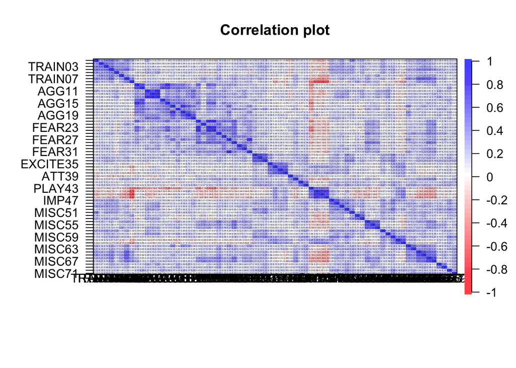

## Post-Imputation The post imputation polyserial correlation was also computed using the `lavcor` function, but with no setting for missing values since they were imputed and cor.smooth = TRUE to avoid having a non-positive-definite matrix to work on in future steps.

The minimum correlation was -0.6907752. The maximum correlation was 0.8839747.

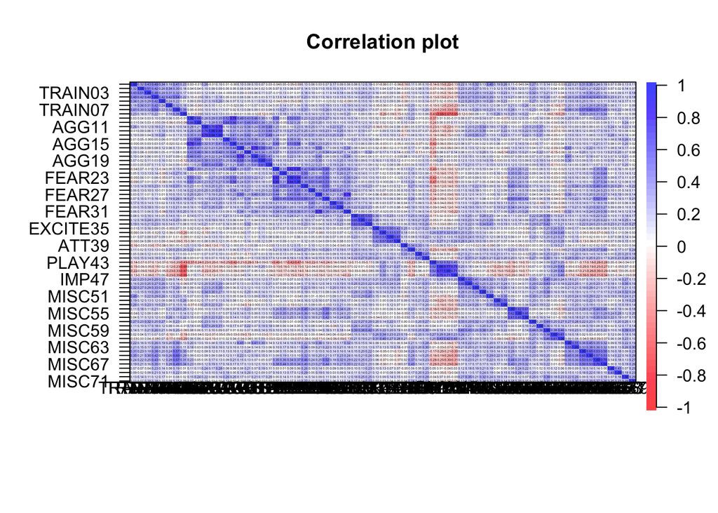

# 5 Estimating Number of Factors

## 5.1 Parallel method

From the EFAtools documentation:

> Various methods for performing parallel analysis. This function uses future_lapply for which a parallel processing plan can be selected. To do so, call library(future) and, for example, plan(multisession); see examples.

Settings Used:  
- n.obs = 1117 - eigen_type = “EFA” - fa = “fa” (factor analysis not PCA) - fm = “wls” (weighted least squares because pa gave errors and weighted recommended for ordinal data. - use = “all.obs” (since we have imputed missing values, we can use all data points) - cor = “poly” (use polychoric correlation matrix) - n.iter = 100 (run for 100 iterations)

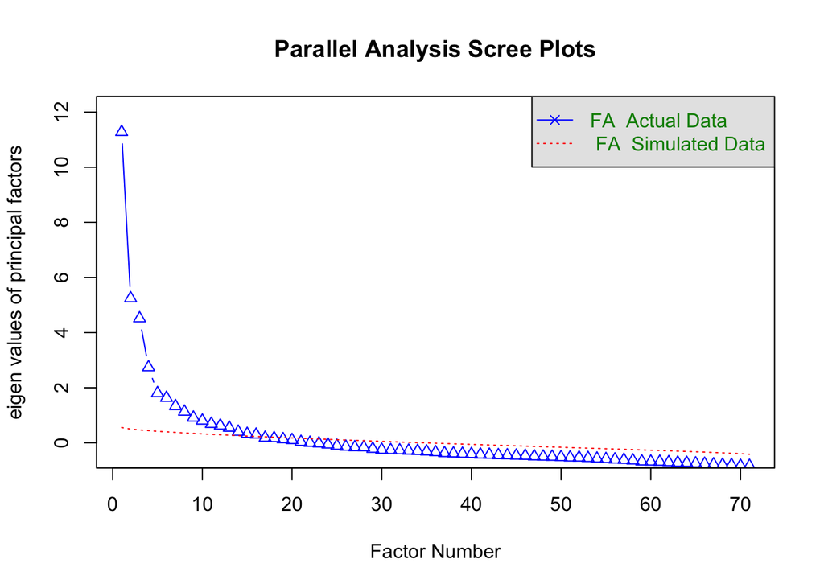

The suggested number of factors is 16.

## 5.2 Minimum Average Partial

MAP is recommended as a way to find the number of factors when the items are ordinal. The lowest value indicates the best number of factors.

[output not shown]

| Number of Factors | MAP value |
| --- | --- |
| 1 | 0.0239 |
| 2 | 0.0202 |
| 3 | 0.0156 |
| 4 | 0.0141 |
| 5 | 0.0134 |
| 6 | 0.0126 |
| 7 | 0.0121 |
| 8 | 0.0117 |
| 9 | 0.0117 |
| 10 | 0.0113 |
| 11 | 0.0113 |
| 12 | 0.0109 |
| 13 | 0.0108 |
| 14 | 0.0111 |
| 15 | 0.0112 |
| 16 | 0.0114 |
| 17 | 0.0118 |
| 18 | 0.0118 |

# 6 Factor Analyses

## 6.1 11 Factors

### 6.1.1 11 Factors Model Fit

Although the chi-square test of goodness of fit is sensitive to departures from normality like the C-BARQ items, Hopper et al (2008) recommend always reporting it.

- chi-square: 6.0450398^{4}
- degrees of freedom: 1759
- P-value for chi-square = 0

Tucker-Lewis Index of Factoring Reliability/Non-Norm Fit Index: 0.1300176. Should be > 0.9; need reference)

### 6.1.2 11 Factor Model Communalities

|  | fanal11.communality |
| --- | --- |
| TRAIN01 | 0.46 |
| TRAIN02 | 0.33 |
| TRAIN03 | 0.41 |
| TRAIN04 | 0.61 |
| TRAIN05 | 0.34 |
| TRAIN06 | 0.26 |
| TRAIN07 | 0.61 |
| TRAIN08 | 0.60 |
| AGG09 | 0.74 |
| AGG10 | 0.61 |
| AGG11 | 0.75 |
| AGG12 | 0.77 |
| AGG13 | 0.96 |
| AGG14 | 0.46 |
| AGG15 | 0.74 |
| AGG16 | 0.73 |
| AGG17 | 0.53 |
| AGG18 | 0.73 |
| AGG19 | 0.60 |
| AGG20 | 0.47 |
| FEAR21 | 0.79 |
| FEAR22 | 0.31 |
| FEAR23 | 0.75 |
| FEAR24 | 0.83 |
| FEAR25 | 0.46 |
| FEAR26 | 0.41 |
| FEAR27 | 0.54 |
| FEAR28 | 0.66 |
| FEAR29 | 0.27 |
| FEAR30 | 0.40 |
| FEAR31 | 0.50 |
| SEPR32 | 0.68 |
| SEPR33 | 0.54 |
| SEPR34 | 0.69 |
| EXCITE35 | 0.49 |
| EXCITE36 | 0.61 |
| EXCITE37 | 0.58 |
| EXCITE38 | 0.61 |
| ATT39 | 0.26 |
| ATT40 | 0.27 |
| ATT41 | 0.29 |
| ATT42 | 0.34 |
| PLAY43 | 0.55 |
| PLAY44 | 0.78 |
| PLAY45 | 0.72 |
| PLAY46 | 0.70 |
| IMP47 | 0.46 |
| IMP48 | 0.42 |
| IMP49 | 0.38 |
| MISC50 | 0.30 |
| MISC51 | 0.36 |
| MISC52 | 0.38 |
| MISC53 | 0.44 |
| MISC54 | 0.58 |
| MISC55 | 0.69 |
| MISC56 | 0.52 |
| MISC57 | 0.33 |
| MISC58 | 0.23 |
| MISC59 | 0.54 |
| MISC60 | 0.37 |
| MISC61 | 0.51 |
| MISC62 | 0.49 |
| MISC63 | 0.37 |
| MISC64 | 0.52 |
| MISC65 | 0.59 |
| MISC66 | 0.66 |
| MISC67 | 0.58 |
| MISC68 | 0.20 |
| MISC69 | 0.23 |
| MISC70 | 0.32 |
| MISC71 | 0.28 |

#### 6.1.2.1 How many communalities < 0.40?

There are 21 items with communality < 0.40.

|  | fanal11.communality | item |
| --- | --- | --- |
| TRAIN02 | 0.33 | TRAIN02 |
| TRAIN05 | 0.34 | TRAIN05 |
| TRAIN06 | 0.26 | TRAIN06 |
| FEAR22 | 0.31 | FEAR22 |
| FEAR29 | 0.27 | FEAR29 |
| ATT39 | 0.26 | ATT39 |
| ATT40 | 0.27 | ATT40 |
| ATT41 | 0.29 | ATT41 |
| ATT42 | 0.34 | ATT42 |
| IMP49 | 0.38 | IMP49 |
| MISC50 | 0.30 | MISC50 |
| MISC51 | 0.36 | MISC51 |
| MISC52 | 0.38 | MISC52 |
| MISC57 | 0.33 | MISC57 |
| MISC58 | 0.23 | MISC58 |
| MISC60 | 0.37 | MISC60 |
| MISC63 | 0.37 | MISC63 |
| MISC68 | 0.20 | MISC68 |
| MISC69 | 0.23 | MISC69 |
| MISC70 | 0.32 | MISC70 |
| MISC71 | 0.28 | MISC71 |

#### 6.1.2.2 How many communalities < 0.50?

There are 34 items with communality < 0.50.

|  | fanal11.communality | item |
| --- | --- | --- |
| TRAIN02 | 0.33 | TRAIN02 |
| TRAIN05 | 0.34 | TRAIN05 |
| TRAIN06 | 0.26 | TRAIN06 |
| FEAR22 | 0.31 | FEAR22 |
| FEAR29 | 0.27 | FEAR29 |
| ATT39 | 0.26 | ATT39 |
| ATT40 | 0.27 | ATT40 |
| ATT41 | 0.29 | ATT41 |
| ATT42 | 0.34 | ATT42 |
| IMP49 | 0.38 | IMP49 |
| MISC50 | 0.30 | MISC50 |
| MISC51 | 0.36 | MISC51 |
| MISC52 | 0.38 | MISC52 |
| MISC57 | 0.33 | MISC57 |
| MISC58 | 0.23 | MISC58 |
| MISC60 | 0.37 | MISC60 |
| MISC63 | 0.37 | MISC63 |
| MISC68 | 0.20 | MISC68 |
| MISC69 | 0.23 | MISC69 |
| MISC70 | 0.32 | MISC70 |
| MISC71 | 0.28 | MISC71 |

### 6.1.3 11 Factor Model Loadings

### 6.1.4 All loadings

|  | PA10 | PA2 | PA4 | PA8 | PA11 | PA6 | PA5 | PA1 | PA9 | PA7 | PA3 |
| --- | --- | --- | --- | --- | --- | --- | --- | --- | --- | --- | --- |
| TRAIN01 | -0.11 | -0.10 | -0.02 | 0.04 | 0.61 | 0.05 | -0.07 | 0.07 | -0.06 | 0.06 | 0.05 |
| TRAIN02 | 0.08 | -0.03 | -0.08 | 0.00 | 0.57 | 0.02 | 0.02 | -0.02 | 0.08 | -0.02 | -0.03 |
| TRAIN03 | -0.01 | -0.05 | -0.09 | 0.01 | 0.60 | 0.11 | -0.01 | -0.01 | 0.09 | 0.03 | -0.03 |
| TRAIN04 | 0.01 | -0.02 | 0.03 | -0.07 | 0.67 | 0.00 | 0.02 | 0.24 | 0.01 | -0.04 | 0.02 |
| TRAIN05 | -0.18 | 0.06 | 0.16 | 0.00 | 0.44 | -0.04 | -0.03 | 0.11 | 0.07 | 0.04 | 0.18 |
| TRAIN06 | -0.01 | -0.09 | -0.05 | 0.03 | 0.37 | 0.04 | 0.13 | 0.12 | -0.03 | -0.10 | -0.09 |
| TRAIN07 | 0.04 | -0.16 | 0.00 | 0.04 | 0.35 | 0.05 | -0.01 | 0.52 | -0.01 | -0.08 | -0.08 |
| TRAIN08 | 0.03 | -0.72 | 0.01 | -0.06 | 0.08 | 0.01 | 0.06 | 0.08 | 0.04 | 0.06 | -0.02 |
| AGG09 | 0.40 | 0.05 | 0.08 | 0.22 | 0.04 | -0.03 | 0.03 | 0.04 | -0.05 | -0.02 | 0.56 |
| AGG10 | 0.17 | 0.02 | 0.05 | 0.33 | 0.01 | 0.11 | -0.04 | -0.14 | -0.01 | -0.02 | 0.52 |
| AGG11 | -0.03 | -0.06 | 0.81 | 0.03 | 0.04 | 0.12 | -0.01 | -0.09 | -0.12 | 0.08 | 0.01 |
| AGG12 | 0.06 | -0.07 | 0.87 | -0.01 | -0.07 | -0.04 | 0.01 | 0.06 | 0.06 | -0.05 | -0.03 |
| AGG13 | 0.06 | -0.01 | 0.96 | 0.00 | 0.01 | -0.08 | 0.00 | 0.02 | 0.05 | 0.00 | 0.03 |
| AGG14 | 0.15 | -0.09 | -0.06 | 0.27 | -0.01 | 0.11 | 0.05 | -0.06 | 0.04 | 0.09 | 0.49 |
| AGG15 | 0.40 | -0.03 | 0.14 | 0.20 | 0.06 | 0.01 | -0.01 | -0.09 | -0.04 | -0.04 | 0.53 |
| AGG16 | -0.02 | -0.01 | 0.00 | 0.82 | 0.01 | -0.05 | 0.03 | 0.07 | 0.00 | -0.04 | 0.12 |
| AGG17 | 0.13 | 0.07 | 0.23 | 0.17 | 0.08 | 0.23 | 0.21 | -0.08 | 0.08 | -0.33 | 0.24 |
| AGG18 | -0.06 | 0.05 | 0.01 | 0.82 | -0.01 | 0.01 | -0.03 | 0.04 | -0.03 | 0.03 | 0.14 |
| AGG19 | -0.11 | 0.12 | 0.28 | 0.63 | -0.02 | 0.12 | 0.02 | 0.01 | 0.10 | -0.12 | -0.01 |
| AGG20 | -0.12 | 0.01 | 0.44 | 0.44 | -0.04 | 0.12 | 0.02 | -0.06 | 0.01 | 0.00 | -0.14 |
| FEAR21 | 0.85 | 0.01 | 0.08 | -0.05 | 0.00 | 0.03 | 0.03 | 0.01 | 0.01 | -0.02 | 0.07 |
| FEAR22 | 0.26 | -0.09 | 0.01 | 0.03 | -0.02 | 0.09 | 0.25 | 0.12 | 0.05 | -0.02 | -0.23 |
| FEAR23 | 0.79 | 0.01 | 0.01 | 0.00 | -0.03 | 0.02 | 0.07 | 0.06 | 0.00 | 0.00 | 0.15 |
| FEAR24 | 0.88 | -0.08 | 0.06 | -0.02 | -0.05 | -0.02 | -0.02 | 0.03 | 0.04 | 0.01 | 0.08 |
| FEAR25 | 0.28 | 0.02 | 0.12 | -0.01 | 0.05 | 0.02 | 0.37 | 0.21 | 0.02 | 0.04 | -0.07 |
| FEAR26 | 0.52 | 0.04 | 0.11 | 0.11 | 0.11 | 0.15 | 0.01 | -0.12 | -0.02 | 0.04 | -0.18 |
| FEAR27 | 0.37 | 0.00 | -0.02 | 0.49 | 0.01 | -0.10 | 0.12 | 0.00 | -0.03 | 0.17 | -0.20 |
| FEAR28 | 0.54 | 0.05 | 0.03 | -0.04 | 0.05 | 0.07 | 0.39 | 0.09 | 0.04 | -0.09 | -0.16 |
| FEAR29 | 0.24 | -0.04 | 0.06 | 0.15 | 0.20 | 0.17 | 0.05 | -0.17 | 0.01 | 0.04 | -0.25 |
| FEAR30 | 0.23 | 0.01 | 0.15 | 0.17 | 0.15 | 0.23 | 0.16 | -0.14 | -0.04 | 0.03 | -0.32 |
| FEAR31 | 0.34 | -0.04 | -0.07 | 0.41 | 0.05 | -0.06 | 0.15 | -0.02 | -0.02 | 0.18 | -0.31 |
| SEPR32 | 0.10 | -0.02 | -0.04 | 0.04 | -0.06 | 0.82 | -0.06 | 0.02 | 0.09 | -0.08 | -0.05 |
| SEPR33 | -0.02 | -0.02 | 0.02 | -0.01 | 0.03 | 0.71 | -0.01 | 0.04 | 0.03 | 0.02 | -0.07 |
| SEPR34 | -0.09 | -0.01 | -0.03 | -0.06 | 0.07 | 0.79 | 0.11 | -0.03 | -0.04 | 0.05 | 0.09 |
| EXCITE35 | 0.10 | -0.12 | -0.11 | 0.02 | -0.02 | 0.15 | -0.10 | 0.05 | 0.66 | 0.04 | 0.02 |
| EXCITE36 | 0.02 | 0.18 | 0.02 | -0.04 | 0.02 | -0.04 | 0.02 | 0.03 | 0.72 | -0.07 | 0.00 |
| EXCITE37 | -0.03 | -0.07 | 0.03 | 0.03 | 0.03 | 0.02 | -0.01 | -0.03 | 0.78 | -0.01 | 0.01 |
| EXCITE38 | -0.04 | 0.04 | 0.05 | 0.00 | 0.04 | -0.05 | 0.10 | -0.12 | 0.76 | 0.02 | -0.04 |
| ATT39 | 0.17 | -0.08 | -0.17 | 0.08 | -0.31 | 0.14 | -0.13 | 0.13 | 0.24 | 0.14 | 0.03 |
| ATT40 | 0.14 | -0.22 | -0.04 | 0.07 | -0.09 | 0.17 | 0.07 | 0.25 | 0.10 | 0.09 | -0.01 |
| ATT41 | 0.01 | -0.03 | 0.03 | 0.03 | -0.20 | 0.15 | -0.03 | 0.18 | 0.13 | 0.37 | -0.07 |
| ATT42 | 0.00 | -0.06 | 0.01 | 0.09 | -0.09 | 0.16 | 0.06 | 0.18 | 0.16 | 0.38 | -0.02 |
| PLAY43 | -0.31 | 0.52 | -0.03 | -0.05 | -0.07 | -0.10 | 0.05 | 0.04 | 0.07 | 0.09 | -0.23 |
| PLAY44 | 0.00 | 0.86 | -0.03 | 0.09 | 0.03 | 0.00 | -0.02 | 0.00 | 0.06 | -0.06 | -0.06 |
| PLAY45 | 0.07 | 0.81 | -0.11 | 0.03 | -0.06 | -0.05 | -0.04 | -0.03 | 0.01 | 0.04 | -0.01 |
| PLAY46 | -0.04 | 0.76 | -0.01 | -0.05 | 0.05 | 0.03 | 0.02 | -0.16 | 0.04 | -0.08 | 0.10 |
| IMP47 | 0.08 | 0.30 | 0.01 | 0.01 | 0.38 | 0.02 | 0.00 | -0.05 | 0.13 | 0.35 | 0.03 |
| IMP48 | 0.05 | 0.22 | 0.17 | 0.03 | 0.26 | 0.05 | 0.01 | 0.03 | 0.12 | 0.35 | -0.03 |
| IMP49 | 0.05 | 0.07 | 0.20 | -0.01 | 0.42 | -0.06 | -0.01 | 0.03 | 0.13 | 0.21 | 0.00 |
| MISC50 | -0.05 | 0.10 | 0.25 | -0.10 | 0.09 | 0.21 | 0.10 | 0.10 | 0.08 | 0.16 | 0.08 |
| MISC51 | -0.20 | -0.09 | 0.05 | 0.00 | 0.26 | 0.25 | 0.03 | 0.05 | 0.03 | 0.23 | 0.17 |
| MISC52 | 0.02 | -0.30 | 0.00 | 0.05 | 0.08 | -0.03 | 0.05 | -0.13 | 0.07 | 0.52 | -0.03 |
| MISC53 | -0.10 | -0.22 | 0.17 | -0.04 | 0.19 | 0.04 | -0.02 | -0.16 | 0.02 | 0.51 | -0.05 |
| MISC54 | 0.06 | -0.12 | -0.03 | 0.04 | 0.05 | 0.00 | 0.67 | 0.04 | 0.06 | 0.01 | -0.09 |
| MISC55 | -0.04 | 0.02 | -0.07 | 0.01 | -0.07 | 0.02 | 0.87 | -0.04 | 0.01 | -0.02 | 0.05 |
| MISC56 | -0.02 | -0.03 | 0.10 | -0.04 | 0.00 | -0.03 | 0.71 | 0.02 | -0.03 | 0.03 | 0.03 |
| MISC57 | -0.08 | 0.10 | 0.13 | -0.03 | 0.23 | 0.15 | -0.04 | 0.14 | 0.11 | 0.25 | 0.01 |
| MISC58 | -0.06 | 0.13 | 0.32 | -0.05 | 0.03 | 0.24 | 0.02 | 0.08 | -0.09 | 0.10 | 0.05 |
| MISC59 | 0.05 | 0.32 | 0.09 | -0.09 | 0.08 | 0.39 | -0.02 | 0.20 | 0.00 | 0.31 | 0.00 |
| MISC60 | 0.02 | 0.35 | -0.03 | -0.15 | -0.06 | 0.08 | -0.04 | 0.21 | 0.17 | 0.27 | 0.06 |
| MISC61 | 0.01 | 0.45 | 0.00 | -0.12 | -0.12 | 0.19 | -0.13 | 0.19 | 0.20 | 0.16 | 0.15 |
| MISC62 | 0.00 | 0.01 | -0.04 | 0.44 | 0.08 | -0.05 | 0.00 | 0.42 | 0.04 | 0.19 | -0.03 |
| MISC63 | 0.02 | 0.01 | 0.04 | 0.11 | 0.08 | -0.11 | 0.12 | 0.38 | 0.13 | 0.26 | 0.03 |
| MISC64 | -0.08 | -0.13 | 0.04 | 0.09 | 0.14 | 0.09 | 0.06 | 0.58 | -0.05 | -0.06 | 0.02 |
| MISC65 | -0.05 | -0.12 | -0.02 | 0.19 | 0.22 | 0.08 | 0.06 | 0.54 | -0.06 | 0.06 | -0.02 |
| MISC66 | 0.27 | -0.11 | -0.01 | -0.02 | 0.16 | 0.08 | 0.20 | 0.51 | -0.07 | -0.01 | -0.05 |
| MISC67 | 0.26 | -0.14 | 0.04 | 0.04 | 0.05 | 0.11 | 0.13 | 0.49 | -0.06 | 0.00 | -0.08 |
| MISC68 | -0.17 | 0.08 | 0.20 | -0.02 | 0.03 | 0.04 | 0.31 | 0.09 | 0.06 | 0.03 | 0.17 |
| MISC69 | -0.11 | -0.01 | 0.07 | 0.00 | -0.03 | 0.05 | 0.34 | 0.14 | 0.05 | 0.16 | 0.19 |
| MISC70 | -0.03 | 0.09 | 0.05 | 0.10 | 0.01 | 0.16 | 0.08 | 0.03 | 0.00 | 0.41 | 0.19 |
| MISC71 | -0.02 | 0.03 | -0.03 | -0.08 | -0.03 | 0.12 | 0.26 | 0.19 | -0.06 | 0.32 | 0.10 |

### 6.1.5 11 Factor Model Largest Loading Per Item

Largest Loading Per Item and Associated Factors, Sorted by Factor

|  | largest | maximum | itemNames | itemDescriptions |
| --- | --- | --- | --- | --- |
| 14 | PA1 | 0.25 | ATT40 | Unwilling to leave your side, even when working, reluctant to work at a distance from you/the handler |
| 48 | PA1 | 0.38 | MISC63 | Becomes highly excited and/or distracted when encountering unfamiliar people |
| 49 | PA1 | 0.58 | MISC64 | When working, is easily distracted or preoccupied by odors/engages in persistent sniffing of ground or objects |
| 50 | PA1 | 0.54 | MISC65 | Has difficulty shifting attention away from interesting or distracting stimuli (e.g., other dogs, odor, people, small animals, etc.) |
| 51 | PA1 | 0.51 | MISC66 | Is distracted or nervous in new, unfamiliar environments, has difficulty maintaining focus on work |
| 52 | PA1 | 0.49 | MISC67 | Is slow to recover after being distracted, startled, or frightened/takes a long time to resume work |
| 70 | PA1 | 0.52 | TRAIN07 | Unfocused; is easily distracted by interesting sights, sounds or smells |
| 21 | PA10 | 0.85 | FEAR21 | When an unfamiliar person approaches the dog when s/he is away from his/her normal home environment or kennel |
| 22 | PA10 | 0.26 | FEAR22 | In response to sudden or loud noises (e.g., gun fire, car backfire, road drills, objects being dropped, etc.) |
| 23 | PA10 | 0.79 | FEAR23 | When an unfamiliar person visits your home or approaches the dog when in his/her home kennel |
| 24 | PA10 | 0.88 | FEAR24 | When an unfamiliar person tries to touch or pet the dog |
| 26 | PA10 | 0.52 | FEAR26 | When examined/treated by a veterinarian |
| 28 | PA10 | 0.54 | FEAR28 | When first exposed to unfamiliar situations (e.g., novel environments, first visit to the veterinarian, etc.) |
| 29 | PA10 | 0.24 | FEAR29 | When having nails trimmed, or feet touched/handled |
| 32 | PA11 | 0.38 | IMP47 | Impulsive; doesn’t seem to think before s/he acts |
| 34 | PA11 | 0.42 | IMP49 | Is difficult to interrupt or distract when doing things s/he wants to do |
| 36 | PA11 | 0.26 | MISC51 | Escapes or would escape from home, yard or kennel given the chance |
| 64 | PA11 | 0.61 | TRAIN01 | Is hard to recall when off the leash |
| 65 | PA11 | 0.57 | TRAIN02 | Is slow to obey a ‘sit’ command |
| 66 | PA11 | 0.60 | TRAIN03 | Is slow to obey a ‘stay’ command |
| 67 | PA11 | 0.67 | TRAIN04 | Has difficulty attending/listening to things you say or do |
| 68 | PA11 | 0.44 | TRAIN05 | Is slow to respond to corrections or reprimands: thick-skinned |
| 69 | PA11 | 0.37 | TRAIN06 | Is slow to learn new tricks or tasks |
| 71 | PA11 | 0.08 | TRAIN08 | Is uninterested in ‘fetching’ or attempting to fetch sticks, toys, balls, or objects |
| 45 | PA2 | 0.35 | MISC60 | Playful, puppyish, boisterous |
| 46 | PA2 | 0.45 | MISC61 | Active, energetic, always on the go |
| 57 | PA2 | 0.52 | PLAY43 | Eagerly engages in play with new/unfamiliar people |
| 58 | PA2 | 0.86 | PLAY44 | Highly toy focused; attention riveted on tug toy/balls when these are held by handler or other person |
| 59 | PA2 | 0.81 | PLAY45 | Eagerly initiates play sessions; brings objects/toys to you/the handler and retrieves them when thrown |
| 60 | PA2 | 0.76 | PLAY46 | Hunts persistently for thrown or hidden toys/objects, not easily distracted from this task |
| 1 | PA3 | 0.56 | AGG09 | Barks, growls, attempts to bite when approached directly by an unfamiliar person while being walked/exercised on a leash |
| 2 | PA3 | 0.52 | AGG10 | Barks, etc. when unfamiliar persons approach the dog when s/he is in his/her kennel |
| 6 | PA3 | 0.49 | AGG14 | When strangers walk past when the dog is in his/her home run or kennel |
| 7 | PA3 | 0.53 | AGG15 | When an unfamiliar person tries to touch or pet the dog |
| 9 | PA3 | 0.24 | AGG17 | When stared at directly by you or another familiar person |
| 3 | PA4 | 0.81 | AGG11 | Barks, etc. when toys, bones or other objects are taken away by you or another familiar person |
| 4 | PA4 | 0.87 | AGG12 | When you or another familiar person approaches the dog directly while s/he is eating |
| 5 | PA4 | 0.96 | AGG13 | When his/her food is taken away by you or another familiar person |
| 35 | PA4 | 0.25 | MISC50 | NA |
| 43 | PA4 | 0.32 | MISC58 | Urinates against objects/furnishings indoors |
| 25 | PA5 | 0.37 | FEAR25 | In response to strange or unfamiliar objects on or near sidewalks or walkways (e.g., plastic trash bags, leaves, litter, flags flapping, etc. |
| 39 | PA5 | 0.67 | MISC54 | Reluctant to/nervous about crossing grates or other unfamiliar surfaces |
| 40 | PA5 | 0.87 | MISC55 | Reluctant to/nervous about crossing shiny or slippery floors |
| 41 | PA5 | 0.71 | MISC56 | Nervous or frightened when ascending or descending some types of stairs |
| 53 | PA5 | 0.31 | MISC68 | Chases own tail/hind end |
| 54 | PA5 | 0.34 | MISC69 | Chases/follows shadows, light spots, etc. |
| 30 | PA6 | 0.23 | FEAR30 | When groomed or bathed |
| 44 | PA6 | 0.39 | MISC59 | Hyperactive, restless, has trouble settling down |
| 61 | PA6 | 0.82 | SEPR32 | Restlessness/agitation/pacing when left alone |
| 62 | PA6 | 0.71 | SEPR33 | Barking or whining when left alone |
| 63 | PA6 | 0.79 | SEPR34 | Chewing/scratching at doors, floor, fencing, etc., when left alone |
| 15 | PA7 | 0.37 | ATT41 | Tends to nudge or paw you (or others) for attention |
| 16 | PA7 | 0.38 | ATT42 | Becomes agitated (whines, jumps up, tries to intervene) when attention is given to another person or animal |
| 33 | PA7 | 0.35 | IMP48 | Becomes frustrated/impatient in a wide range of situations |
| 37 | PA7 | 0.52 | MISC52 | Begs persistently for food when people are eating |
| 38 | PA7 | 0.51 | MISC53 | Steals food |
| 42 | PA7 | 0.25 | MISC57 | Pulls excessively hard when on leash |
| 55 | PA7 | 0.41 | MISC70 | Barks persistently when alarmed or excited |
| 56 | PA7 | 0.32 | MISC71 | Licks people or objects excessively |
| 8 | PA8 | 0.82 | AGG16 | When approached directly by an unfamiliar dog while being walked/exercised on a leash |
| 10 | PA8 | 0.82 | AGG18 | When barked, growled, or lunged at by another dog |
| 11 | PA8 | 0.63 | AGG19 | Towards other familiar dogs |
| 12 | PA8 | 0.44 | AGG20 | When approached while playing with/chewing a favorite toy, bone, object, etc. by another familiar dog |
| 27 | PA8 | 0.49 | FEAR27 | When approached directly by an unfamiliar dog |
| 31 | PA8 | 0.41 | FEAR31 | When barked, growled, or lunged at by an unfamiliar dog |
| 47 | PA8 | 0.44 | MISC62 | Becomes highly excited and/or distracted when encountering unfamiliar dogs |
| 13 | PA9 | 0.24 | ATT39 | Displays a strong attachment for you or another familiar person |
| 17 | PA9 | 0.66 | EXCITE35 | Excitable when you first arrive home, or at the dog’s kennel, after a brief absence |
| 18 | PA9 | 0.72 | EXCITE36 | Excitable when playing with you or other familiar persons |
| 19 | PA9 | 0.78 | EXCITE37 | Excitable just before being taken out for a walk |
| 20 | PA9 | 0.76 | EXCITE38 | Excitable just before being taken out for work or training |

#### 6.1.5.1 Items with Loadings < 0.32

These are probably too low to include

|  | fnum | itemNames | largest | itemDescriptions | maximum |
| --- | --- | --- | --- | --- | --- |
| 71 | 08 | TRAIN08 | PA11 | Is uninterested in ‘fetching’ or attempting to fetch sticks, toys, balls, or objects | 0.08 |
| 9 | 17 | AGG17 | PA3 | When stared at directly by you or another familiar person | 0.24 |
| 22 | 22 | FEAR22 | PA10 | In response to sudden or loud noises (e.g., gun fire, car backfire, road drills, objects being dropped, etc.) | 0.26 |
| 29 | 29 | FEAR29 | PA10 | When having nails trimmed, or feet touched/handled | 0.24 |
| 30 | 30 | FEAR30 | PA6 | When groomed or bathed | 0.23 |
| 13 | 39 | ATT39 | PA9 | Displays a strong attachment for you or another familiar person | 0.24 |
| 14 | 40 | ATT40 | PA1 | Unwilling to leave your side, even when working, reluctant to work at a distance from you/the handler | 0.25 |
| 35 | 50 | MISC50 | PA4 | NA | 0.25 |
| 36 | 51 | MISC51 | PA11 | Escapes or would escape from home, yard or kennel given the chance | 0.26 |
| 42 | 57 | MISC57 | PA7 | Pulls excessively hard when on leash | 0.25 |
| 53 | 68 | MISC68 | PA5 | Chases own tail/hind end | 0.31 |

### 6.1.6 11 Model Reliability

|  | alpha | fnum | factor |
| --- | --- | --- | --- |
| PA1 | 0.77 | 01 | F01 |
| PA2 | 0.82 | 02 | F02 |
| PA3 | 0.52 | 03 | F03 |
| PA4 | 0.48 | 04 | F04 |
| PA5 | 0.63 | 05 | F05 |
| PA6 | 0.72 | 06 | F06 |
| PA7 | 0.65 | 07 | F07 |
| PA8 | 0.77 | 08 | F08 |
| PA9 | 0.79 | 09 | F09 |
| PA10 | 0.76 | 10 | F10 |
| PA11 | 0.70 | 11 | F11 |

```
## Measures of reliability
## reliability(keys = keysList11, items = imputedNumericDF)
##      omega_h alpha omega.tot  Uni r.fit fa.fit max.split min.split mean.r med.r
## PA10    0.56  0.80      0.86 0.82  0.83   0.98      0.83      0.67   0.40  0.37
## PA2     0.37  0.82      0.87 0.82  0.86   0.95      0.85      0.70   0.39  0.36
## PA4     0.48  0.64      0.73 0.59  0.60   0.98      0.73      0.57   0.26  0.16
## PA8     0.50  0.78      0.83 0.73  0.82   0.89      0.86      0.65   0.33  0.33
## PA11    0.50  0.72      0.74 0.70  0.75   0.93      0.78      0.62   0.20  0.21
## PA6     0.25  0.73      0.75 0.94  0.95   1.00      0.74      0.71   0.40  0.39
## PA5     0.29  0.62      0.68 0.65  0.69   0.94      0.69      0.41   0.21  0.16
## PA1     0.68  0.78      0.81 0.87  0.88   0.98      0.81      0.71   0.34  0.31
## PA9     0.62  0.79      0.83 0.97  0.98   0.99      0.83      0.75   0.48  0.47
## PA7     0.39  0.63      0.67 0.61  0.68   0.89      0.69      0.48   0.16  0.17
## PA3     0.19  0.69      0.79 0.56  0.65   0.86      0.81      0.52   0.27  0.12
##      n.items
## PA10       6
## PA2        7
## PA4        5
## PA8        7
## PA11      10
## PA6        4
## PA5        6
## PA1        7
## PA9        4
## PA7        9
## PA3        6
```

## 6.2 12 Factors

### 6.2.1 12 Factors Model Fit

Although the chi-square test of goodness of fit is sensitive to departures from normality like the C-BARQ items, Hopper et al (2008) recommend always reporting it.

- chi-square: 5.923146^{4}
- degrees of freedom: 1699
- P-value for chi-square = 0

Tucker-Lewis Index of Factoring Reliability/Non-Norm Fit Index: 0.1165225. Should be > 0.9; need reference)

### 6.2.2 12 Factor Model Communalities

|  | fanal12.communality |
| --- | --- |
| TRAIN01 | 0.46 |
| TRAIN02 | 0.33 |
| TRAIN03 | 0.41 |
| TRAIN04 | 0.63 |
| TRAIN05 | 0.34 |
| TRAIN06 | 0.26 |
| TRAIN07 | 0.60 |
| TRAIN08 | 0.60 |
| AGG09 | 0.75 |
| AGG10 | 0.66 |
| AGG11 | 0.76 |
| AGG12 | 0.77 |
| AGG13 | 0.97 |
| AGG14 | 0.48 |
| AGG15 | 0.77 |
| AGG16 | 0.75 |
| AGG17 | 0.54 |
| AGG18 | 0.73 |
| AGG19 | 0.60 |
| AGG20 | 0.46 |
| FEAR21 | 0.81 |
| FEAR22 | 0.31 |
| FEAR23 | 0.80 |
| FEAR24 | 0.86 |
| FEAR25 | 0.46 |
| FEAR26 | 0.42 |
| FEAR27 | 0.67 |
| FEAR28 | 0.66 |
| FEAR29 | 0.39 |
| FEAR30 | 0.53 |
| FEAR31 | 0.56 |
| SEPR32 | 0.68 |
| SEPR33 | 0.53 |
| SEPR34 | 0.71 |
| EXCITE35 | 0.50 |
| EXCITE36 | 0.63 |
| EXCITE37 | 0.58 |
| EXCITE38 | 0.61 |
| ATT39 | 0.28 |
| ATT40 | 0.29 |
| ATT41 | 0.29 |
| ATT42 | 0.34 |
| PLAY43 | 0.55 |
| PLAY44 | 0.79 |
| PLAY45 | 0.75 |
| PLAY46 | 0.70 |
| IMP47 | 0.45 |
| IMP48 | 0.41 |
| IMP49 | 0.38 |
| MISC50 | 0.32 |
| MISC51 | 0.36 |
| MISC52 | 0.46 |
| MISC53 | 0.46 |
| MISC54 | 0.61 |
| MISC55 | 0.69 |
| MISC56 | 0.52 |
| MISC57 | 0.33 |
| MISC58 | 0.23 |
| MISC59 | 0.54 |
| MISC60 | 0.37 |
| MISC61 | 0.51 |
| MISC62 | 0.49 |
| MISC63 | 0.38 |
| MISC64 | 0.55 |
| MISC65 | 0.61 |
| MISC66 | 0.68 |
| MISC67 | 0.60 |
| MISC68 | 0.24 |
| MISC69 | 0.30 |
| MISC70 | 0.32 |
| MISC71 | 0.28 |

#### 6.2.2.1 How many communalities < 0.40?

There are 20 items with communality < 0.40.

|  | fanal12.communality | item |
| --- | --- | --- |
| TRAIN02 | 0.33 | TRAIN02 |
| TRAIN05 | 0.34 | TRAIN05 |
| TRAIN06 | 0.26 | TRAIN06 |
| FEAR22 | 0.31 | FEAR22 |
| FEAR29 | 0.39 | FEAR29 |
| ATT39 | 0.28 | ATT39 |
| ATT40 | 0.29 | ATT40 |
| ATT41 | 0.29 | ATT41 |
| ATT42 | 0.34 | ATT42 |
| IMP49 | 0.38 | IMP49 |
| MISC50 | 0.32 | MISC50 |
| MISC51 | 0.36 | MISC51 |
| MISC57 | 0.33 | MISC57 |
| MISC58 | 0.23 | MISC58 |
| MISC60 | 0.37 | MISC60 |
| MISC63 | 0.38 | MISC63 |
| MISC68 | 0.24 | MISC68 |
| MISC69 | 0.30 | MISC69 |
| MISC70 | 0.32 | MISC70 |
| MISC71 | 0.28 | MISC71 |

#### 6.2.2.2 How many communalities < 0.50?

There are 32 items with communality < 0.50.

|  | fanal12.communality | item |
| --- | --- | --- |
| TRAIN02 | 0.33 | TRAIN02 |
| TRAIN05 | 0.34 | TRAIN05 |
| TRAIN06 | 0.26 | TRAIN06 |
| FEAR22 | 0.31 | FEAR22 |
| FEAR29 | 0.39 | FEAR29 |
| ATT39 | 0.28 | ATT39 |
| ATT40 | 0.29 | ATT40 |
| ATT41 | 0.29 | ATT41 |
| ATT42 | 0.34 | ATT42 |
| IMP49 | 0.38 | IMP49 |
| MISC50 | 0.32 | MISC50 |
| MISC51 | 0.36 | MISC51 |
| MISC57 | 0.33 | MISC57 |
| MISC58 | 0.23 | MISC58 |
| MISC60 | 0.37 | MISC60 |
| MISC63 | 0.38 | MISC63 |
| MISC68 | 0.24 | MISC68 |
| MISC69 | 0.30 | MISC69 |
| MISC70 | 0.32 | MISC70 |
| MISC71 | 0.28 | MISC71 |

### 6.2.3 12 Factor Model Loadings

### 6.2.4 All loadings

|  | PA2 | PA12 | PA1 | PA4 | PA11 | PA6 | PA5 | PA8 | PA3 | PA9 | PA7 | PA10 |
| --- | --- | --- | --- | --- | --- | --- | --- | --- | --- | --- | --- | --- |
| TRAIN01 | -0.10 | -0.12 | 0.10 | -0.03 | 0.58 | 0.04 | -0.08 | 0.02 | 0.07 | -0.06 | 0.07 | 0.05 |
| TRAIN02 | -0.03 | 0.04 | 0.03 | -0.09 | 0.54 | 0.01 | 0.01 | -0.01 | 0.02 | 0.09 | 0.00 | 0.14 |
| TRAIN03 | -0.05 | -0.03 | 0.03 | -0.10 | 0.57 | 0.11 | -0.02 | 0.00 | 0.01 | 0.10 | 0.04 | 0.10 |
| TRAIN04 | -0.05 | 0.07 | 0.20 | 0.02 | 0.69 | 0.02 | 0.01 | -0.01 | -0.06 | 0.01 | -0.07 | -0.06 |
| TRAIN05 | 0.04 | -0.12 | 0.07 | 0.15 | 0.46 | -0.02 | -0.03 | 0.01 | 0.11 | 0.07 | 0.02 | -0.13 |
| TRAIN06 | -0.11 | 0.01 | 0.13 | -0.06 | 0.36 | 0.05 | 0.12 | 0.06 | -0.10 | -0.02 | -0.11 | 0.05 |
| TRAIN07 | -0.15 | 0.03 | 0.56 | 0.00 | 0.32 | 0.04 | -0.03 | 0.04 | -0.09 | 0.00 | -0.09 | 0.01 |
| TRAIN08 | -0.71 | 0.04 | 0.10 | 0.01 | 0.08 | 0.01 | 0.05 | -0.04 | -0.04 | 0.04 | 0.07 | 0.01 |
| AGG09 | 0.07 | 0.28 | 0.09 | 0.06 | 0.03 | -0.05 | 0.04 | 0.09 | 0.68 | -0.05 | 0.00 | -0.06 |
| AGG10 | 0.05 | 0.01 | -0.04 | 0.03 | -0.03 | 0.06 | -0.03 | 0.15 | 0.73 | 0.00 | 0.03 | 0.05 |
| AGG11 | -0.07 | 0.00 | -0.12 | 0.81 | 0.07 | 0.13 | -0.01 | 0.05 | 0.00 | -0.12 | 0.07 | 0.00 |
| AGG12 | -0.08 | 0.08 | 0.05 | 0.87 | -0.06 | -0.03 | 0.01 | 0.01 | -0.04 | 0.06 | -0.05 | -0.01 |
| AGG13 | 0.01 | 0.03 | 0.04 | 0.96 | 0.00 | -0.10 | 0.00 | -0.03 | 0.08 | 0.05 | 0.02 | 0.05 |
| AGG14 | -0.06 | 0.04 | 0.00 | -0.08 | -0.04 | 0.08 | 0.06 | 0.14 | 0.62 | 0.05 | 0.12 | -0.03 |
| AGG15 | 0.00 | 0.26 | -0.01 | 0.12 | 0.03 | -0.04 | 0.00 | 0.05 | 0.71 | -0.04 | 0.00 | 0.03 |
| AGG16 | -0.03 | -0.03 | 0.07 | 0.01 | 0.02 | -0.04 | 0.02 | 0.77 | 0.22 | 0.01 | -0.07 | -0.02 |
| AGG17 | 0.07 | 0.03 | -0.02 | 0.21 | 0.05 | 0.19 | 0.21 | 0.06 | 0.39 | 0.09 | -0.29 | 0.12 |
| AGG18 | 0.04 | -0.07 | 0.05 | 0.02 | -0.01 | 0.02 | -0.04 | 0.76 | 0.25 | -0.02 | 0.00 | -0.01 |
| AGG19 | 0.10 | -0.11 | 0.01 | 0.29 | -0.02 | 0.12 | 0.01 | 0.59 | 0.08 | 0.11 | -0.15 | 0.05 |
| AGG20 | 0.01 | -0.15 | -0.01 | 0.44 | -0.06 | 0.11 | 0.01 | 0.39 | -0.03 | 0.01 | 0.00 | 0.14 |
| FEAR21 | -0.01 | 0.81 | 0.01 | 0.08 | 0.01 | 0.04 | 0.03 | -0.03 | 0.13 | 0.01 | -0.04 | 0.06 |
| FEAR22 | -0.07 | 0.21 | 0.19 | 0.02 | -0.05 | 0.06 | 0.24 | 0.02 | -0.15 | 0.06 | -0.02 | 0.16 |
| FEAR23 | -0.02 | 0.81 | 0.01 | 0.01 | 0.00 | 0.04 | 0.06 | 0.03 | 0.15 | 0.00 | -0.04 | -0.05 |
| FEAR24 | -0.10 | 0.85 | 0.02 | 0.06 | -0.04 | -0.01 | -0.02 | 0.00 | 0.13 | 0.04 | -0.01 | 0.03 |
| FEAR25 | 0.01 | 0.29 | 0.21 | 0.12 | 0.06 | 0.03 | 0.36 | 0.02 | -0.09 | 0.03 | 0.02 | -0.01 |
| FEAR26 | 0.08 | 0.36 | 0.02 | 0.11 | 0.03 | 0.10 | 0.00 | 0.03 | 0.05 | -0.01 | 0.08 | 0.37 |
| FEAR27 | -0.02 | 0.44 | -0.07 | -0.02 | 0.04 | -0.06 | 0.10 | 0.59 | -0.20 | -0.04 | 0.13 | 0.04 |
| FEAR28 | 0.07 | 0.45 | 0.17 | 0.03 | 0.00 | 0.05 | 0.37 | -0.05 | -0.05 | 0.05 | -0.08 | 0.21 |
| FEAR29 | 0.04 | 0.02 | 0.04 | 0.06 | 0.08 | 0.10 | 0.03 | 0.01 | 0.05 | 0.02 | 0.12 | 0.54 |
| FEAR30 | 0.10 | 0.00 | 0.08 | 0.15 | 0.03 | 0.16 | 0.14 | 0.04 | -0.02 | -0.03 | 0.11 | 0.57 |
| FEAR31 | -0.05 | 0.37 | -0.04 | -0.07 | 0.06 | -0.02 | 0.13 | 0.49 | -0.26 | -0.02 | 0.15 | 0.14 |
| SEPR32 | -0.03 | 0.09 | 0.04 | -0.04 | -0.07 | 0.81 | -0.07 | 0.03 | 0.00 | 0.09 | -0.10 | 0.09 |
| SEPR33 | -0.02 | -0.02 | 0.06 | 0.02 | 0.02 | 0.70 | -0.01 | -0.01 | -0.05 | 0.03 | 0.01 | 0.07 |
| SEPR34 | -0.03 | -0.04 | -0.06 | -0.04 | 0.09 | 0.82 | 0.11 | -0.03 | 0.06 | -0.04 | 0.03 | -0.03 |
| EXCITE35 | -0.12 | 0.11 | 0.03 | -0.11 | -0.01 | 0.16 | -0.10 | 0.03 | 0.00 | 0.65 | 0.03 | -0.04 |
| EXCITE36 | 0.20 | -0.02 | 0.05 | 0.02 | 0.00 | -0.06 | 0.02 | -0.08 | 0.03 | 0.73 | -0.06 | 0.03 |
| EXCITE37 | -0.07 | -0.01 | -0.05 | 0.03 | 0.04 | 0.02 | -0.01 | 0.04 | -0.01 | 0.77 | 0.00 | -0.02 |
| EXCITE38 | 0.04 | -0.03 | -0.14 | 0.05 | 0.05 | -0.04 | 0.10 | 0.01 | -0.05 | 0.75 | 0.02 | 0.01 |
| ATT39 | -0.03 | 0.10 | 0.20 | -0.16 | -0.35 | 0.11 | -0.13 | 0.01 | 0.10 | 0.24 | 0.16 | 0.03 |
| ATT40 | -0.17 | 0.06 | 0.34 | -0.04 | -0.15 | 0.14 | 0.06 | 0.01 | 0.07 | 0.10 | 0.11 | 0.08 |
| ATT41 | 0.01 | 0.00 | 0.22 | 0.04 | -0.22 | 0.15 | -0.04 | 0.02 | -0.07 | 0.13 | 0.36 | -0.03 |
| ATT42 | -0.04 | 0.02 | 0.18 | 0.02 | -0.08 | 0.17 | 0.05 | 0.11 | -0.05 | 0.16 | 0.35 | -0.08 |
| PLAY43 | 0.52 | -0.25 | -0.01 | -0.03 | -0.05 | -0.08 | 0.05 | 0.00 | -0.31 | 0.07 | 0.07 | -0.04 |
| PLAY44 | 0.86 | -0.03 | 0.00 | -0.02 | 0.02 | -0.01 | -0.02 | 0.07 | -0.03 | 0.06 | -0.07 | 0.04 |
| PLAY45 | 0.83 | 0.02 | -0.01 | -0.10 | -0.08 | -0.07 | -0.04 | -0.01 | 0.03 | 0.01 | 0.04 | 0.03 |
| PLAY46 | 0.75 | -0.06 | -0.18 | -0.01 | 0.06 | 0.03 | 0.03 | -0.07 | 0.12 | 0.04 | -0.08 | -0.01 |
| IMP47 | 0.30 | 0.09 | -0.05 | 0.01 | 0.38 | 0.05 | 0.00 | 0.03 | 0.02 | 0.13 | 0.32 | 0.00 |
| IMP48 | 0.24 | 0.04 | 0.06 | 0.17 | 0.25 | 0.06 | 0.01 | 0.03 | -0.02 | 0.12 | 0.33 | 0.02 |
| IMP49 | 0.07 | 0.05 | 0.04 | 0.19 | 0.42 | -0.05 | -0.02 | 0.01 | 0.00 | 0.13 | 0.20 | 0.03 |
| MISC50 | 0.07 | 0.04 | 0.02 | 0.25 | 0.15 | 0.26 | 0.10 | -0.03 | -0.05 | 0.07 | 0.11 | -0.18 |
| MISC51 | -0.10 | -0.13 | 0.00 | 0.04 | 0.29 | 0.29 | 0.03 | 0.03 | 0.09 | 0.03 | 0.20 | -0.14 |
| MISC52 | -0.22 | -0.10 | 0.01 | 0.00 | 0.01 | -0.08 | 0.05 | -0.04 | 0.12 | 0.07 | 0.60 | 0.20 |
| MISC53 | -0.17 | -0.14 | -0.09 | 0.17 | 0.16 | 0.03 | -0.02 | -0.07 | 0.01 | 0.02 | 0.55 | 0.11 |
| MISC54 | -0.08 | -0.03 | 0.15 | -0.03 | 0.00 | -0.03 | 0.66 | -0.02 | 0.02 | 0.06 | 0.04 | 0.17 |
| MISC55 | 0.01 | -0.01 | -0.04 | -0.07 | -0.05 | 0.03 | 0.86 | 0.02 | 0.03 | 0.01 | -0.03 | -0.03 |
| MISC56 | -0.03 | -0.02 | 0.03 | 0.10 | 0.01 | -0.03 | 0.69 | -0.03 | 0.01 | -0.04 | 0.02 | -0.01 |
| MISC57 | 0.10 | -0.02 | 0.10 | 0.13 | 0.24 | 0.17 | -0.04 | 0.01 | -0.07 | 0.10 | 0.22 | -0.10 |
| MISC58 | 0.11 | 0.00 | 0.04 | 0.32 | 0.05 | 0.26 | 0.01 | -0.02 | -0.01 | -0.10 | 0.07 | -0.10 |
| MISC59 | 0.32 | 0.09 | 0.18 | 0.09 | 0.10 | 0.41 | -0.03 | -0.05 | -0.07 | -0.01 | 0.26 | -0.10 |
| MISC60 | 0.35 | 0.09 | 0.15 | -0.03 | -0.03 | 0.12 | -0.05 | -0.09 | -0.07 | 0.16 | 0.23 | -0.19 |
| MISC61 | 0.44 | 0.08 | 0.10 | 0.01 | -0.07 | 0.22 | -0.13 | -0.07 | 0.02 | 0.19 | 0.11 | -0.24 |
| MISC62 | 0.03 | 0.00 | 0.44 | -0.03 | 0.07 | -0.05 | -0.02 | 0.42 | -0.01 | 0.04 | 0.15 | -0.05 |
| MISC63 | 0.05 | 0.00 | 0.42 | 0.05 | 0.06 | -0.12 | 0.10 | 0.09 | 0.02 | 0.13 | 0.25 | -0.06 |
| MISC64 | -0.08 | -0.14 | 0.68 | 0.04 | 0.08 | 0.04 | 0.04 | 0.02 | 0.06 | -0.05 | -0.05 | 0.00 |
| MISC65 | -0.07 | -0.11 | 0.63 | -0.02 | 0.16 | 0.05 | 0.04 | 0.13 | 0.02 | -0.06 | 0.06 | 0.02 |
| MISC66 | -0.06 | 0.19 | 0.61 | -0.01 | 0.10 | 0.04 | 0.18 | -0.07 | 0.01 | -0.06 | 0.00 | 0.07 |
| MISC67 | -0.09 | 0.18 | 0.61 | 0.04 | -0.01 | 0.06 | 0.11 | -0.02 | 0.00 | -0.06 | 0.01 | 0.08 |
| MISC68 | 0.03 | -0.04 | -0.03 | 0.19 | 0.11 | 0.09 | 0.32 | 0.06 | 0.01 | 0.05 | -0.01 | -0.26 |
| MISC69 | -0.07 | 0.05 | -0.01 | 0.06 | 0.06 | 0.12 | 0.35 | 0.10 | 0.00 | 0.04 | 0.10 | -0.34 |
| MISC70 | 0.10 | -0.02 | 0.03 | 0.05 | 0.02 | 0.18 | 0.08 | 0.09 | 0.17 | 0.00 | 0.38 | -0.12 |
| MISC71 | 0.05 | 0.01 | 0.18 | -0.03 | -0.01 | 0.14 | 0.25 | -0.05 | 0.02 | -0.07 | 0.30 | -0.14 |

### 6.2.5 12 Factor Model Largest Loading Per Item

Largest Loading Per Item and Associated Factors, Sorted by Factor

|  | largest | maximum | itemNames | itemDescriptions |
| --- | --- | --- | --- | --- |
| 14 | PA1 | 0.34 | ATT40 | Unwilling to leave your side, even when working, reluctant to work at a distance from you/the handler |
| 47 | PA1 | 0.44 | MISC62 | Becomes highly excited and/or distracted when encountering unfamiliar dogs |
| 48 | PA1 | 0.42 | MISC63 | Becomes highly excited and/or distracted when encountering unfamiliar people |
| 49 | PA1 | 0.68 | MISC64 | When working, is easily distracted or preoccupied by odors/engages in persistent sniffing of ground or objects |
| 50 | PA1 | 0.63 | MISC65 | Has difficulty shifting attention away from interesting or distracting stimuli (e.g., other dogs, odor, people, small animals, etc.) |
| 51 | PA1 | 0.61 | MISC66 | Is distracted or nervous in new, unfamiliar environments, has difficulty maintaining focus on work |
| 52 | PA1 | 0.61 | MISC67 | Is slow to recover after being distracted, startled, or frightened/takes a long time to resume work |
| 70 | PA1 | 0.56 | TRAIN07 | Unfocused; is easily distracted by interesting sights, sounds or smells |
| 71 | PA1 | 0.10 | TRAIN08 | Is uninterested in ‘fetching’ or attempting to fetch sticks, toys, balls, or objects |
| 26 | PA10 | 0.37 | FEAR26 | When examined/treated by a veterinarian |
| 29 | PA10 | 0.54 | FEAR29 | When having nails trimmed, or feet touched/handled |
| 30 | PA10 | 0.57 | FEAR30 | When groomed or bathed |
| 32 | PA11 | 0.38 | IMP47 | Impulsive; doesn’t seem to think before s/he acts |
| 34 | PA11 | 0.42 | IMP49 | Is difficult to interrupt or distract when doing things s/he wants to do |
| 36 | PA11 | 0.29 | MISC51 | Escapes or would escape from home, yard or kennel given the chance |
| 42 | PA11 | 0.24 | MISC57 | Pulls excessively hard when on leash |
| 64 | PA11 | 0.58 | TRAIN01 | Is hard to recall when off the leash |
| 65 | PA11 | 0.54 | TRAIN02 | Is slow to obey a ‘sit’ command |
| 66 | PA11 | 0.57 | TRAIN03 | Is slow to obey a ‘stay’ command |
| 67 | PA11 | 0.69 | TRAIN04 | Has difficulty attending/listening to things you say or do |
| 68 | PA11 | 0.46 | TRAIN05 | Is slow to respond to corrections or reprimands: thick-skinned |
| 69 | PA11 | 0.36 | TRAIN06 | Is slow to learn new tricks or tasks |
| 21 | PA12 | 0.81 | FEAR21 | When an unfamiliar person approaches the dog when s/he is away from his/her normal home environment or kennel |
| 23 | PA12 | 0.81 | FEAR23 | When an unfamiliar person visits your home or approaches the dog when in his/her home kennel |
| 24 | PA12 | 0.85 | FEAR24 | When an unfamiliar person tries to touch or pet the dog |
| 28 | PA12 | 0.45 | FEAR28 | When first exposed to unfamiliar situations (e.g., novel environments, first visit to the veterinarian, etc.) |
| 45 | PA2 | 0.35 | MISC60 | Playful, puppyish, boisterous |
| 46 | PA2 | 0.44 | MISC61 | Active, energetic, always on the go |
| 57 | PA2 | 0.52 | PLAY43 | Eagerly engages in play with new/unfamiliar people |
| 58 | PA2 | 0.86 | PLAY44 | Highly toy focused; attention riveted on tug toy/balls when these are held by handler or other person |
| 59 | PA2 | 0.83 | PLAY45 | Eagerly initiates play sessions; brings objects/toys to you/the handler and retrieves them when thrown |
| 60 | PA2 | 0.75 | PLAY46 | Hunts persistently for thrown or hidden toys/objects, not easily distracted from this task |
| 1 | PA3 | 0.68 | AGG09 | Barks, growls, attempts to bite when approached directly by an unfamiliar person while being walked/exercised on a leash |
| 2 | PA3 | 0.73 | AGG10 | Barks, etc. when unfamiliar persons approach the dog when s/he is in his/her kennel |
| 6 | PA3 | 0.62 | AGG14 | When strangers walk past when the dog is in his/her home run or kennel |
| 7 | PA3 | 0.71 | AGG15 | When an unfamiliar person tries to touch or pet the dog |
| 9 | PA3 | 0.39 | AGG17 | When stared at directly by you or another familiar person |
| 3 | PA4 | 0.81 | AGG11 | Barks, etc. when toys, bones or other objects are taken away by you or another familiar person |
| 4 | PA4 | 0.87 | AGG12 | When you or another familiar person approaches the dog directly while s/he is eating |
| 5 | PA4 | 0.96 | AGG13 | When his/her food is taken away by you or another familiar person |
| 12 | PA4 | 0.44 | AGG20 | When approached while playing with/chewing a favorite toy, bone, object, etc. by another familiar dog |
| 43 | PA4 | 0.32 | MISC58 | Urinates against objects/furnishings indoors |
| 22 | PA5 | 0.24 | FEAR22 | In response to sudden or loud noises (e.g., gun fire, car backfire, road drills, objects being dropped, etc.) |
| 25 | PA5 | 0.36 | FEAR25 | In response to strange or unfamiliar objects on or near sidewalks or walkways (e.g., plastic trash bags, leaves, litter, flags flapping, etc. |
| 39 | PA5 | 0.66 | MISC54 | Reluctant to/nervous about crossing grates or other unfamiliar surfaces |
| 40 | PA5 | 0.86 | MISC55 | Reluctant to/nervous about crossing shiny or slippery floors |
| 41 | PA5 | 0.69 | MISC56 | Nervous or frightened when ascending or descending some types of stairs |
| 53 | PA5 | 0.32 | MISC68 | Chases own tail/hind end |
| 54 | PA5 | 0.35 | MISC69 | Chases/follows shadows, light spots, etc. |
| 35 | PA6 | 0.26 | MISC50 | NA |
| 44 | PA6 | 0.41 | MISC59 | Hyperactive, restless, has trouble settling down |
| 61 | PA6 | 0.81 | SEPR32 | Restlessness/agitation/pacing when left alone |
| 62 | PA6 | 0.70 | SEPR33 | Barking or whining when left alone |
| 63 | PA6 | 0.82 | SEPR34 | Chewing/scratching at doors, floor, fencing, etc., when left alone |
| 15 | PA7 | 0.36 | ATT41 | Tends to nudge or paw you (or others) for attention |
| 16 | PA7 | 0.35 | ATT42 | Becomes agitated (whines, jumps up, tries to intervene) when attention is given to another person or animal |
| 33 | PA7 | 0.33 | IMP48 | Becomes frustrated/impatient in a wide range of situations |
| 37 | PA7 | 0.60 | MISC52 | Begs persistently for food when people are eating |
| 38 | PA7 | 0.55 | MISC53 | Steals food |
| 55 | PA7 | 0.38 | MISC70 | Barks persistently when alarmed or excited |
| 56 | PA7 | 0.30 | MISC71 | Licks people or objects excessively |
| 8 | PA8 | 0.77 | AGG16 | When approached directly by an unfamiliar dog while being walked/exercised on a leash |
| 10 | PA8 | 0.76 | AGG18 | When barked, growled, or lunged at by another dog |
| 11 | PA8 | 0.59 | AGG19 | Towards other familiar dogs |
| 27 | PA8 | 0.59 | FEAR27 | When approached directly by an unfamiliar dog |
| 31 | PA8 | 0.49 | FEAR31 | When barked, growled, or lunged at by an unfamiliar dog |
| 13 | PA9 | 0.24 | ATT39 | Displays a strong attachment for you or another familiar person |
| 17 | PA9 | 0.65 | EXCITE35 | Excitable when you first arrive home, or at the dog’s kennel, after a brief absence |
| 18 | PA9 | 0.73 | EXCITE36 | Excitable when playing with you or other familiar persons |
| 19 | PA9 | 0.77 | EXCITE37 | Excitable just before being taken out for a walk |
| 20 | PA9 | 0.75 | EXCITE38 | Excitable just before being taken out for work or training |

#### 6.2.5.1 Items with Loadings < 0.32

These are probably too low to include

|  | fnum | itemNames | largest | itemDescriptions | maximum |
| --- | --- | --- | --- | --- | --- |
| 71 | 08 | TRAIN08 | PA1 | Is uninterested in ‘fetching’ or attempting to fetch sticks, toys, balls, or objects | 0.10 |
| 22 | 22 | FEAR22 | PA5 | In response to sudden or loud noises (e.g., gun fire, car backfire, road drills, objects being dropped, etc.) | 0.24 |
| 13 | 39 | ATT39 | PA9 | Displays a strong attachment for you or another familiar person | 0.24 |
| 35 | 50 | MISC50 | PA6 | NA | 0.26 |
| 36 | 51 | MISC51 | PA11 | Escapes or would escape from home, yard or kennel given the chance | 0.29 |
| 42 | 57 | MISC57 | PA11 | Pulls excessively hard when on leash | 0.24 |
| 53 | 68 | MISC68 | PA5 | Chases own tail/hind end | 0.32 |
| 56 | 71 | MISC71 | PA7 | Licks people or objects excessively | 0.30 |

### 6.2.6 12 Model Reliability

|  | alpha | fnum | factor |
| --- | --- | --- | --- |
| PA1 | 0.78 | 01 | F01 |
| PA2 | 0.82 | 02 | F02 |
| PA3 | 0.73 | 03 | F03 |
| PA4 | 0.58 | 04 | F04 |
| PA5 | 0.64 | 05 | F05 |
| PA6 | 0.70 | 06 | F06 |
| PA7 | 0.64 | 07 | F07 |
| PA8 | 0.75 | 08 | F08 |
| PA9 | 0.79 | 09 | F09 |
| PA10 | 0.61 | 10 | F10 |
| PA11 | 0.72 | 11 | F11 |
| PA12 | 0.84 | 12 | F12 |

```
## Measures of reliability
## reliability(keys = keysList12, items = imputedNumericDF)
##      omega_h alpha omega.tot  Uni r.fit fa.fit max.split min.split mean.r med.r
## PA2     0.37  0.82      0.87 0.82  0.86   0.95      0.85      0.70   0.39  0.36
## PA12    0.26  0.84      0.86 0.95  0.95   1.00      0.85      0.82   0.57  0.57
## PA1     0.54  0.80      0.83 0.86  0.89   0.96      0.85      0.74   0.33  0.30
## PA4     0.62  0.68      0.75 0.68  0.69   0.99      0.76      0.57   0.30  0.26
## PA11    0.55  0.73      0.76 0.71  0.76   0.93      0.79      0.61   0.20  0.21
## PA6     0.45  0.71      0.76 0.87  0.89   0.98      0.73      0.67   0.33  0.30
## PA5     0.40  0.63      0.69 0.62  0.69   0.91      0.68      0.46   0.20  0.16
## PA8     0.52  0.76      0.85 0.72  0.83   0.88      0.82      0.65   0.38  0.37
## PA3     0.64  0.74      0.79 0.82  0.84   0.98      0.79      0.66   0.36  0.35
## PA9     0.62  0.79      0.83 0.97  0.98   0.99      0.83      0.75   0.48  0.47
## PA7     0.38  0.64      0.69 0.73  0.84   0.87      0.71      0.54   0.20  0.17
## PA10    0.13  0.63      0.64 0.96  0.96   1.00      0.60      0.48   0.36  0.32
##      n.items
## PA2        7
## PA12       4
## PA1        8
## PA4        5
## PA11      11
## PA6        5
## PA5        7
## PA8        5
## PA3        5
## PA9        4
## PA7        7
## PA10       3
```

## 6.3 13 Factors

### 6.3.1 13 Factors Model Fit

Although the chi-square test of goodness of fit is sensitive to departures from normality like the C-BARQ items, Hopper et al (2008) recommend always reporting it.

- chi-square: 5.8357628^{4}
- degrees of freedom: 1640
- P-value for chi-square = 0

Tucker-Lewis Index of Factoring Reliability/Non-Norm Fit Index: 0.0971317. Should be > 0.9; need reference)

### 6.3.2 13 Factor Model Communalities

|  | fanal13.communality |
| --- | --- |
| TRAIN01 | 0.46 |
| TRAIN02 | 0.35 |
| TRAIN03 | 0.46 |
| TRAIN04 | 0.63 |
| TRAIN05 | 0.34 |
| TRAIN06 | 0.27 |
| TRAIN07 | 0.61 |
| TRAIN08 | 0.60 |
| AGG09 | 0.74 |
| AGG10 | 0.66 |
| AGG11 | 0.76 |
| AGG12 | 0.78 |
| AGG13 | 0.96 |
| AGG14 | 0.48 |
| AGG15 | 0.78 |
| AGG16 | 0.77 |
| AGG17 | 0.65 |
| AGG18 | 0.73 |
| AGG19 | 0.62 |
| AGG20 | 0.48 |
| FEAR21 | 0.81 |
| FEAR22 | 0.34 |
| FEAR23 | 0.80 |
| FEAR24 | 0.86 |
| FEAR25 | 0.46 |
| FEAR26 | 0.42 |
| FEAR27 | 0.72 |
| FEAR28 | 0.67 |
| FEAR29 | 0.44 |
| FEAR30 | 0.54 |
| FEAR31 | 0.59 |
| SEPR32 | 0.68 |
| SEPR33 | 0.53 |
| SEPR34 | 0.72 |
| EXCITE35 | 0.50 |
| EXCITE36 | 0.63 |
| EXCITE37 | 0.58 |
| EXCITE38 | 0.61 |
| ATT39 | 0.28 |
| ATT40 | 0.30 |
| ATT41 | 0.29 |
| ATT42 | 0.34 |
| PLAY43 | 0.55 |
| PLAY44 | 0.79 |
| PLAY45 | 0.75 |
| PLAY46 | 0.70 |
| IMP47 | 0.45 |
| IMP48 | 0.42 |
| IMP49 | 0.39 |
| MISC50 | 0.32 |
| MISC51 | 0.37 |
| MISC52 | 0.45 |
| MISC53 | 0.45 |
| MISC54 | 0.62 |
| MISC55 | 0.73 |
| MISC56 | 0.55 |
| MISC57 | 0.34 |
| MISC58 | 0.26 |
| MISC59 | 0.57 |
| MISC60 | 0.38 |
| MISC61 | 0.54 |
| MISC62 | 0.49 |
| MISC63 | 0.37 |
| MISC64 | 0.59 |
| MISC65 | 0.62 |
| MISC66 | 0.68 |
| MISC67 | 0.63 |
| MISC68 | 0.43 |
| MISC69 | 0.39 |
| MISC70 | 0.34 |
| MISC71 | 0.29 |

#### 6.3.2.1 How many communalities < 0.40?

There are 18 items with communality < 0.40.

|  | fanal13.communality | item |
| --- | --- | --- |
| TRAIN02 | 0.35 | TRAIN02 |
| TRAIN05 | 0.34 | TRAIN05 |
| TRAIN06 | 0.27 | TRAIN06 |
| FEAR22 | 0.34 | FEAR22 |
| ATT39 | 0.28 | ATT39 |
| ATT40 | 0.30 | ATT40 |
| ATT41 | 0.29 | ATT41 |
| ATT42 | 0.34 | ATT42 |
| IMP49 | 0.39 | IMP49 |
| MISC50 | 0.32 | MISC50 |
| MISC51 | 0.37 | MISC51 |
| MISC57 | 0.34 | MISC57 |
| MISC58 | 0.26 | MISC58 |
| MISC60 | 0.38 | MISC60 |
| MISC63 | 0.37 | MISC63 |
| MISC69 | 0.39 | MISC69 |
| MISC70 | 0.34 | MISC70 |
| MISC71 | 0.29 | MISC71 |

#### 6.3.2.2 How many communalities < 0.50?

There are 32 items with communality < 0.50.

|  | fanal13.communality | item |
| --- | --- | --- |
| TRAIN02 | 0.35 | TRAIN02 |
| TRAIN05 | 0.34 | TRAIN05 |
| TRAIN06 | 0.27 | TRAIN06 |
| FEAR22 | 0.34 | FEAR22 |
| ATT39 | 0.28 | ATT39 |
| ATT40 | 0.30 | ATT40 |
| ATT41 | 0.29 | ATT41 |
| ATT42 | 0.34 | ATT42 |
| IMP49 | 0.39 | IMP49 |
| MISC50 | 0.32 | MISC50 |
| MISC51 | 0.37 | MISC51 |
| MISC57 | 0.34 | MISC57 |
| MISC58 | 0.26 | MISC58 |
| MISC60 | 0.38 | MISC60 |
| MISC63 | 0.37 | MISC63 |
| MISC69 | 0.39 | MISC69 |
| MISC70 | 0.34 | MISC70 |
| MISC71 | 0.29 | MISC71 |

### 6.3.3 13 Factor Model Loadings

### 6.3.4 All loadings

|  | PA12 | PA2 | PA1 | PA4 | PA11 | PA6 | PA8 | PA5 | PA3 | PA10 | PA7 | PA9 | PA13 |
| --- | --- | --- | --- | --- | --- | --- | --- | --- | --- | --- | --- | --- | --- |
| TRAIN01 | -0.12 | -0.10 | 0.13 | -0.03 | 0.56 | 0.04 | 0.02 | -0.10 | 0.07 | -0.06 | 0.05 | 0.08 | 0.06 |
| TRAIN02 | 0.04 | -0.04 | 0.00 | -0.08 | 0.57 | 0.01 | 0.02 | 0.07 | 0.02 | 0.08 | 0.00 | 0.08 | -0.10 |
| TRAIN03 | -0.03 | -0.07 | -0.02 | -0.09 | 0.62 | 0.11 | 0.05 | 0.07 | 0.00 | 0.09 | 0.05 | 0.02 | -0.14 |
| TRAIN04 | 0.07 | -0.05 | 0.23 | 0.02 | 0.66 | 0.01 | -0.03 | -0.01 | -0.06 | 0.00 | -0.08 | -0.04 | 0.10 |
| TRAIN05 | -0.12 | 0.03 | 0.07 | 0.15 | 0.45 | -0.03 | 0.03 | -0.04 | 0.10 | 0.06 | 0.03 | -0.12 | 0.07 |
| TRAIN06 | 0.01 | -0.11 | 0.13 | -0.05 | 0.37 | 0.04 | 0.06 | 0.14 | -0.10 | -0.03 | -0.11 | 0.03 | -0.01 |
| TRAIN07 | 0.04 | -0.13 | 0.59 | 0.00 | 0.28 | 0.03 | 0.02 | -0.05 | -0.09 | 0.00 | -0.10 | 0.03 | 0.06 |
| TRAIN08 | 0.04 | -0.71 | 0.10 | 0.01 | 0.07 | 0.01 | -0.06 | 0.05 | -0.03 | 0.04 | 0.06 | 0.02 | 0.02 |
| AGG09 | 0.30 | 0.07 | 0.09 | 0.06 | 0.02 | -0.05 | 0.12 | 0.03 | 0.66 | -0.05 | 0.00 | -0.06 | 0.03 |
| AGG10 | 0.02 | 0.05 | -0.04 | 0.03 | -0.04 | 0.06 | 0.20 | -0.04 | 0.71 | 0.00 | 0.02 | 0.06 | 0.00 |
| AGG11 | 0.00 | -0.08 | -0.11 | 0.80 | 0.06 | 0.13 | 0.05 | -0.03 | 0.00 | -0.12 | 0.06 | 0.03 | 0.07 |
| AGG12 | 0.08 | -0.09 | 0.02 | 0.87 | -0.04 | -0.03 | 0.04 | 0.04 | -0.04 | 0.06 | -0.03 | -0.05 | -0.05 |
| AGG13 | 0.03 | 0.01 | 0.05 | 0.94 | -0.01 | -0.10 | -0.02 | -0.03 | 0.08 | 0.05 | 0.01 | 0.07 | 0.05 |
| AGG14 | 0.05 | -0.06 | 0.02 | -0.08 | -0.05 | 0.08 | 0.15 | 0.02 | 0.60 | 0.05 | 0.11 | 0.02 | 0.09 |
| AGG15 | 0.26 | -0.01 | -0.03 | 0.12 | 0.05 | -0.03 | 0.11 | 0.04 | 0.70 | -0.04 | 0.01 | 0.00 | -0.07 |
| AGG16 | -0.01 | -0.04 | 0.05 | 0.00 | 0.03 | -0.05 | 0.80 | 0.05 | 0.18 | 0.00 | -0.04 | -0.03 | -0.01 |
| AGG17 | 0.03 | 0.11 | 0.07 | 0.19 | -0.02 | 0.18 | 0.01 | 0.09 | 0.39 | 0.09 | -0.37 | 0.25 | 0.21 |
| AGG18 | -0.05 | 0.04 | 0.03 | 0.01 | 0.01 | 0.02 | 0.78 | -0.02 | 0.21 | -0.03 | 0.02 | -0.01 | 0.01 |
| AGG19 | -0.10 | 0.09 | -0.01 | 0.28 | 0.00 | 0.12 | 0.63 | 0.05 | 0.05 | 0.11 | -0.12 | 0.01 | -0.06 |
| AGG20 | -0.15 | 0.00 | -0.04 | 0.44 | -0.03 | 0.11 | 0.43 | 0.06 | -0.05 | 0.01 | 0.02 | 0.10 | -0.09 |
| FEAR21 | 0.82 | -0.01 | 0.00 | 0.08 | 0.01 | 0.05 | -0.06 | 0.04 | 0.12 | 0.01 | -0.04 | 0.05 | -0.02 |
| FEAR22 | 0.21 | -0.08 | 0.14 | 0.03 | -0.01 | 0.07 | 0.05 | 0.32 | -0.16 | 0.06 | 0.01 | 0.07 | -0.18 |
| FEAR23 | 0.81 | -0.02 | 0.00 | 0.01 | 0.00 | 0.04 | 0.01 | 0.07 | 0.15 | 0.00 | -0.03 | -0.05 | 0.02 |
| FEAR24 | 0.86 | -0.10 | 0.01 | 0.07 | -0.04 | 0.00 | -0.02 | -0.01 | 0.13 | 0.04 | -0.01 | 0.02 | -0.01 |
| FEAR25 | 0.30 | 0.01 | 0.21 | 0.12 | 0.05 | 0.02 | 0.00 | 0.33 | -0.09 | 0.03 | 0.01 | 0.01 | 0.09 |
| FEAR26 | 0.37 | 0.09 | 0.03 | 0.11 | 0.03 | 0.10 | 0.00 | 0.01 | 0.04 | 0.00 | 0.06 | 0.37 | -0.07 |
| FEAR27 | 0.48 | -0.01 | -0.02 | -0.04 | 0.00 | -0.07 | 0.49 | 0.01 | -0.22 | -0.04 | 0.10 | 0.18 | 0.25 |
| FEAR28 | 0.46 | 0.06 | 0.14 | 0.04 | 0.03 | 0.05 | -0.05 | 0.42 | -0.05 | 0.05 | -0.07 | 0.15 | -0.12 |
| FEAR29 | 0.02 | 0.06 | 0.07 | 0.05 | 0.05 | 0.09 | -0.04 | 0.01 | 0.06 | 0.02 | 0.08 | 0.61 | -0.04 |
| FEAR30 | 0.01 | 0.11 | 0.09 | 0.15 | 0.02 | 0.16 | 0.01 | 0.15 | -0.02 | -0.03 | 0.08 | 0.58 | -0.09 |
| FEAR31 | 0.39 | -0.03 | 0.00 | -0.08 | 0.02 | -0.03 | 0.40 | 0.06 | -0.28 | -0.02 | 0.12 | 0.25 | 0.18 |
| SEPR32 | 0.09 | -0.04 | 0.02 | -0.04 | -0.05 | 0.80 | 0.06 | -0.04 | -0.01 | 0.09 | -0.08 | 0.05 | -0.07 |
| SEPR33 | -0.02 | -0.03 | 0.04 | 0.02 | 0.04 | 0.70 | 0.01 | 0.01 | -0.05 | 0.03 | 0.02 | 0.05 | -0.04 |
| SEPR34 | -0.04 | -0.03 | -0.03 | -0.05 | 0.06 | 0.81 | -0.06 | 0.05 | 0.06 | -0.04 | 0.01 | 0.04 | 0.17 |
| EXCITE35 | 0.11 | -0.12 | 0.02 | -0.11 | -0.01 | 0.16 | 0.04 | -0.09 | 0.00 | 0.66 | 0.03 | -0.05 | -0.01 |
| EXCITE36 | -0.02 | 0.20 | 0.05 | 0.02 | -0.01 | -0.06 | -0.07 | 0.01 | 0.03 | 0.73 | -0.06 | 0.03 | -0.01 |
| EXCITE37 | -0.01 | -0.07 | -0.05 | 0.03 | 0.04 | 0.02 | 0.04 | -0.01 | -0.01 | 0.77 | 0.00 | -0.02 | 0.01 |
| EXCITE38 | -0.03 | 0.04 | -0.13 | 0.05 | 0.05 | -0.05 | 0.01 | 0.09 | -0.05 | 0.75 | 0.01 | 0.03 | 0.04 |
| ATT39 | 0.10 | -0.04 | 0.18 | -0.16 | -0.34 | 0.12 | 0.01 | -0.12 | 0.10 | 0.25 | 0.16 | 0.03 | -0.05 |
| ATT40 | 0.06 | -0.16 | 0.36 | -0.05 | -0.17 | 0.14 | -0.02 | 0.02 | 0.07 | 0.11 | 0.10 | 0.12 | 0.05 |
| ATT41 | 0.00 | 0.00 | 0.20 | 0.04 | -0.21 | 0.15 | 0.01 | -0.04 | -0.07 | 0.14 | 0.37 | -0.01 | 0.03 |
| ATT42 | 0.02 | -0.04 | 0.19 | 0.01 | -0.09 | 0.17 | 0.07 | 0.02 | -0.04 | 0.17 | 0.34 | -0.01 | 0.13 |
| PLAY43 | -0.25 | 0.52 | 0.00 | -0.03 | -0.06 | -0.08 | -0.02 | 0.02 | -0.30 | 0.07 | 0.07 | -0.02 | 0.07 |
| PLAY44 | -0.03 | 0.87 | 0.01 | -0.03 | 0.01 | -0.01 | 0.06 | -0.03 | -0.03 | 0.06 | -0.06 | 0.05 | 0.00 |
| PLAY45 | 0.02 | 0.83 | -0.01 | -0.10 | -0.08 | -0.07 | -0.01 | -0.04 | 0.03 | 0.02 | 0.04 | 0.04 | -0.01 |
| PLAY46 | -0.06 | 0.75 | -0.17 | -0.02 | 0.05 | 0.03 | -0.07 | 0.01 | 0.12 | 0.04 | -0.08 | 0.00 | 0.03 |
| IMP47 | 0.08 | 0.29 | -0.04 | 0.01 | 0.37 | 0.04 | 0.01 | -0.01 | 0.03 | 0.13 | 0.31 | 0.04 | 0.09 |
| IMP48 | 0.03 | 0.23 | 0.04 | 0.17 | 0.26 | 0.06 | 0.04 | 0.03 | -0.02 | 0.12 | 0.33 | 0.02 | 0.01 |
| IMP49 | 0.05 | 0.08 | 0.08 | 0.19 | 0.38 | -0.06 | -0.04 | -0.06 | 0.01 | 0.13 | 0.17 | 0.10 | 0.14 |
| MISC50 | 0.04 | 0.08 | 0.05 | 0.24 | 0.11 | 0.25 | -0.07 | 0.02 | -0.04 | 0.07 | 0.10 | -0.09 | 0.22 |
| MISC51 | -0.13 | -0.10 | 0.04 | 0.04 | 0.26 | 0.27 | 0.00 | -0.03 | 0.09 | 0.03 | 0.18 | -0.05 | 0.20 |
| MISC52 | -0.11 | -0.23 | 0.01 | 0.00 | 0.01 | -0.08 | -0.06 | 0.06 | 0.13 | 0.07 | 0.57 | 0.24 | 0.01 |
| MISC53 | -0.15 | -0.18 | -0.08 | 0.17 | 0.16 | 0.02 | -0.09 | -0.02 | 0.02 | 0.02 | 0.52 | 0.15 | 0.04 |
| MISC54 | -0.03 | -0.08 | 0.13 | -0.03 | 0.01 | -0.04 | -0.01 | 0.68 | 0.01 | 0.06 | 0.04 | 0.16 | -0.02 |
| MISC55 | -0.02 | 0.00 | -0.08 | -0.08 | -0.03 | 0.02 | 0.04 | 0.89 | 0.02 | 0.00 | -0.02 | -0.05 | 0.06 |
| MISC56 | -0.02 | -0.03 | 0.00 | 0.10 | 0.03 | -0.03 | -0.01 | 0.72 | 0.01 | -0.04 | 0.03 | -0.02 | 0.03 |
| MISC57 | -0.03 | 0.08 | 0.09 | 0.13 | 0.26 | 0.17 | 0.02 | -0.02 | -0.06 | 0.10 | 0.24 | -0.11 | 0.01 |
| MISC58 | -0.01 | 0.09 | 0.00 | 0.33 | 0.09 | 0.27 | 0.03 | 0.07 | -0.02 | -0.10 | 0.10 | -0.16 | -0.07 |
| MISC59 | 0.08 | 0.30 | 0.14 | 0.10 | 0.13 | 0.41 | -0.02 | 0.03 | -0.07 | -0.01 | 0.30 | -0.15 | -0.06 |
| MISC60 | 0.08 | 0.33 | 0.12 | -0.03 | 0.00 | 0.12 | -0.07 | -0.01 | -0.06 | 0.17 | 0.26 | -0.22 | -0.01 |
| MISC61 | 0.08 | 0.42 | 0.05 | 0.01 | -0.03 | 0.23 | -0.02 | -0.08 | 0.02 | 0.19 | 0.16 | -0.31 | -0.07 |
| MISC62 | 0.01 | 0.03 | 0.43 | -0.03 | 0.07 | -0.05 | 0.42 | -0.01 | -0.02 | 0.04 | 0.17 | -0.04 | 0.03 |
| MISC63 | 0.00 | 0.05 | 0.41 | 0.05 | 0.05 | -0.12 | 0.08 | 0.10 | 0.02 | 0.13 | 0.26 | -0.05 | 0.04 |
| MISC64 | -0.14 | -0.06 | 0.74 | 0.03 | 0.03 | 0.03 | -0.01 | -0.02 | 0.06 | -0.04 | -0.07 | 0.04 | 0.09 |
| MISC65 | -0.10 | -0.06 | 0.66 | -0.02 | 0.13 | 0.04 | 0.11 | 0.00 | 0.02 | -0.05 | 0.06 | 0.06 | 0.07 |
| MISC66 | 0.19 | -0.06 | 0.60 | -0.01 | 0.10 | 0.04 | -0.06 | 0.20 | 0.01 | -0.06 | 0.01 | 0.04 | -0.05 |
| MISC67 | 0.18 | -0.10 | 0.57 | 0.05 | 0.01 | 0.07 | 0.02 | 0.19 | -0.01 | -0.06 | 0.04 | -0.01 | -0.18 |
| MISC68 | -0.03 | 0.06 | 0.07 | 0.17 | 0.00 | 0.07 | -0.05 | 0.13 | 0.02 | 0.06 | -0.09 | -0.06 | 0.56 |
| MISC69 | 0.06 | -0.05 | 0.06 | 0.04 | -0.02 | 0.10 | 0.01 | 0.20 | 0.01 | 0.05 | 0.05 | -0.16 | 0.50 |
| MISC70 | -0.02 | 0.08 | -0.01 | 0.05 | 0.05 | 0.18 | 0.12 | 0.12 | 0.17 | 0.00 | 0.41 | -0.13 | 0.01 |
| MISC71 | 0.01 | 0.05 | 0.21 | -0.04 | -0.04 | 0.13 | -0.10 | 0.18 | 0.04 | -0.06 | 0.28 | -0.05 | 0.22 |

### 6.3.5 13 Factor Model Largest Loading Per Item

Largest Loading Per Item and Associated Factors, Sorted by Factor

|  | largest | maximum | itemNames | itemDescriptions |
| --- | --- | --- | --- | --- |
| 14 | PA1 | 0.36 | ATT40 | Unwilling to leave your side, even when working, reluctant to work at a distance from you/the handler |
| 47 | PA1 | 0.43 | MISC62 | Becomes highly excited and/or distracted when encountering unfamiliar dogs |
| 48 | PA1 | 0.41 | MISC63 | Becomes highly excited and/or distracted when encountering unfamiliar people |
| 49 | PA1 | 0.74 | MISC64 | When working, is easily distracted or preoccupied by odors/engages in persistent sniffing of ground or objects |
| 50 | PA1 | 0.66 | MISC65 | Has difficulty shifting attention away from interesting or distracting stimuli (e.g., other dogs, odor, people, small animals, etc.) |
| 51 | PA1 | 0.60 | MISC66 | Is distracted or nervous in new, unfamiliar environments, has difficulty maintaining focus on work |
| 52 | PA1 | 0.57 | MISC67 | Is slow to recover after being distracted, startled, or frightened/takes a long time to resume work |
| 70 | PA1 | 0.59 | TRAIN07 | Unfocused; is easily distracted by interesting sights, sounds or smells |
| 71 | PA1 | 0.10 | TRAIN08 | Is uninterested in ‘fetching’ or attempting to fetch sticks, toys, balls, or objects |
| 13 | PA10 | 0.25 | ATT39 | Displays a strong attachment for you or another familiar person |
| 17 | PA10 | 0.66 | EXCITE35 | Excitable when you first arrive home, or at the dog’s kennel, after a brief absence |
| 18 | PA10 | 0.73 | EXCITE36 | Excitable when playing with you or other familiar persons |
| 19 | PA10 | 0.77 | EXCITE37 | Excitable just before being taken out for a walk |
| 20 | PA10 | 0.75 | EXCITE38 | Excitable just before being taken out for work or training |
| 32 | PA11 | 0.37 | IMP47 | Impulsive; doesn’t seem to think before s/he acts |
| 34 | PA11 | 0.38 | IMP49 | Is difficult to interrupt or distract when doing things s/he wants to do |
| 42 | PA11 | 0.26 | MISC57 | Pulls excessively hard when on leash |
| 64 | PA11 | 0.56 | TRAIN01 | Is hard to recall when off the leash |
| 65 | PA11 | 0.57 | TRAIN02 | Is slow to obey a ‘sit’ command |
| 66 | PA11 | 0.62 | TRAIN03 | Is slow to obey a ‘stay’ command |
| 67 | PA11 | 0.66 | TRAIN04 | Has difficulty attending/listening to things you say or do |
| 68 | PA11 | 0.45 | TRAIN05 | Is slow to respond to corrections or reprimands: thick-skinned |
| 69 | PA11 | 0.37 | TRAIN06 | Is slow to learn new tricks or tasks |
| 21 | PA12 | 0.82 | FEAR21 | When an unfamiliar person approaches the dog when s/he is away from his/her normal home environment or kennel |
| 23 | PA12 | 0.81 | FEAR23 | When an unfamiliar person visits your home or approaches the dog when in his/her home kennel |
| 24 | PA12 | 0.86 | FEAR24 | When an unfamiliar person tries to touch or pet the dog |
| 28 | PA12 | 0.46 | FEAR28 | When first exposed to unfamiliar situations (e.g., novel environments, first visit to the veterinarian, etc.) |
| 53 | PA13 | 0.56 | MISC68 | Chases own tail/hind end |
| 54 | PA13 | 0.50 | MISC69 | Chases/follows shadows, light spots, etc. |
| 45 | PA2 | 0.33 | MISC60 | Playful, puppyish, boisterous |
| 46 | PA2 | 0.42 | MISC61 | Active, energetic, always on the go |
| 57 | PA2 | 0.52 | PLAY43 | Eagerly engages in play with new/unfamiliar people |
| 58 | PA2 | 0.87 | PLAY44 | Highly toy focused; attention riveted on tug toy/balls when these are held by handler or other person |
| 59 | PA2 | 0.83 | PLAY45 | Eagerly initiates play sessions; brings objects/toys to you/the handler and retrieves them when thrown |
| 60 | PA2 | 0.75 | PLAY46 | Hunts persistently for thrown or hidden toys/objects, not easily distracted from this task |
| 1 | PA3 | 0.66 | AGG09 | Barks, growls, attempts to bite when approached directly by an unfamiliar person while being walked/exercised on a leash |
| 2 | PA3 | 0.71 | AGG10 | Barks, etc. when unfamiliar persons approach the dog when s/he is in his/her kennel |
| 6 | PA3 | 0.60 | AGG14 | When strangers walk past when the dog is in his/her home run or kennel |
| 7 | PA3 | 0.70 | AGG15 | When an unfamiliar person tries to touch or pet the dog |
| 9 | PA3 | 0.39 | AGG17 | When stared at directly by you or another familiar person |
| 3 | PA4 | 0.80 | AGG11 | Barks, etc. when toys, bones or other objects are taken away by you or another familiar person |
| 4 | PA4 | 0.87 | AGG12 | When you or another familiar person approaches the dog directly while s/he is eating |
| 5 | PA4 | 0.94 | AGG13 | When his/her food is taken away by you or another familiar person |
| 12 | PA4 | 0.44 | AGG20 | When approached while playing with/chewing a favorite toy, bone, object, etc. by another familiar dog |
| 43 | PA4 | 0.33 | MISC58 | Urinates against objects/furnishings indoors |
| 22 | PA5 | 0.32 | FEAR22 | In response to sudden or loud noises (e.g., gun fire, car backfire, road drills, objects being dropped, etc.) |
| 25 | PA5 | 0.33 | FEAR25 | In response to strange or unfamiliar objects on or near sidewalks or walkways (e.g., plastic trash bags, leaves, litter, flags flapping, etc. |
| 39 | PA5 | 0.68 | MISC54 | Reluctant to/nervous about crossing grates or other unfamiliar surfaces |
| 40 | PA5 | 0.89 | MISC55 | Reluctant to/nervous about crossing shiny or slippery floors |
| 41 | PA5 | 0.72 | MISC56 | Nervous or frightened when ascending or descending some types of stairs |
| 35 | PA6 | 0.25 | MISC50 | NA |
| 36 | PA6 | 0.27 | MISC51 | Escapes or would escape from home, yard or kennel given the chance |
| 44 | PA6 | 0.41 | MISC59 | Hyperactive, restless, has trouble settling down |
| 61 | PA6 | 0.80 | SEPR32 | Restlessness/agitation/pacing when left alone |
| 62 | PA6 | 0.70 | SEPR33 | Barking or whining when left alone |
| 63 | PA6 | 0.81 | SEPR34 | Chewing/scratching at doors, floor, fencing, etc., when left alone |
| 15 | PA7 | 0.37 | ATT41 | Tends to nudge or paw you (or others) for attention |
| 16 | PA7 | 0.34 | ATT42 | Becomes agitated (whines, jumps up, tries to intervene) when attention is given to another person or animal |
| 33 | PA7 | 0.33 | IMP48 | Becomes frustrated/impatient in a wide range of situations |
| 37 | PA7 | 0.57 | MISC52 | Begs persistently for food when people are eating |
| 38 | PA7 | 0.52 | MISC53 | Steals food |
| 55 | PA7 | 0.41 | MISC70 | Barks persistently when alarmed or excited |
| 56 | PA7 | 0.28 | MISC71 | Licks people or objects excessively |
| 8 | PA8 | 0.80 | AGG16 | When approached directly by an unfamiliar dog while being walked/exercised on a leash |
| 10 | PA8 | 0.78 | AGG18 | When barked, growled, or lunged at by another dog |
| 11 | PA8 | 0.63 | AGG19 | Towards other familiar dogs |
| 27 | PA8 | 0.49 | FEAR27 | When approached directly by an unfamiliar dog |
| 31 | PA8 | 0.40 | FEAR31 | When barked, growled, or lunged at by an unfamiliar dog |
| 26 | PA9 | 0.37 | FEAR26 | When examined/treated by a veterinarian |
| 29 | PA9 | 0.61 | FEAR29 | When having nails trimmed, or feet touched/handled |
| 30 | PA9 | 0.58 | FEAR30 | When groomed or bathed |

#### 6.3.5.1 Items with Loadings < 0.32

These are probably too low to include

|  | fnum | itemNames | largest | itemDescriptions | maximum |
| --- | --- | --- | --- | --- | --- |
| 71 | 08 | TRAIN08 | PA1 | Is uninterested in ‘fetching’ or attempting to fetch sticks, toys, balls, or objects | 0.10 |
| 13 | 39 | ATT39 | PA10 | Displays a strong attachment for you or another familiar person | 0.25 |
| 35 | 50 | MISC50 | PA6 | NA | 0.25 |
| 36 | 51 | MISC51 | PA6 | Escapes or would escape from home, yard or kennel given the chance | 0.27 |
| 42 | 57 | MISC57 | PA11 | Pulls excessively hard when on leash | 0.26 |
| 56 | 71 | MISC71 | PA7 | Licks people or objects excessively | 0.28 |

### 6.3.6 13 Model Reliability

|  | alpha | fnum | factor |
| --- | --- | --- | --- |
| PA1 | 0.78 | 01 | F01 |
| PA2 | 0.82 | 02 | F02 |
| PA3 | 0.73 | 03 | F03 |
| PA4 | 0.58 | 04 | F04 |
| PA5 | 0.67 | 05 | F05 |
| PA6 | 0.71 | 06 | F06 |
| PA7 | 0.64 | 07 | F07 |
| PA8 | 0.75 | 08 | F08 |
| PA9 | 0.61 | 09 | F09 |
| PA10 | 0.79 | 10 | F10 |
| PA11 | 0.70 | 11 | F11 |
| PA12 | 0.84 | 12 | F12 |
| PA13 | 0.34 | 13 | F13 |

[output not shown]

```
## Measures of reliability
## reliability(keys = keysList13, items = imputedNumericDF)
##      omega_h alpha omega.tot  Uni r.fit fa.fit max.split min.split mean.r med.r
## PA12    0.26  0.84      0.86 0.95  0.95   1.00      0.85      0.82   0.57  0.57
## PA2     0.37  0.82      0.87 0.82  0.86   0.95      0.85      0.70   0.39  0.36
## PA1     0.54  0.80      0.83 0.86  0.89   0.96      0.85      0.74   0.33  0.30
## PA4     0.62  0.68      0.75 0.68  0.69   0.99      0.76      0.57   0.30  0.26
## PA11    0.52  0.72      0.75 0.71  0.76   0.94      0.78      0.63   0.21  0.23
## PA6     0.52  0.72      0.75 0.85  0.88   0.97      0.77      0.60   0.30  0.30
## PA8     0.52  0.76      0.85 0.72  0.83   0.88      0.82      0.65   0.38  0.37
## PA5     0.47  0.68      0.74 0.82  0.86   0.95      0.69      0.47   0.30  0.27
## PA3     0.64  0.74      0.79 0.82  0.84   0.98      0.79      0.66   0.36  0.35
## PA10    0.62  0.79      0.83 0.97  0.98   0.99      0.83      0.75   0.48  0.47
## PA7     0.38  0.64      0.69 0.73  0.84   0.87      0.71      0.54   0.20  0.17
## PA9     0.13  0.63      0.64 0.96  0.96   1.00      0.60      0.48   0.36  0.32
## PA13    0.00  0.35      0.35 1.00  1.00   1.00      0.35      0.35   0.21  0.21
##      n.items
## PA12       4
## PA2        7
## PA1        8
## PA4        5
## PA11      10
## PA6        6
## PA8        5
## PA5        5
## PA3        5
## PA10       4
## PA7        7
## PA9        3
## PA13       2
```

## 6.4 14 Factors

### 6.4.1 14 Factors Model Fit

Although the chi-square test of goodness of fit is sensitive to departures from normality like the C-BARQ items, Hopper et al (2008) recommend always reporting it.

- chi-square: 5.7685833^{4}
- degrees of freedom: 1582
- P-value for chi-square = 0

Tucker-Lewis Index of Factoring Reliability/Non-Norm Fit Index: 0.073574. Should be > 0.9; need reference)

### 6.4.2 14 Factor Model Communalities

|  | fanal14.communality |
| --- | --- |
| TRAIN01 | 0.47 |
| TRAIN02 | 0.35 |
| TRAIN03 | 0.47 |
| TRAIN04 | 0.64 |
| TRAIN05 | 0.35 |
| TRAIN06 | 0.30 |
| TRAIN07 | 0.61 |
| TRAIN08 | 0.62 |
| AGG09 | 0.74 |
| AGG10 | 0.66 |
| AGG11 | 0.76 |
| AGG12 | 0.79 |
| AGG13 | 0.96 |
| AGG14 | 0.49 |
| AGG15 | 0.80 |
| AGG16 | 0.77 |
| AGG17 | 0.66 |
| AGG18 | 0.73 |
| AGG19 | 0.62 |
| AGG20 | 0.50 |
| FEAR21 | 0.80 |
| FEAR22 | 0.35 |
| FEAR23 | 0.80 |
| FEAR24 | 0.86 |
| FEAR25 | 0.48 |
| FEAR26 | 0.43 |
| FEAR27 | 0.74 |
| FEAR28 | 0.67 |
| FEAR29 | 0.47 |
| FEAR30 | 0.55 |
| FEAR31 | 0.60 |
| SEPR32 | 0.68 |
| SEPR33 | 0.53 |
| SEPR34 | 0.73 |
| EXCITE35 | 0.50 |
| EXCITE36 | 0.63 |
| EXCITE37 | 0.58 |
| EXCITE38 | 0.61 |
| ATT39 | 0.32 |
| ATT40 | 0.37 |
| ATT41 | 0.38 |
| ATT42 | 0.36 |
| PLAY43 | 0.55 |
| PLAY44 | 0.81 |
| PLAY45 | 0.75 |
| PLAY46 | 0.70 |
| IMP47 | 0.46 |
| IMP48 | 0.45 |
| IMP49 | 0.39 |
| MISC50 | 0.33 |
| MISC51 | 0.38 |
| MISC52 | 0.45 |
| MISC53 | 0.45 |
| MISC54 | 0.62 |
| MISC55 | 0.74 |
| MISC56 | 0.56 |
| MISC57 | 0.35 |
| MISC58 | 0.26 |
| MISC59 | 0.56 |
| MISC60 | 0.49 |
| MISC61 | 0.66 |
| MISC62 | 0.53 |
| MISC63 | 0.39 |
| MISC64 | 0.60 |
| MISC65 | 0.62 |
| MISC66 | 0.68 |
| MISC67 | 0.62 |
| MISC68 | 0.41 |
| MISC69 | 0.40 |
| MISC70 | 0.34 |
| MISC71 | 0.29 |

#### 6.4.2.1 How many communalities < 0.40?

There are 17 items with communality < 0.40.

|  | fanal14.communality | item |
| --- | --- | --- |
| TRAIN02 | 0.35 | TRAIN02 |
| TRAIN05 | 0.35 | TRAIN05 |
| TRAIN06 | 0.30 | TRAIN06 |
| FEAR22 | 0.35 | FEAR22 |
| ATT39 | 0.32 | ATT39 |
| ATT40 | 0.37 | ATT40 |
| ATT41 | 0.38 | ATT41 |
| ATT42 | 0.36 | ATT42 |
| IMP49 | 0.39 | IMP49 |
| MISC50 | 0.33 | MISC50 |
| MISC51 | 0.38 | MISC51 |
| MISC57 | 0.35 | MISC57 |
| MISC58 | 0.26 | MISC58 |
| MISC63 | 0.39 | MISC63 |
| MISC69 | 0.40 | MISC69 |
| MISC70 | 0.34 | MISC70 |
| MISC71 | 0.29 | MISC71 |

#### 6.4.2.2 How many communalities < 0.50?

There are 30 items with communality < 0.50.

|  | fanal14.communality | item |
| --- | --- | --- |
| TRAIN02 | 0.35 | TRAIN02 |
| TRAIN05 | 0.35 | TRAIN05 |
| TRAIN06 | 0.30 | TRAIN06 |
| FEAR22 | 0.35 | FEAR22 |
| ATT39 | 0.32 | ATT39 |
| ATT40 | 0.37 | ATT40 |
| ATT41 | 0.38 | ATT41 |
| ATT42 | 0.36 | ATT42 |
| IMP49 | 0.39 | IMP49 |
| MISC50 | 0.33 | MISC50 |
| MISC51 | 0.38 | MISC51 |
| MISC57 | 0.35 | MISC57 |
| MISC58 | 0.26 | MISC58 |
| MISC63 | 0.39 | MISC63 |
| MISC69 | 0.40 | MISC69 |
| MISC70 | 0.34 | MISC70 |
| MISC71 | 0.29 | MISC71 |

### 6.4.3 14 Factor Model Loadings

### 6.4.4 All loadings

|  | PA12 | PA2 | PA1 | PA4 | PA11 | PA8 | PA5 | PA6 | PA3 | PA10 | PA7 | PA9 | PA14 | PA13 |
| --- | --- | --- | --- | --- | --- | --- | --- | --- | --- | --- | --- | --- | --- | --- |
| TRAIN01 | -0.14 | -0.14 | 0.14 | -0.04 | 0.53 | 0.01 | -0.09 | 0.03 | 0.08 | -0.05 | -0.07 | 0.14 | 0.08 | 0.08 |
| TRAIN02 | 0.05 | -0.01 | 0.00 | -0.07 | 0.58 | 0.02 | 0.06 | 0.02 | 0.02 | 0.07 | -0.01 | 0.06 | -0.05 | -0.11 |
| TRAIN03 | -0.03 | -0.06 | -0.02 | -0.09 | 0.64 | 0.05 | 0.06 | 0.11 | 0.00 | 0.08 | 0.03 | 0.02 | 0.00 | -0.14 |
| TRAIN04 | 0.08 | -0.02 | 0.23 | 0.03 | 0.68 | -0.02 | -0.02 | 0.03 | -0.06 | 0.00 | -0.08 | -0.06 | -0.04 | 0.10 |
| TRAIN05 | -0.12 | 0.05 | 0.07 | 0.16 | 0.47 | 0.03 | -0.04 | -0.02 | 0.10 | 0.05 | 0.02 | -0.13 | 0.02 | 0.07 |
| TRAIN06 | 0.03 | -0.03 | 0.13 | -0.04 | 0.41 | 0.07 | 0.12 | 0.07 | -0.11 | -0.05 | -0.01 | -0.05 | -0.19 | -0.03 |
| TRAIN07 | 0.05 | -0.12 | 0.58 | 0.00 | 0.29 | 0.02 | -0.05 | 0.04 | -0.09 | 0.00 | -0.04 | 0.01 | -0.05 | 0.05 |
| TRAIN08 | 0.03 | -0.74 | 0.10 | 0.00 | 0.05 | -0.06 | 0.05 | 0.00 | -0.03 | 0.05 | 0.00 | 0.06 | 0.01 | 0.03 |
| AGG09 | 0.30 | 0.07 | 0.09 | 0.06 | 0.03 | 0.13 | 0.03 | -0.05 | 0.66 | -0.06 | 0.01 | -0.06 | 0.01 | 0.03 |
| AGG10 | 0.03 | 0.07 | -0.04 | 0.03 | -0.03 | 0.20 | -0.04 | 0.06 | 0.70 | -0.01 | 0.03 | 0.04 | -0.05 | 0.00 |
| AGG11 | -0.01 | -0.11 | -0.11 | 0.79 | 0.04 | 0.05 | -0.03 | 0.12 | 0.01 | -0.11 | -0.02 | 0.08 | 0.10 | 0.08 |
| AGG12 | 0.09 | -0.06 | 0.02 | 0.88 | -0.02 | 0.04 | 0.04 | -0.03 | -0.05 | 0.05 | 0.02 | -0.07 | -0.05 | -0.06 |
| AGG13 | 0.03 | 0.01 | 0.05 | 0.94 | -0.01 | -0.03 | -0.03 | -0.10 | 0.08 | 0.05 | 0.00 | 0.08 | -0.01 | 0.05 |
| AGG14 | 0.06 | -0.01 | 0.01 | -0.07 | -0.02 | 0.16 | 0.01 | 0.09 | 0.60 | 0.03 | 0.16 | -0.02 | -0.08 | 0.09 |
| AGG15 | 0.25 | -0.06 | -0.03 | 0.11 | 0.02 | 0.11 | 0.04 | -0.05 | 0.71 | -0.03 | -0.09 | 0.06 | 0.12 | -0.06 |
| AGG16 | 0.00 | -0.01 | 0.05 | 0.00 | 0.04 | 0.80 | 0.05 | -0.04 | 0.18 | 0.00 | -0.01 | -0.05 | -0.04 | -0.01 |
| AGG17 | 0.04 | 0.14 | 0.12 | 0.19 | -0.06 | 0.01 | 0.09 | 0.21 | 0.38 | 0.12 | -0.31 | 0.19 | -0.22 | 0.21 |
| AGG18 | -0.05 | 0.05 | 0.03 | 0.02 | 0.01 | 0.78 | -0.02 | 0.02 | 0.21 | -0.03 | 0.03 | -0.01 | -0.01 | 0.01 |
| AGG19 | -0.10 | 0.08 | 0.00 | 0.28 | -0.02 | 0.63 | 0.05 | 0.12 | 0.05 | 0.11 | -0.12 | 0.02 | 0.01 | -0.06 |
| AGG20 | -0.13 | 0.06 | -0.05 | 0.45 | 0.00 | 0.43 | 0.05 | 0.12 | -0.06 | 0.00 | 0.10 | 0.05 | -0.12 | -0.11 |
| FEAR21 | 0.82 | -0.01 | 0.00 | 0.08 | 0.01 | -0.05 | 0.04 | 0.05 | 0.12 | 0.01 | -0.02 | 0.05 | -0.01 | -0.02 |
| FEAR22 | 0.22 | -0.05 | 0.12 | 0.03 | 0.02 | 0.05 | 0.32 | 0.07 | -0.17 | 0.04 | 0.07 | 0.04 | -0.06 | -0.19 |
| FEAR23 | 0.82 | -0.02 | 0.00 | 0.01 | 0.01 | 0.02 | 0.07 | 0.05 | 0.15 | -0.01 | 0.00 | -0.05 | 0.01 | 0.02 |
| FEAR24 | 0.86 | -0.10 | 0.00 | 0.07 | -0.03 | -0.02 | -0.02 | 0.00 | 0.13 | 0.04 | 0.00 | 0.03 | 0.00 | -0.01 |
| FEAR25 | 0.31 | 0.06 | 0.20 | 0.13 | 0.08 | 0.00 | 0.33 | 0.03 | -0.10 | 0.01 | 0.10 | -0.03 | -0.08 | 0.08 |
| FEAR26 | 0.35 | 0.06 | 0.02 | 0.10 | 0.01 | -0.01 | 0.01 | 0.09 | 0.05 | 0.01 | 0.00 | 0.41 | 0.00 | -0.06 |
| FEAR27 | 0.46 | -0.03 | -0.03 | -0.05 | -0.02 | 0.49 | 0.01 | -0.08 | -0.22 | -0.03 | 0.04 | 0.22 | 0.03 | 0.28 |
| FEAR28 | 0.47 | 0.07 | 0.13 | 0.04 | 0.03 | -0.05 | 0.41 | 0.05 | -0.06 | 0.05 | -0.03 | 0.14 | -0.06 | -0.12 |
| FEAR29 | -0.01 | 0.03 | 0.07 | 0.03 | 0.01 | -0.05 | 0.01 | 0.08 | 0.06 | 0.04 | -0.01 | 0.65 | -0.06 | -0.04 |
| FEAR30 | -0.01 | 0.09 | 0.09 | 0.13 | -0.01 | 0.00 | 0.15 | 0.15 | -0.02 | -0.02 | 0.02 | 0.60 | -0.07 | -0.09 |
| FEAR31 | 0.38 | -0.05 | -0.01 | -0.09 | 0.01 | 0.39 | 0.06 | -0.04 | -0.27 | -0.01 | 0.07 | 0.28 | 0.00 | 0.19 |
| SEPR32 | 0.10 | -0.02 | 0.02 | -0.04 | -0.03 | 0.06 | -0.04 | 0.80 | -0.02 | 0.08 | -0.01 | 0.03 | -0.01 | -0.08 |
| SEPR33 | -0.02 | -0.03 | 0.03 | 0.02 | 0.05 | 0.01 | 0.01 | 0.68 | -0.06 | 0.02 | 0.05 | 0.05 | 0.04 | -0.05 |
| SEPR34 | -0.05 | -0.05 | -0.02 | -0.06 | 0.06 | -0.06 | 0.05 | 0.80 | 0.06 | -0.04 | -0.01 | 0.06 | 0.06 | 0.17 |
| EXCITE35 | 0.11 | -0.15 | 0.01 | -0.11 | 0.00 | 0.04 | -0.08 | 0.15 | 0.00 | 0.65 | 0.04 | -0.03 | 0.08 | -0.01 |
| EXCITE36 | -0.02 | 0.17 | 0.06 | 0.01 | -0.01 | -0.07 | 0.02 | -0.06 | 0.02 | 0.73 | -0.04 | 0.03 | 0.03 | -0.02 |
| EXCITE37 | -0.01 | -0.09 | -0.05 | 0.03 | 0.04 | 0.04 | -0.01 | 0.02 | -0.02 | 0.77 | 0.00 | -0.01 | 0.02 | 0.01 |
| EXCITE38 | -0.03 | 0.03 | -0.13 | 0.05 | 0.05 | 0.01 | 0.08 | -0.05 | -0.05 | 0.75 | 0.02 | 0.02 | 0.00 | 0.04 |
| ATT39 | 0.12 | 0.02 | 0.16 | -0.15 | -0.28 | 0.02 | -0.13 | 0.12 | 0.09 | 0.22 | 0.32 | -0.04 | -0.09 | -0.08 |
| ATT40 | 0.09 | -0.06 | 0.35 | -0.03 | -0.10 | -0.02 | 0.01 | 0.16 | 0.06 | 0.08 | 0.30 | 0.01 | -0.24 | 0.02 |
| ATT41 | 0.01 | 0.07 | 0.15 | 0.06 | -0.12 | 0.01 | -0.04 | 0.15 | -0.07 | 0.09 | 0.53 | -0.07 | -0.05 | 0.00 |
| ATT42 | 0.02 | -0.01 | 0.14 | 0.02 | -0.03 | 0.07 | 0.02 | 0.15 | -0.04 | 0.13 | 0.41 | -0.02 | 0.03 | 0.12 |
| PLAY43 | -0.26 | 0.48 | -0.01 | -0.04 | -0.06 | -0.03 | 0.03 | -0.09 | -0.29 | 0.07 | 0.04 | 0.02 | 0.12 | 0.07 |
| PLAY44 | -0.02 | 0.87 | 0.01 | -0.02 | 0.03 | 0.06 | -0.03 | 0.00 | -0.04 | 0.06 | -0.02 | 0.03 | 0.02 | 0.00 |
| PLAY45 | 0.02 | 0.82 | -0.02 | -0.10 | -0.07 | -0.01 | -0.05 | -0.07 | 0.03 | 0.01 | 0.05 | 0.05 | 0.08 | -0.01 |
| PLAY46 | -0.06 | 0.74 | -0.15 | -0.02 | 0.05 | -0.07 | 0.01 | 0.03 | 0.11 | 0.04 | -0.08 | -0.01 | 0.04 | 0.04 |
| IMP47 | 0.08 | 0.29 | -0.08 | 0.01 | 0.42 | 0.00 | -0.02 | 0.03 | 0.04 | 0.11 | 0.27 | 0.07 | 0.09 | 0.10 |
| IMP48 | 0.03 | 0.24 | 0.00 | 0.18 | 0.32 | 0.03 | 0.03 | 0.05 | -0.01 | 0.08 | 0.34 | 0.03 | 0.07 | 0.01 |
| IMP49 | 0.05 | 0.09 | 0.06 | 0.20 | 0.41 | -0.04 | -0.07 | -0.07 | 0.01 | 0.12 | 0.16 | 0.10 | -0.01 | 0.15 |
| MISC50 | 0.05 | 0.10 | 0.04 | 0.25 | 0.14 | -0.07 | 0.02 | 0.25 | -0.04 | 0.06 | 0.13 | -0.10 | 0.02 | 0.22 |
| MISC51 | -0.15 | -0.14 | 0.03 | 0.03 | 0.25 | -0.01 | -0.03 | 0.25 | 0.10 | 0.03 | 0.08 | 0.02 | 0.15 | 0.22 |
| MISC52 | -0.13 | -0.25 | -0.05 | 0.00 | 0.05 | -0.07 | 0.06 | -0.11 | 0.14 | 0.05 | 0.47 | 0.29 | 0.09 | 0.02 |
| MISC53 | -0.17 | -0.20 | -0.13 | 0.17 | 0.19 | -0.10 | -0.02 | 0.00 | 0.04 | 0.00 | 0.41 | 0.21 | 0.11 | 0.06 |
| MISC54 | -0.02 | -0.06 | 0.13 | -0.03 | 0.03 | -0.01 | 0.67 | -0.03 | 0.01 | 0.06 | 0.06 | 0.14 | -0.09 | -0.02 |
| MISC55 | -0.02 | 0.00 | -0.08 | -0.08 | -0.03 | 0.04 | 0.89 | 0.02 | 0.02 | 0.01 | -0.02 | -0.05 | 0.00 | 0.06 |
| MISC56 | -0.03 | -0.08 | 0.00 | 0.09 | 0.00 | -0.02 | 0.73 | -0.04 | 0.01 | -0.03 | -0.05 | 0.03 | 0.09 | 0.04 |
| MISC57 | -0.05 | 0.00 | 0.06 | 0.12 | 0.25 | 0.02 | -0.01 | 0.14 | -0.05 | 0.10 | 0.11 | 0.00 | 0.28 | 0.03 |
| MISC58 | -0.02 | 0.04 | -0.01 | 0.32 | 0.08 | 0.03 | 0.07 | 0.24 | -0.01 | -0.10 | 0.02 | -0.08 | 0.21 | -0.05 |
| MISC59 | 0.06 | 0.22 | 0.10 | 0.09 | 0.14 | -0.02 | 0.03 | 0.37 | -0.05 | -0.02 | 0.19 | -0.03 | 0.35 | -0.04 |
| MISC60 | 0.04 | 0.15 | 0.10 | -0.05 | -0.06 | -0.08 | 0.01 | 0.06 | -0.04 | 0.18 | 0.04 | -0.03 | 0.55 | 0.02 |
| MISC61 | 0.05 | 0.24 | 0.04 | -0.01 | -0.10 | -0.02 | -0.05 | 0.17 | 0.04 | 0.21 | -0.06 | -0.12 | 0.58 | -0.05 |
| MISC62 | -0.01 | -0.07 | 0.41 | -0.05 | 0.04 | 0.42 | 0.00 | -0.08 | -0.01 | 0.05 | 0.05 | 0.08 | 0.27 | 0.05 |
| MISC63 | -0.02 | -0.03 | 0.38 | 0.04 | 0.05 | 0.08 | 0.11 | -0.15 | 0.04 | 0.13 | 0.17 | 0.05 | 0.23 | 0.06 |
| MISC64 | -0.14 | -0.08 | 0.73 | 0.03 | 0.02 | 0.00 | -0.01 | 0.04 | 0.06 | -0.04 | -0.04 | 0.06 | 0.02 | 0.09 |
| MISC65 | -0.10 | -0.09 | 0.64 | -0.03 | 0.13 | 0.11 | 0.01 | 0.03 | 0.02 | -0.05 | 0.05 | 0.09 | 0.06 | 0.08 |
| MISC66 | 0.20 | -0.05 | 0.57 | -0.01 | 0.13 | -0.06 | 0.20 | 0.04 | 0.00 | -0.07 | 0.07 | 0.03 | -0.01 | -0.06 |
| MISC67 | 0.19 | -0.10 | 0.54 | 0.05 | 0.04 | 0.03 | 0.19 | 0.07 | -0.02 | -0.08 | 0.10 | 0.00 | 0.03 | -0.18 |
| MISC68 | -0.04 | 0.06 | 0.09 | 0.17 | -0.01 | -0.05 | 0.14 | 0.08 | 0.02 | 0.07 | -0.07 | -0.08 | -0.04 | 0.54 |
| MISC69 | 0.06 | -0.02 | 0.06 | 0.05 | 0.00 | 0.01 | 0.20 | 0.11 | 0.01 | 0.03 | 0.12 | -0.20 | -0.04 | 0.49 |
| MISC70 | -0.04 | 0.03 | -0.05 | 0.05 | 0.08 | 0.12 | 0.12 | 0.14 | 0.18 | -0.02 | 0.32 | -0.04 | 0.24 | 0.03 |
| MISC71 | 0.00 | 0.02 | 0.18 | -0.04 | -0.03 | -0.10 | 0.18 | 0.11 | 0.05 | -0.07 | 0.24 | 0.01 | 0.14 | 0.23 |

### 6.4.5 14 Factor Model Largest Loading Per Item

Largest Loading Per Item and Associated Factors, Sorted by Factor

|  | largest | maximum | itemNames | itemDescriptions |
| --- | --- | --- | --- | --- |
| 14 | PA1 | 0.35 | ATT40 | Unwilling to leave your side, even when working, reluctant to work at a distance from you/the handler |
| 48 | PA1 | 0.38 | MISC63 | Becomes highly excited and/or distracted when encountering unfamiliar people |
| 49 | PA1 | 0.73 | MISC64 | When working, is easily distracted or preoccupied by odors/engages in persistent sniffing of ground or objects |
| 50 | PA1 | 0.64 | MISC65 | Has difficulty shifting attention away from interesting or distracting stimuli (e.g., other dogs, odor, people, small animals, etc.) |
| 51 | PA1 | 0.57 | MISC66 | Is distracted or nervous in new, unfamiliar environments, has difficulty maintaining focus on work |
| 52 | PA1 | 0.54 | MISC67 | Is slow to recover after being distracted, startled, or frightened/takes a long time to resume work |
| 70 | PA1 | 0.58 | TRAIN07 | Unfocused; is easily distracted by interesting sights, sounds or smells |
| 71 | PA1 | 0.10 | TRAIN08 | Is uninterested in ‘fetching’ or attempting to fetch sticks, toys, balls, or objects |
| 17 | PA10 | 0.65 | EXCITE35 | Excitable when you first arrive home, or at the dog’s kennel, after a brief absence |
| 18 | PA10 | 0.73 | EXCITE36 | Excitable when playing with you or other familiar persons |
| 19 | PA10 | 0.77 | EXCITE37 | Excitable just before being taken out for a walk |
| 20 | PA10 | 0.75 | EXCITE38 | Excitable just before being taken out for work or training |
| 32 | PA11 | 0.42 | IMP47 | Impulsive; doesn’t seem to think before s/he acts |
| 34 | PA11 | 0.41 | IMP49 | Is difficult to interrupt or distract when doing things s/he wants to do |
| 64 | PA11 | 0.53 | TRAIN01 | Is hard to recall when off the leash |
| 65 | PA11 | 0.58 | TRAIN02 | Is slow to obey a ‘sit’ command |
| 66 | PA11 | 0.64 | TRAIN03 | Is slow to obey a ‘stay’ command |
| 67 | PA11 | 0.68 | TRAIN04 | Has difficulty attending/listening to things you say or do |
| 68 | PA11 | 0.47 | TRAIN05 | Is slow to respond to corrections or reprimands: thick-skinned |
| 69 | PA11 | 0.41 | TRAIN06 | Is slow to learn new tricks or tasks |
| 21 | PA12 | 0.82 | FEAR21 | When an unfamiliar person approaches the dog when s/he is away from his/her normal home environment or kennel |
| 23 | PA12 | 0.82 | FEAR23 | When an unfamiliar person visits your home or approaches the dog when in his/her home kennel |
| 24 | PA12 | 0.86 | FEAR24 | When an unfamiliar person tries to touch or pet the dog |
| 28 | PA12 | 0.47 | FEAR28 | When first exposed to unfamiliar situations (e.g., novel environments, first visit to the veterinarian, etc.) |
| 53 | PA13 | 0.54 | MISC68 | Chases own tail/hind end |
| 54 | PA13 | 0.49 | MISC69 | Chases/follows shadows, light spots, etc. |
| 42 | PA14 | 0.28 | MISC57 | Pulls excessively hard when on leash |
| 45 | PA14 | 0.55 | MISC60 | Playful, puppyish, boisterous |
| 46 | PA14 | 0.58 | MISC61 | Active, energetic, always on the go |
| 57 | PA2 | 0.48 | PLAY43 | Eagerly engages in play with new/unfamiliar people |
| 58 | PA2 | 0.87 | PLAY44 | Highly toy focused; attention riveted on tug toy/balls when these are held by handler or other person |
| 59 | PA2 | 0.82 | PLAY45 | Eagerly initiates play sessions; brings objects/toys to you/the handler and retrieves them when thrown |
| 60 | PA2 | 0.74 | PLAY46 | Hunts persistently for thrown or hidden toys/objects, not easily distracted from this task |
| 1 | PA3 | 0.66 | AGG09 | Barks, growls, attempts to bite when approached directly by an unfamiliar person while being walked/exercised on a leash |
| 2 | PA3 | 0.70 | AGG10 | Barks, etc. when unfamiliar persons approach the dog when s/he is in his/her kennel |
| 6 | PA3 | 0.60 | AGG14 | When strangers walk past when the dog is in his/her home run or kennel |
| 7 | PA3 | 0.71 | AGG15 | When an unfamiliar person tries to touch or pet the dog |
| 9 | PA3 | 0.38 | AGG17 | When stared at directly by you or another familiar person |
| 3 | PA4 | 0.79 | AGG11 | Barks, etc. when toys, bones or other objects are taken away by you or another familiar person |
| 4 | PA4 | 0.88 | AGG12 | When you or another familiar person approaches the dog directly while s/he is eating |
| 5 | PA4 | 0.94 | AGG13 | When his/her food is taken away by you or another familiar person |
| 12 | PA4 | 0.45 | AGG20 | When approached while playing with/chewing a favorite toy, bone, object, etc. by another familiar dog |
| 35 | PA4 | 0.25 | MISC50 | NA |
| 43 | PA4 | 0.32 | MISC58 | Urinates against objects/furnishings indoors |
| 22 | PA5 | 0.32 | FEAR22 | In response to sudden or loud noises (e.g., gun fire, car backfire, road drills, objects being dropped, etc.) |
| 25 | PA5 | 0.33 | FEAR25 | In response to strange or unfamiliar objects on or near sidewalks or walkways (e.g., plastic trash bags, leaves, litter, flags flapping, etc. |
| 39 | PA5 | 0.67 | MISC54 | Reluctant to/nervous about crossing grates or other unfamiliar surfaces |
| 40 | PA5 | 0.89 | MISC55 | Reluctant to/nervous about crossing shiny or slippery floors |
| 41 | PA5 | 0.73 | MISC56 | Nervous or frightened when ascending or descending some types of stairs |
| 36 | PA6 | 0.25 | MISC51 | Escapes or would escape from home, yard or kennel given the chance |
| 44 | PA6 | 0.37 | MISC59 | Hyperactive, restless, has trouble settling down |
| 61 | PA6 | 0.80 | SEPR32 | Restlessness/agitation/pacing when left alone |
| 62 | PA6 | 0.68 | SEPR33 | Barking or whining when left alone |
| 63 | PA6 | 0.80 | SEPR34 | Chewing/scratching at doors, floor, fencing, etc., when left alone |
| 13 | PA7 | 0.32 | ATT39 | Displays a strong attachment for you or another familiar person |
| 15 | PA7 | 0.53 | ATT41 | Tends to nudge or paw you (or others) for attention |
| 16 | PA7 | 0.41 | ATT42 | Becomes agitated (whines, jumps up, tries to intervene) when attention is given to another person or animal |
| 33 | PA7 | 0.34 | IMP48 | Becomes frustrated/impatient in a wide range of situations |
| 37 | PA7 | 0.47 | MISC52 | Begs persistently for food when people are eating |
| 38 | PA7 | 0.41 | MISC53 | Steals food |
| 55 | PA7 | 0.32 | MISC70 | Barks persistently when alarmed or excited |
| 56 | PA7 | 0.24 | MISC71 | Licks people or objects excessively |
| 8 | PA8 | 0.80 | AGG16 | When approached directly by an unfamiliar dog while being walked/exercised on a leash |
| 10 | PA8 | 0.78 | AGG18 | When barked, growled, or lunged at by another dog |
| 11 | PA8 | 0.63 | AGG19 | Towards other familiar dogs |
| 27 | PA8 | 0.49 | FEAR27 | When approached directly by an unfamiliar dog |
| 31 | PA8 | 0.39 | FEAR31 | When barked, growled, or lunged at by an unfamiliar dog |
| 47 | PA8 | 0.42 | MISC62 | Becomes highly excited and/or distracted when encountering unfamiliar dogs |
| 26 | PA9 | 0.41 | FEAR26 | When examined/treated by a veterinarian |
| 29 | PA9 | 0.65 | FEAR29 | When having nails trimmed, or feet touched/handled |
| 30 | PA9 | 0.60 | FEAR30 | When groomed or bathed |

#### 6.4.5.1 Items with Loadings < 0.32

These are probably too low to include

|  | fnum | itemNames | largest | itemDescriptions | maximum |
| --- | --- | --- | --- | --- | --- |
| 71 | 08 | TRAIN08 | PA1 | Is uninterested in ‘fetching’ or attempting to fetch sticks, toys, balls, or objects | 0.10 |
| 22 | 22 | FEAR22 | PA5 | In response to sudden or loud noises (e.g., gun fire, car backfire, road drills, objects being dropped, etc.) | 0.32 |
| 13 | 39 | ATT39 | PA7 | Displays a strong attachment for you or another familiar person | 0.32 |
| 35 | 50 | MISC50 | PA4 | NA | 0.25 |
| 36 | 51 | MISC51 | PA6 | Escapes or would escape from home, yard or kennel given the chance | 0.25 |
| 42 | 57 | MISC57 | PA14 | Pulls excessively hard when on leash | 0.28 |
| 55 | 70 | MISC70 | PA7 | Barks persistently when alarmed or excited | 0.32 |
| 56 | 71 | MISC71 | PA7 | Licks people or objects excessively | 0.24 |

### 6.4.6 14 Model Reliability

|  | alpha | fnum | factor |
| --- | --- | --- | --- |
| PA1 | 0.77 | 01 | F01 |
| PA2 | 0.83 | 02 | F02 |
| PA3 | 0.73 | 03 | F03 |
| PA4 | 0.52 | 04 | F04 |
| PA5 | 0.67 | 05 | F05 |
| PA6 | 0.70 | 06 | F06 |
| PA7 | 0.63 | 07 | F07 |
| PA8 | 0.76 | 08 | F08 |
| PA9 | 0.61 | 09 | F09 |
| PA10 | 0.79 | 10 | F10 |
| PA11 | 0.73 | 11 | F11 |
| PA12 | 0.84 | 12 | F12 |
| PA13 | 0.34 | 13 | F13 |
| PA14 | 0.60 | 14 | F14 |

[output not shown]

```
## Measures of reliability
## reliability(keys = keysList14, items = imputedNumericDF)
##      omega_h alpha omega.tot  Uni r.fit fa.fit max.split min.split mean.r med.r
## PA12    0.26  0.84      0.86 0.95  0.95   1.00      0.85      0.82   0.57  0.57
## PA2     0.54  0.83      0.89 0.94  0.95   1.00      0.82      0.74   0.50  0.51
## PA1     0.68  0.78      0.81 0.87  0.88   0.98      0.81      0.71   0.34  0.31
## PA4     0.56  0.66      0.73 0.62  0.63   0.98      0.73      0.49   0.24  0.16
## PA11    0.53  0.73      0.76 0.86  0.89   0.96      0.78      0.65   0.26  0.24
## PA8     0.52  0.77      0.83 0.76  0.84   0.90      0.84      0.61   0.36  0.33
## PA5     0.47  0.68      0.74 0.82  0.86   0.95      0.69      0.47   0.30  0.27
## PA6     0.39  0.71      0.77 0.87  0.89   0.99      0.74      0.67   0.33  0.30
## PA3     0.64  0.74      0.79 0.82  0.84   0.98      0.79      0.66   0.36  0.35
## PA10    0.62  0.79      0.83 0.97  0.98   0.99      0.83      0.75   0.48  0.47
## PA7     0.35  0.63      0.67 0.61  0.73   0.83      0.71      0.49   0.17  0.17
## PA9     0.13  0.63      0.64 0.96  0.96   1.00      0.60      0.48   0.36  0.32
## PA14    0.05  0.61      0.65 0.83  0.83   1.00      0.62      0.37   0.34  0.24
## PA13    0.00  0.35      0.35 1.00  1.00   1.00      0.35      0.35   0.21  0.21
##      n.items
## PA12       4
## PA2        5
## PA1        7
## PA4        6
## PA11       8
## PA8        6
## PA5        5
## PA6        5
## PA3        5
## PA10       4
## PA7        8
## PA9        3
## PA14       3
## PA13       2
```

## 6.5 15 Factors

### 6.5.1 15 Factors Model Fit

Although the chi-square test of goodness of fit is sensitive to departures from normality like the C-BARQ items, Hopper et al (2008) recommend always reporting it.

- chi-square: 5.7035484^{4}
- degrees of freedom: 1525
- P-value for chi-square = 0

Tucker-Lewis Index of Factoring Reliability/Non-Norm Fit Index: 0.0485095. Should be > 0.9; need reference)

### 6.5.2 15 Factor Model Communalities

|  | fanal15.communality |
| --- | --- |
| TRAIN01 | 0.46 |
| TRAIN02 | 0.41 |
| TRAIN03 | 0.53 |
| TRAIN04 | 0.63 |
| TRAIN05 | 0.35 |
| TRAIN06 | 0.30 |
| TRAIN07 | 0.61 |
| TRAIN08 | 0.63 |
| AGG09 | 0.75 |
| AGG10 | 0.65 |
| AGG11 | 0.77 |
| AGG12 | 0.79 |
| AGG13 | 0.98 |
| AGG14 | 0.50 |
| AGG15 | 0.80 |
| AGG16 | 0.77 |
| AGG17 | 0.69 |
| AGG18 | 0.74 |
| AGG19 | 0.61 |
| AGG20 | 0.50 |
| FEAR21 | 0.80 |
| FEAR22 | 0.36 |
| FEAR23 | 0.80 |
| FEAR24 | 0.86 |
| FEAR25 | 0.48 |
| FEAR26 | 0.44 |
| FEAR27 | 0.73 |
| FEAR28 | 0.67 |
| FEAR29 | 0.58 |
| FEAR30 | 0.56 |
| FEAR31 | 0.60 |
| SEPR32 | 0.68 |
| SEPR33 | 0.53 |
| SEPR34 | 0.73 |
| EXCITE35 | 0.49 |
| EXCITE36 | 0.62 |
| EXCITE37 | 0.60 |
| EXCITE38 | 0.65 |
| ATT39 | 0.42 |
| ATT40 | 0.37 |
| ATT41 | 0.44 |
| ATT42 | 0.38 |
| PLAY43 | 0.55 |
| PLAY44 | 0.81 |
| PLAY45 | 0.75 |
| PLAY46 | 0.71 |
| IMP47 | 0.47 |
| IMP48 | 0.45 |
| IMP49 | 0.39 |
| MISC50 | 0.33 |
| MISC51 | 0.40 |
| MISC52 | 0.46 |
| MISC53 | 0.46 |
| MISC54 | 0.61 |
| MISC55 | 0.77 |
| MISC56 | 0.56 |
| MISC57 | 0.35 |
| MISC58 | 0.28 |
| MISC59 | 0.57 |
| MISC60 | 0.60 |
| MISC61 | 0.69 |
| MISC62 | 0.53 |
| MISC63 | 0.40 |
| MISC64 | 0.59 |
| MISC65 | 0.63 |
| MISC66 | 0.68 |
| MISC67 | 0.65 |
| MISC68 | 0.49 |
| MISC69 | 0.40 |
| MISC70 | 0.35 |
| MISC71 | 0.29 |

#### 6.5.2.1 How many communalities < 0.40?

There are 12 items with communality < 0.40.

|  | fanal15.communality | item |
| --- | --- | --- |
| TRAIN05 | 0.35 | TRAIN05 |
| TRAIN06 | 0.30 | TRAIN06 |
| FEAR22 | 0.36 | FEAR22 |
| ATT40 | 0.37 | ATT40 |
| ATT42 | 0.38 | ATT42 |
| IMP49 | 0.39 | IMP49 |
| MISC50 | 0.33 | MISC50 |
| MISC57 | 0.35 | MISC57 |
| MISC58 | 0.28 | MISC58 |
| MISC63 | 0.40 | MISC63 |
| MISC70 | 0.35 | MISC70 |
| MISC71 | 0.29 | MISC71 |

#### 6.5.2.2 How many communalities < 0.50?

There are 28 items with communality < 0.50.

[output not shown]

### 6.5.3 15 Factor Model Loadings

### 6.5.4 All loadings

|  | PA12 | PA1 | PA2 | PA4 | PA6 | PA15 | PA8 | PA5 | PA3 | PA10 | PA11 | PA14 | PA9 | PA7 | PA13 |
| --- | --- | --- | --- | --- | --- | --- | --- | --- | --- | --- | --- | --- | --- | --- | --- |
| TRAIN01 | -0.13 | 0.18 | -0.12 | -0.04 | 0.04 | 0.46 | 0.01 | -0.11 | 0.07 | -0.03 | 0.13 | 0.02 | 0.10 | -0.18 | 0.07 |
| TRAIN02 | 0.04 | -0.06 | -0.02 | -0.05 | -0.02 | 0.64 | 0.03 | 0.08 | 0.02 | 0.03 | -0.04 | 0.00 | 0.11 | 0.03 | -0.05 |
| TRAIN03 | -0.04 | -0.08 | -0.06 | -0.06 | 0.07 | 0.71 | 0.07 | 0.08 | 0.00 | 0.04 | -0.01 | 0.05 | 0.06 | 0.04 | -0.08 |
| TRAIN04 | 0.08 | 0.24 | -0.02 | 0.03 | 0.02 | 0.63 | -0.03 | -0.03 | -0.06 | 0.00 | -0.01 | -0.05 | -0.05 | -0.10 | 0.13 |
| TRAIN05 | -0.12 | 0.08 | 0.05 | 0.17 | -0.02 | 0.44 | 0.03 | -0.04 | 0.10 | 0.05 | 0.05 | 0.01 | -0.12 | -0.03 | 0.10 |
| TRAIN06 | 0.02 | 0.11 | -0.03 | -0.03 | 0.05 | 0.42 | 0.06 | 0.12 | -0.11 | -0.06 | -0.08 | -0.16 | -0.02 | 0.04 | 0.01 |
| TRAIN07 | 0.03 | 0.57 | -0.13 | 0.01 | 0.02 | 0.29 | 0.01 | -0.06 | -0.09 | -0.02 | -0.10 | -0.03 | 0.04 | 0.03 | 0.09 |
| TRAIN08 | 0.03 | 0.09 | -0.73 | 0.01 | 0.00 | 0.06 | -0.05 | 0.06 | -0.03 | 0.04 | 0.03 | 0.01 | 0.06 | 0.00 | 0.03 |
| AGG09 | 0.29 | 0.06 | 0.06 | 0.08 | -0.06 | 0.05 | 0.14 | 0.04 | 0.66 | -0.08 | -0.03 | 0.04 | -0.01 | 0.05 | 0.05 |
| AGG10 | 0.03 | -0.05 | 0.07 | 0.03 | 0.06 | -0.02 | 0.20 | -0.04 | 0.69 | -0.01 | 0.03 | -0.05 | 0.05 | 0.03 | 0.00 |
| AGG11 | -0.01 | -0.11 | -0.12 | 0.79 | 0.12 | 0.03 | 0.06 | -0.02 | 0.00 | -0.11 | 0.06 | 0.08 | 0.08 | -0.07 | 0.08 |
| AGG12 | 0.09 | 0.02 | -0.06 | 0.87 | -0.02 | -0.01 | 0.04 | 0.03 | -0.04 | 0.06 | -0.02 | -0.06 | -0.07 | 0.03 | -0.05 |
| AGG13 | 0.03 | 0.03 | 0.00 | 0.94 | -0.11 | -0.01 | -0.02 | -0.02 | 0.08 | 0.04 | 0.00 | 0.00 | 0.10 | 0.01 | 0.07 |
| AGG14 | 0.07 | 0.03 | 0.01 | -0.08 | 0.10 | -0.05 | 0.15 | 0.00 | 0.59 | 0.05 | 0.16 | -0.13 | -0.04 | 0.07 | 0.06 |
| AGG15 | 0.25 | 0.00 | -0.06 | 0.11 | -0.03 | 0.00 | 0.11 | 0.04 | 0.71 | -0.02 | 0.02 | 0.10 | 0.06 | -0.12 | -0.07 |
| AGG16 | 0.00 | 0.04 | -0.02 | 0.02 | -0.05 | 0.07 | 0.81 | 0.06 | 0.18 | -0.01 | -0.06 | -0.04 | -0.03 | 0.03 | 0.00 |
| AGG17 | 0.05 | 0.16 | 0.16 | 0.15 | 0.25 | -0.13 | 0.00 | 0.05 | 0.38 | 0.18 | -0.16 | -0.26 | 0.17 | -0.24 | 0.18 |
| AGG18 | -0.05 | 0.01 | 0.04 | 0.03 | 0.01 | 0.03 | 0.78 | 0.00 | 0.21 | -0.04 | 0.00 | 0.00 | 0.01 | 0.05 | 0.02 |
| AGG19 | -0.09 | 0.01 | 0.08 | 0.27 | 0.13 | -0.02 | 0.62 | 0.05 | 0.05 | 0.12 | -0.09 | 0.00 | 0.03 | -0.07 | -0.05 |
| AGG20 | -0.13 | -0.03 | 0.07 | 0.45 | 0.13 | -0.01 | 0.42 | 0.04 | -0.06 | 0.02 | 0.07 | -0.16 | 0.03 | 0.05 | -0.11 |
| FEAR21 | 0.81 | 0.00 | -0.01 | 0.08 | 0.05 | 0.01 | -0.06 | 0.03 | 0.13 | 0.01 | -0.04 | 0.00 | 0.06 | 0.01 | -0.02 |
| FEAR22 | 0.22 | 0.18 | -0.03 | 0.02 | 0.09 | -0.01 | 0.03 | 0.29 | -0.16 | 0.08 | 0.05 | -0.11 | 0.00 | 0.03 | -0.21 |
| FEAR23 | 0.81 | 0.01 | -0.02 | 0.02 | 0.05 | 0.01 | 0.01 | 0.06 | 0.15 | -0.01 | -0.03 | 0.00 | -0.04 | 0.02 | 0.02 |
| FEAR24 | 0.85 | -0.01 | -0.10 | 0.07 | -0.01 | -0.02 | -0.02 | -0.01 | 0.13 | 0.03 | -0.04 | 0.02 | 0.04 | 0.05 | -0.01 |
| FEAR25 | 0.32 | 0.24 | 0.07 | 0.12 | 0.04 | 0.05 | -0.02 | 0.30 | -0.10 | 0.03 | 0.07 | -0.12 | -0.05 | 0.06 | 0.07 |
| FEAR26 | 0.35 | 0.00 | 0.05 | 0.10 | 0.07 | 0.03 | 0.00 | 0.01 | 0.04 | -0.01 | 0.02 | 0.03 | 0.41 | 0.01 | -0.05 |
| FEAR27 | 0.49 | 0.00 | -0.03 | -0.06 | -0.05 | -0.07 | 0.49 | 0.00 | -0.23 | 0.00 | 0.16 | -0.04 | 0.16 | -0.07 | 0.21 |
| FEAR28 | 0.46 | 0.17 | 0.08 | 0.03 | 0.06 | 0.02 | -0.06 | 0.39 | -0.06 | 0.07 | -0.03 | -0.08 | 0.12 | -0.02 | -0.13 |
| FEAR29 | -0.04 | 0.00 | 0.00 | 0.04 | 0.03 | 0.07 | -0.04 | 0.02 | 0.05 | -0.01 | 0.00 | 0.03 | 0.75 | 0.04 | 0.00 |
| FEAR30 | -0.01 | 0.07 | 0.08 | 0.13 | 0.13 | 0.01 | 0.00 | 0.15 | -0.04 | -0.03 | 0.06 | -0.05 | 0.60 | 0.00 | -0.09 |
| FEAR31 | 0.41 | 0.04 | -0.04 | -0.10 | -0.02 | -0.05 | 0.38 | 0.04 | -0.29 | 0.02 | 0.19 | -0.07 | 0.21 | -0.06 | 0.12 |
| SEPR32 | 0.10 | 0.01 | -0.02 | -0.04 | 0.78 | -0.01 | 0.05 | -0.04 | -0.02 | 0.08 | -0.09 | 0.01 | 0.05 | 0.08 | -0.08 |
| SEPR33 | -0.03 | 0.00 | -0.04 | 0.03 | 0.66 | 0.09 | 0.02 | 0.02 | -0.06 | 0.00 | -0.03 | 0.07 | 0.07 | 0.11 | -0.03 |
| SEPR34 | -0.04 | 0.00 | -0.04 | -0.07 | 0.81 | 0.02 | -0.06 | 0.04 | 0.05 | -0.02 | 0.06 | 0.03 | 0.04 | -0.04 | 0.14 |
| EXCITE35 | 0.10 | -0.02 | -0.15 | -0.10 | 0.13 | 0.04 | 0.04 | -0.08 | 0.00 | 0.61 | -0.05 | 0.13 | 0.00 | 0.12 | 0.01 |
| EXCITE36 | -0.03 | 0.03 | 0.16 | 0.01 | -0.07 | 0.01 | -0.07 | 0.02 | 0.03 | 0.69 | -0.10 | 0.10 | 0.05 | 0.05 | 0.01 |
| EXCITE37 | -0.01 | -0.02 | -0.08 | 0.02 | 0.03 | 0.01 | 0.03 | -0.03 | -0.01 | 0.78 | 0.02 | 0.02 | -0.04 | 0.00 | -0.01 |
| EXCITE38 | -0.02 | -0.08 | 0.05 | 0.03 | -0.02 | 0.00 | -0.01 | 0.06 | -0.05 | 0.79 | 0.09 | -0.03 | -0.02 | -0.04 | 0.00 |
| ATT39 | 0.07 | 0.00 | -0.01 | -0.10 | 0.03 | -0.10 | 0.04 | -0.08 | 0.10 | 0.11 | -0.11 | 0.06 | 0.08 | 0.56 | 0.01 |
| ATT40 | 0.06 | 0.29 | -0.05 | -0.01 | 0.12 | -0.04 | -0.02 | 0.02 | 0.06 | 0.04 | 0.02 | -0.19 | 0.06 | 0.38 | 0.06 |
| ATT41 | -0.02 | 0.04 | 0.07 | 0.11 | 0.08 | 0.00 | 0.02 | -0.01 | -0.07 | 0.00 | 0.14 | 0.04 | 0.00 | 0.58 | 0.07 |
| ATT42 | 0.01 | 0.07 | -0.02 | 0.04 | 0.11 | 0.03 | 0.08 | 0.04 | -0.05 | 0.07 | 0.19 | 0.08 | 0.02 | 0.38 | 0.16 |
| PLAY43 | -0.25 | 0.00 | 0.47 | -0.04 | -0.09 | -0.07 | -0.02 | 0.03 | -0.30 | 0.07 | 0.05 | 0.12 | 0.00 | 0.00 | 0.06 |
| PLAY44 | -0.02 | 0.00 | 0.86 | -0.02 | -0.01 | 0.03 | 0.06 | -0.03 | -0.04 | 0.05 | -0.06 | 0.05 | 0.04 | 0.02 | 0.01 |
| PLAY45 | 0.02 | -0.02 | 0.81 | -0.10 | -0.07 | -0.07 | -0.01 | -0.04 | 0.03 | 0.00 | 0.02 | 0.09 | 0.04 | 0.04 | -0.01 |
| PLAY46 | -0.05 | -0.13 | 0.74 | -0.02 | 0.04 | 0.02 | -0.07 | 0.00 | 0.11 | 0.05 | -0.02 | 0.03 | -0.02 | -0.09 | 0.03 |
| IMP47 | 0.10 | -0.01 | 0.31 | 0.01 | 0.05 | 0.33 | 0.00 | -0.04 | 0.03 | 0.13 | 0.36 | 0.02 | 0.01 | 0.02 | 0.07 |
| IMP48 | 0.05 | 0.06 | 0.26 | 0.17 | 0.06 | 0.25 | 0.02 | 0.01 | -0.02 | 0.11 | 0.36 | 0.00 | -0.02 | 0.10 | -0.01 |
| IMP49 | 0.06 | 0.10 | 0.11 | 0.19 | -0.05 | 0.34 | -0.05 | -0.09 | 0.00 | 0.13 | 0.23 | -0.05 | 0.07 | -0.01 | 0.13 |
| MISC50 | 0.05 | 0.05 | 0.10 | 0.24 | 0.25 | 0.12 | -0.07 | 0.02 | -0.05 | 0.06 | 0.12 | 0.02 | -0.10 | 0.07 | 0.21 |
| MISC51 | -0.12 | 0.11 | -0.12 | 0.00 | 0.30 | 0.13 | -0.01 | -0.06 | 0.10 | 0.08 | 0.29 | 0.04 | -0.06 | -0.13 | 0.17 |
| MISC52 | -0.10 | 0.02 | -0.21 | -0.01 | -0.08 | -0.03 | -0.07 | 0.04 | 0.13 | 0.08 | 0.56 | -0.03 | 0.18 | 0.13 | -0.05 |
| MISC53 | -0.15 | -0.06 | -0.16 | 0.16 | 0.03 | 0.11 | -0.10 | -0.04 | 0.02 | 0.04 | 0.54 | -0.01 | 0.11 | 0.07 | 0.00 |
| MISC54 | -0.02 | 0.15 | -0.05 | -0.03 | -0.03 | 0.03 | -0.02 | 0.65 | 0.00 | 0.06 | 0.06 | -0.11 | 0.13 | 0.03 | -0.03 |
| MISC55 | -0.03 | -0.09 | -0.02 | -0.06 | 0.01 | 0.01 | 0.05 | 0.91 | 0.02 | -0.01 | -0.04 | 0.03 | -0.01 | 0.01 | 0.08 |
| MISC56 | -0.03 | 0.02 | -0.08 | 0.10 | -0.04 | 0.01 | -0.01 | 0.72 | 0.01 | -0.03 | 0.02 | 0.08 | 0.03 | -0.07 | 0.04 |
| MISC57 | -0.04 | 0.09 | 0.00 | 0.12 | 0.15 | 0.21 | 0.02 | -0.02 | -0.05 | 0.10 | 0.20 | 0.24 | -0.02 | -0.02 | 0.02 |
| MISC58 | 0.00 | 0.06 | 0.06 | 0.31 | 0.28 | 0.02 | 0.02 | 0.05 | -0.01 | -0.07 | 0.13 | 0.12 | -0.14 | -0.09 | -0.09 |
| MISC59 | 0.07 | 0.17 | 0.22 | 0.09 | 0.39 | 0.08 | -0.03 | 0.01 | -0.06 | -0.01 | 0.25 | 0.28 | -0.07 | 0.02 | -0.07 |
| MISC60 | 0.03 | 0.03 | 0.08 | -0.02 | 0.00 | 0.01 | -0.04 | 0.06 | -0.04 | 0.08 | -0.01 | 0.70 | 0.06 | 0.07 | 0.06 |
| MISC61 | 0.03 | 0.01 | 0.18 | 0.01 | 0.15 | -0.05 | 0.00 | -0.03 | 0.05 | 0.15 | -0.05 | 0.66 | -0.06 | 0.00 | -0.02 |
| MISC62 | -0.01 | 0.45 | -0.07 | -0.05 | -0.07 | 0.01 | 0.42 | -0.01 | -0.01 | 0.05 | 0.12 | 0.22 | 0.05 | -0.02 | 0.03 |
| MISC63 | -0.01 | 0.44 | -0.02 | 0.02 | -0.12 | -0.01 | 0.08 | 0.09 | 0.03 | 0.15 | 0.24 | 0.16 | 0.00 | 0.01 | 0.03 |
| MISC64 | -0.15 | 0.72 | -0.09 | 0.02 | 0.03 | 0.02 | 0.00 | -0.02 | 0.06 | -0.04 | -0.09 | 0.03 | 0.07 | 0.04 | 0.11 |
| MISC65 | -0.10 | 0.68 | -0.08 | -0.04 | 0.05 | 0.08 | 0.11 | -0.02 | 0.02 | -0.03 | 0.08 | 0.01 | 0.06 | 0.00 | 0.06 |
| MISC66 | 0.20 | 0.62 | -0.04 | -0.01 | 0.05 | 0.10 | -0.08 | 0.17 | 0.01 | -0.05 | 0.02 | -0.05 | 0.01 | 0.05 | -0.06 |
| MISC67 | 0.18 | 0.60 | -0.08 | 0.05 | 0.08 | 0.01 | 0.01 | 0.15 | -0.01 | -0.04 | 0.04 | -0.03 | -0.03 | 0.07 | -0.20 |
| MISC68 | -0.03 | 0.00 | 0.03 | 0.17 | 0.04 | 0.03 | -0.03 | 0.16 | 0.00 | 0.02 | -0.11 | 0.05 | 0.00 | 0.03 | 0.62 |
| MISC69 | 0.07 | 0.02 | -0.02 | 0.05 | 0.10 | 0.01 | 0.02 | 0.20 | 0.00 | 0.01 | 0.06 | -0.02 | -0.16 | 0.11 | 0.50 |
| MISC70 | -0.02 | 0.03 | 0.05 | 0.04 | 0.18 | 0.01 | 0.11 | 0.10 | 0.17 | 0.01 | 0.39 | 0.15 | -0.11 | 0.05 | -0.02 |
| MISC71 | 0.02 | 0.21 | 0.03 | -0.05 | 0.13 | -0.07 | -0.10 | 0.16 | 0.04 | -0.06 | 0.27 | 0.08 | -0.03 | 0.08 | 0.20 |

### 6.5.5 15 Factor Model Largest Loading Per Item

Largest Loading Per Item and Associated Factors, Sorted by Factor

|  | largest | maximum | itemNames | itemDescriptions |
| --- | --- | --- | --- | --- |
| 47 | PA1 | 0.45 | MISC62 | Becomes highly excited and/or distracted when encountering unfamiliar dogs |
| 48 | PA1 | 0.44 | MISC63 | Becomes highly excited and/or distracted when encountering unfamiliar people |
| 49 | PA1 | 0.72 | MISC64 | When working, is easily distracted or preoccupied by odors/engages in persistent sniffing of ground or objects |
| 50 | PA1 | 0.68 | MISC65 | Has difficulty shifting attention away from interesting or distracting stimuli (e.g., other dogs, odor, people, small animals, etc.) |
| 51 | PA1 | 0.62 | MISC66 | Is distracted or nervous in new, unfamiliar environments, has difficulty maintaining focus on work |
| 52 | PA1 | 0.60 | MISC67 | Is slow to recover after being distracted, startled, or frightened/takes a long time to resume work |
| 70 | PA1 | 0.57 | TRAIN07 | Unfocused; is easily distracted by interesting sights, sounds or smells |
| 71 | PA1 | 0.09 | TRAIN08 | Is uninterested in ‘fetching’ or attempting to fetch sticks, toys, balls, or objects |
| 17 | PA10 | 0.61 | EXCITE35 | Excitable when you first arrive home, or at the dog’s kennel, after a brief absence |
| 18 | PA10 | 0.69 | EXCITE36 | Excitable when playing with you or other familiar persons |
| 19 | PA10 | 0.78 | EXCITE37 | Excitable just before being taken out for a walk |
| 20 | PA10 | 0.79 | EXCITE38 | Excitable just before being taken out for work or training |
| 32 | PA11 | 0.36 | IMP47 | Impulsive; doesn’t seem to think before s/he acts |
| 33 | PA11 | 0.36 | IMP48 | Becomes frustrated/impatient in a wide range of situations |
| 37 | PA11 | 0.56 | MISC52 | Begs persistently for food when people are eating |
| 38 | PA11 | 0.54 | MISC53 | Steals food |
| 55 | PA11 | 0.39 | MISC70 | Barks persistently when alarmed or excited |
| 56 | PA11 | 0.27 | MISC71 | Licks people or objects excessively |
| 21 | PA12 | 0.81 | FEAR21 | When an unfamiliar person approaches the dog when s/he is away from his/her normal home environment or kennel |
| 23 | PA12 | 0.81 | FEAR23 | When an unfamiliar person visits your home or approaches the dog when in his/her home kennel |
| 24 | PA12 | 0.85 | FEAR24 | When an unfamiliar person tries to touch or pet the dog |
| 25 | PA12 | 0.32 | FEAR25 | In response to strange or unfamiliar objects on or near sidewalks or walkways (e.g., plastic trash bags, leaves, litter, flags flapping, etc. |
| 28 | PA12 | 0.46 | FEAR28 | When first exposed to unfamiliar situations (e.g., novel environments, first visit to the veterinarian, etc.) |
| 31 | PA12 | 0.41 | FEAR31 | When barked, growled, or lunged at by an unfamiliar dog |
| 53 | PA13 | 0.62 | MISC68 | Chases own tail/hind end |
| 54 | PA13 | 0.50 | MISC69 | Chases/follows shadows, light spots, etc. |
| 42 | PA14 | 0.24 | MISC57 | Pulls excessively hard when on leash |
| 45 | PA14 | 0.70 | MISC60 | Playful, puppyish, boisterous |
| 46 | PA14 | 0.66 | MISC61 | Active, energetic, always on the go |
| 34 | PA15 | 0.34 | IMP49 | Is difficult to interrupt or distract when doing things s/he wants to do |
| 64 | PA15 | 0.46 | TRAIN01 | Is hard to recall when off the leash |
| 65 | PA15 | 0.64 | TRAIN02 | Is slow to obey a ‘sit’ command |
| 66 | PA15 | 0.71 | TRAIN03 | Is slow to obey a ‘stay’ command |
| 67 | PA15 | 0.63 | TRAIN04 | Has difficulty attending/listening to things you say or do |
| 68 | PA15 | 0.44 | TRAIN05 | Is slow to respond to corrections or reprimands: thick-skinned |
| 69 | PA15 | 0.42 | TRAIN06 | Is slow to learn new tricks or tasks |
| 57 | PA2 | 0.47 | PLAY43 | Eagerly engages in play with new/unfamiliar people |
| 58 | PA2 | 0.86 | PLAY44 | Highly toy focused; attention riveted on tug toy/balls when these are held by handler or other person |
| 59 | PA2 | 0.81 | PLAY45 | Eagerly initiates play sessions; brings objects/toys to you/the handler and retrieves them when thrown |
| 60 | PA2 | 0.74 | PLAY46 | Hunts persistently for thrown or hidden toys/objects, not easily distracted from this task |
| 1 | PA3 | 0.66 | AGG09 | Barks, growls, attempts to bite when approached directly by an unfamiliar person while being walked/exercised on a leash |
| 2 | PA3 | 0.69 | AGG10 | Barks, etc. when unfamiliar persons approach the dog when s/he is in his/her kennel |
| 6 | PA3 | 0.59 | AGG14 | When strangers walk past when the dog is in his/her home run or kennel |
| 7 | PA3 | 0.71 | AGG15 | When an unfamiliar person tries to touch or pet the dog |
| 9 | PA3 | 0.38 | AGG17 | When stared at directly by you or another familiar person |
| 3 | PA4 | 0.79 | AGG11 | Barks, etc. when toys, bones or other objects are taken away by you or another familiar person |
| 4 | PA4 | 0.87 | AGG12 | When you or another familiar person approaches the dog directly while s/he is eating |
| 5 | PA4 | 0.94 | AGG13 | When his/her food is taken away by you or another familiar person |
| 12 | PA4 | 0.45 | AGG20 | When approached while playing with/chewing a favorite toy, bone, object, etc. by another familiar dog |
| 43 | PA4 | 0.31 | MISC58 | Urinates against objects/furnishings indoors |
| 22 | PA5 | 0.29 | FEAR22 | In response to sudden or loud noises (e.g., gun fire, car backfire, road drills, objects being dropped, etc.) |
| 39 | PA5 | 0.65 | MISC54 | Reluctant to/nervous about crossing grates or other unfamiliar surfaces |
| 40 | PA5 | 0.91 | MISC55 | Reluctant to/nervous about crossing shiny or slippery floors |
| 41 | PA5 | 0.72 | MISC56 | Nervous or frightened when ascending or descending some types of stairs |
| 35 | PA6 | 0.25 | MISC50 | NA |
| 36 | PA6 | 0.30 | MISC51 | Escapes or would escape from home, yard or kennel given the chance |
| 44 | PA6 | 0.39 | MISC59 | Hyperactive, restless, has trouble settling down |
| 61 | PA6 | 0.78 | SEPR32 | Restlessness/agitation/pacing when left alone |
| 62 | PA6 | 0.66 | SEPR33 | Barking or whining when left alone |
| 63 | PA6 | 0.81 | SEPR34 | Chewing/scratching at doors, floor, fencing, etc., when left alone |
| 13 | PA7 | 0.56 | ATT39 | Displays a strong attachment for you or another familiar person |
| 14 | PA7 | 0.38 | ATT40 | Unwilling to leave your side, even when working, reluctant to work at a distance from you/the handler |
| 15 | PA7 | 0.58 | ATT41 | Tends to nudge or paw you (or others) for attention |
| 16 | PA7 | 0.38 | ATT42 | Becomes agitated (whines, jumps up, tries to intervene) when attention is given to another person or animal |
| 8 | PA8 | 0.81 | AGG16 | When approached directly by an unfamiliar dog while being walked/exercised on a leash |
| 10 | PA8 | 0.78 | AGG18 | When barked, growled, or lunged at by another dog |
| 11 | PA8 | 0.62 | AGG19 | Towards other familiar dogs |
| 27 | PA8 | 0.49 | FEAR27 | When approached directly by an unfamiliar dog |
| 26 | PA9 | 0.41 | FEAR26 | When examined/treated by a veterinarian |
| 29 | PA9 | 0.75 | FEAR29 | When having nails trimmed, or feet touched/handled |
| 30 | PA9 | 0.60 | FEAR30 | When groomed or bathed |

#### 6.5.5.1 Items with Loadings < 0.32

These are probably too low to include

|  | fnum | itemNames | largest | itemDescriptions | maximum |
| --- | --- | --- | --- | --- | --- |
| 71 | 08 | TRAIN08 | PA1 | Is uninterested in ‘fetching’ or attempting to fetch sticks, toys, balls, or objects | 0.09 |
| 22 | 22 | FEAR22 | PA5 | In response to sudden or loud noises (e.g., gun fire, car backfire, road drills, objects being dropped, etc.) | 0.29 |
| 25 | 25 | FEAR25 | PA12 | In response to strange or unfamiliar objects on or near sidewalks or walkways (e.g., plastic trash bags, leaves, litter, flags flapping, etc. | 0.32 |
| 35 | 50 | MISC50 | PA6 | NA | 0.25 |
| 36 | 51 | MISC51 | PA6 | Escapes or would escape from home, yard or kennel given the chance | 0.30 |
| 42 | 57 | MISC57 | PA14 | Pulls excessively hard when on leash | 0.24 |
| 43 | 58 | MISC58 | PA4 | Urinates against objects/furnishings indoors | 0.31 |
| 56 | 71 | MISC71 | PA11 | Licks people or objects excessively | 0.27 |

### 6.5.6 15 Model Reliability

|  | alpha | fnum | factor |
| --- | --- | --- | --- |
| PA1 | 0.79 | 01 | F01 |
| PA2 | 0.83 | 02 | F02 |
| PA3 | 0.73 | 03 | F03 |
| PA4 | 0.58 | 04 | F04 |
| PA5 | 0.64 | 05 | F05 |
| PA6 | 0.71 | 06 | F06 |
| PA7 | 0.57 | 07 | F07 |
| PA8 | 0.74 | 08 | F08 |
| PA9 | 0.61 | 09 | F09 |
| PA10 | 0.79 | 10 | F10 |
| PA11 | 0.62 | 11 | F11 |
| PA12 | 0.77 | 12 | F12 |
| PA13 | 0.34 | 13 | F13 |
| PA14 | 0.60 | 14 | F14 |
| PA15 | 0.72 | 15 | F15 |

[output not shown]

```
## Measures of reliability
## reliability(keys = keysList15, items = imputedNumericDF)
##      omega_h alpha omega.tot  Uni r.fit fa.fit max.split min.split mean.r med.r
## PA12    0.66  0.80      0.84 0.83  0.85   0.98      0.83      0.65   0.40  0.32
## PA1     0.54  0.81      0.84 0.90  0.93   0.96      0.83      0.72   0.38  0.38
## PA2     0.54  0.83      0.89 0.94  0.95   1.00      0.82      0.74   0.50  0.51
## PA4     0.62  0.68      0.75 0.68  0.69   0.99      0.76      0.57   0.30  0.26
## PA6     0.52  0.72      0.75 0.85  0.88   0.97      0.77      0.60   0.30  0.30
## PA15    0.59  0.72      0.75 0.89  0.92   0.98      0.75      0.64   0.27  0.26
## PA8     0.18  0.74      0.77 0.88  0.88   1.00      0.77      0.71   0.41  0.41
## PA5     0.35  0.66      0.71 0.85  0.85   0.99      0.70      0.64   0.33  0.35
## PA3     0.64  0.74      0.79 0.82  0.84   0.98      0.79      0.66   0.36  0.35
## PA10    0.62  0.79      0.83 0.97  0.98   0.99      0.83      0.75   0.48  0.47
## PA11    0.30  0.62      0.70 0.64  0.77   0.84      0.73      0.47   0.22  0.18
## PA14    0.05  0.61      0.65 0.83  0.83   1.00      0.62      0.37   0.34  0.24
## PA9     0.13  0.63      0.64 0.96  0.96   1.00      0.60      0.48   0.36  0.32
## PA7     0.37  0.57      0.66 0.85  0.89   0.95      0.65      0.47   0.25  0.23
## PA13    0.00  0.35      0.35 1.00  1.00   1.00      0.35      0.35   0.21  0.21
##      n.items
## PA12       6
## PA1        7
## PA2        5
## PA4        5
## PA6        6
## PA15       7
## PA8        4
## PA5        4
## PA3        5
## PA10       4
## PA11       6
## PA14       3
## PA9        3
## PA7        4
## PA13       2
```

## 6.6 16 Factors

### 6.6.1 16 Factors Model Fit

Although the chi-square test of goodness of fit is sensitive to departures from normality like the C-BARQ items, Hopper et al (2008) recommend always reporting it.

- chi-square: 5.6078139^{4}
- degrees of freedom: 1469
- P-value for chi-square = 0

Tucker-Lewis Index of Factoring Reliability/Non-Norm Fit Index: 0.0276612. Should be > 0.9; need reference)

### 6.6.2 16 Factor Model Communalities

|  | fanal16.communality |
| --- | --- |
| TRAIN01 | 0.49 |
| TRAIN02 | 0.41 |
| TRAIN03 | 0.52 |
| TRAIN04 | 0.63 |
| TRAIN05 | 0.35 |
| TRAIN06 | 0.36 |
| TRAIN07 | 0.62 |
| TRAIN08 | 0.63 |
| AGG09 | 0.77 |
| AGG10 | 0.68 |
| AGG11 | 0.77 |
| AGG12 | 0.85 |
| AGG13 | 0.97 |
| AGG14 | 0.50 |
| AGG15 | 0.79 |
| AGG16 | 0.76 |
| AGG17 | 0.69 |
| AGG18 | 0.73 |
| AGG19 | 0.72 |
| AGG20 | 0.58 |
| FEAR21 | 0.82 |
| FEAR22 | 0.42 |
| FEAR23 | 0.80 |
| FEAR24 | 0.86 |
| FEAR25 | 0.51 |
| FEAR26 | 0.44 |
| FEAR27 | 0.81 |
| FEAR28 | 0.67 |
| FEAR29 | 0.59 |
| FEAR30 | 0.56 |
| FEAR31 | 0.71 |
| SEPR32 | 0.69 |
| SEPR33 | 0.55 |
| SEPR34 | 0.73 |
| EXCITE35 | 0.50 |
| EXCITE36 | 0.62 |
| EXCITE37 | 0.61 |
| EXCITE38 | 0.64 |
| ATT39 | 0.43 |
| ATT40 | 0.38 |
| ATT41 | 0.45 |
| ATT42 | 0.39 |
| PLAY43 | 0.56 |
| PLAY44 | 0.81 |
| PLAY45 | 0.76 |
| PLAY46 | 0.71 |
| IMP47 | 0.47 |
| IMP48 | 0.46 |
| IMP49 | 0.39 |
| MISC50 | 0.34 |
| MISC51 | 0.43 |
| MISC52 | 0.46 |
| MISC53 | 0.46 |
| MISC54 | 0.61 |
| MISC55 | 0.75 |
| MISC56 | 0.63 |
| MISC57 | 0.35 |
| MISC58 | 0.29 |
| MISC59 | 0.57 |
| MISC60 | 0.59 |
| MISC61 | 0.68 |
| MISC62 | 0.53 |
| MISC63 | 0.40 |
| MISC64 | 0.59 |
| MISC65 | 0.63 |
| MISC66 | 0.68 |
| MISC67 | 0.65 |
| MISC68 | 0.51 |
| MISC69 | 0.42 |
| MISC70 | 0.35 |
| MISC71 | 0.29 |

#### 6.6.2.1 How many communalities < 0.40?

There are 11 items with communality < 0.40.

|  | fanal16.communality | item |
| --- | --- | --- |
| TRAIN05 | 0.35 | TRAIN05 |
| TRAIN06 | 0.36 | TRAIN06 |
| ATT40 | 0.38 | ATT40 |
| ATT42 | 0.39 | ATT42 |
| IMP49 | 0.39 | IMP49 |
| MISC50 | 0.34 | MISC50 |
| MISC57 | 0.35 | MISC57 |
| MISC58 | 0.29 | MISC58 |
| MISC63 | 0.40 | MISC63 |
| MISC70 | 0.35 | MISC70 |
| MISC71 | 0.29 | MISC71 |

#### 6.6.2.2 How many communalities < 0.50?

There are 25 items with communality < 0.50.

[output not shown]

### 6.6.3 16 Factor Model Loadings

### 6.6.4 All loadings

|  | PA1 | PA16 | PA2 | PA4 | PA3 | PA6 | PA15 | PA5 | PA10 | PA8 | PA11 | PA12 | PA14 | PA9 | PA13 | PA7 |
| --- | --- | --- | --- | --- | --- | --- | --- | --- | --- | --- | --- | --- | --- | --- | --- | --- |
| TRAIN01 | 0.18 | -0.05 | -0.13 | -0.10 | 0.01 | -0.01 | 0.43 | -0.13 | -0.04 | 0.09 | 0.18 | -0.06 | 0.03 | 0.14 | 0.12 | -0.20 |
| TRAIN02 | -0.05 | 0.00 | -0.01 | -0.01 | 0.05 | 0.01 | 0.64 | 0.09 | 0.04 | -0.03 | -0.05 | 0.01 | 0.00 | 0.09 | -0.07 | 0.02 |
| TRAIN03 | -0.07 | 0.00 | -0.07 | -0.06 | 0.00 | 0.08 | 0.69 | 0.08 | 0.04 | 0.08 | 0.02 | -0.09 | 0.05 | 0.08 | -0.06 | 0.03 |
| TRAIN04 | 0.24 | 0.07 | -0.01 | 0.04 | -0.06 | 0.03 | 0.61 | -0.04 | 0.00 | -0.05 | 0.00 | 0.02 | -0.04 | -0.04 | 0.14 | -0.11 |
| TRAIN05 | 0.08 | -0.09 | 0.05 | 0.16 | 0.10 | -0.03 | 0.43 | -0.04 | 0.05 | 0.05 | 0.08 | -0.09 | 0.02 | -0.10 | 0.12 | -0.04 |
| TRAIN06 | 0.11 | -0.09 | -0.01 | 0.05 | -0.02 | 0.11 | 0.46 | 0.15 | -0.05 | -0.08 | -0.14 | 0.13 | -0.17 | -0.06 | -0.05 | 0.05 |
| TRAIN07 | 0.57 | 0.08 | -0.13 | -0.01 | -0.12 | 0.01 | 0.28 | -0.08 | -0.02 | 0.04 | -0.08 | -0.02 | -0.02 | 0.05 | 0.11 | 0.03 |
| TRAIN08 | 0.09 | 0.00 | -0.72 | 0.02 | -0.02 | 0.01 | 0.06 | 0.06 | 0.04 | -0.09 | 0.02 | 0.05 | 0.01 | 0.05 | 0.01 | 0.00 |
| AGG09 | 0.06 | 0.23 | 0.07 | 0.11 | 0.72 | -0.03 | 0.06 | 0.05 | -0.07 | 0.02 | -0.05 | 0.01 | 0.04 | -0.03 | 0.03 | 0.05 |
| AGG10 | -0.04 | -0.03 | 0.07 | 0.07 | 0.76 | 0.09 | -0.01 | -0.01 | 0.00 | 0.09 | 0.01 | 0.00 | -0.05 | 0.03 | -0.03 | 0.03 |
| AGG11 | -0.12 | 0.01 | -0.12 | 0.73 | -0.02 | 0.10 | 0.02 | -0.03 | -0.12 | 0.13 | 0.08 | -0.01 | 0.09 | 0.10 | 0.11 | -0.08 |
| AGG12 | 0.02 | 0.02 | -0.05 | 0.91 | 0.01 | 0.02 | 0.00 | 0.04 | 0.06 | 0.02 | -0.04 | 0.04 | -0.06 | -0.08 | -0.07 | 0.03 |
| AGG13 | 0.03 | 0.02 | 0.00 | 0.91 | 0.08 | -0.09 | -0.01 | -0.02 | 0.04 | 0.03 | 0.01 | -0.02 | 0.00 | 0.11 | 0.08 | 0.00 |
| AGG14 | 0.04 | 0.08 | 0.00 | -0.09 | 0.60 | 0.09 | -0.06 | 0.00 | 0.05 | 0.12 | 0.17 | -0.03 | -0.13 | -0.04 | 0.07 | 0.06 |
| AGG15 | 0.00 | 0.28 | -0.07 | 0.10 | 0.69 | -0.04 | -0.01 | 0.04 | -0.02 | 0.11 | 0.04 | -0.08 | 0.10 | 0.07 | -0.04 | -0.13 |
| AGG16 | 0.05 | -0.07 | -0.02 | -0.02 | 0.29 | -0.06 | 0.09 | 0.06 | -0.02 | 0.61 | -0.10 | 0.28 | -0.01 | -0.06 | -0.02 | 0.06 |
| AGG17 | 0.16 | 0.08 | 0.15 | 0.13 | 0.35 | 0.22 | -0.15 | 0.04 | 0.17 | 0.05 | -0.13 | -0.02 | -0.26 | 0.18 | 0.20 | -0.27 |
| AGG18 | 0.02 | -0.10 | 0.03 | -0.02 | 0.30 | -0.01 | 0.05 | -0.01 | -0.06 | 0.61 | -0.03 | 0.25 | 0.02 | -0.02 | 0.01 | 0.07 |
| AGG19 | 0.01 | 0.03 | 0.05 | 0.12 | -0.01 | 0.04 | -0.03 | 0.01 | 0.10 | 0.76 | -0.04 | 0.00 | 0.03 | 0.07 | 0.04 | -0.08 |
| AGG20 | -0.03 | 0.01 | 0.05 | 0.31 | -0.13 | 0.05 | -0.03 | 0.01 | -0.01 | 0.60 | 0.13 | -0.07 | -0.14 | 0.08 | -0.02 | 0.05 |
| FEAR21 | -0.02 | 0.82 | -0.02 | 0.05 | 0.09 | 0.02 | 0.01 | 0.00 | 0.00 | -0.02 | -0.02 | 0.08 | 0.01 | 0.07 | 0.01 | 0.01 |
| FEAR22 | 0.17 | 0.36 | -0.04 | -0.06 | -0.26 | 0.04 | -0.03 | 0.25 | 0.06 | 0.21 | 0.11 | -0.09 | -0.11 | 0.04 | -0.13 | 0.02 |
| FEAR23 | -0.01 | 0.78 | -0.02 | 0.00 | 0.15 | 0.03 | 0.01 | 0.04 | -0.01 | -0.01 | -0.03 | 0.14 | 0.02 | -0.05 | 0.03 | 0.02 |
| FEAR24 | -0.02 | 0.81 | -0.10 | 0.06 | 0.12 | -0.02 | -0.02 | -0.04 | 0.02 | -0.04 | -0.04 | 0.14 | 0.03 | 0.04 | 0.00 | 0.05 |
| FEAR25 | 0.23 | 0.40 | 0.07 | 0.06 | -0.16 | 0.00 | 0.04 | 0.26 | 0.02 | 0.09 | 0.11 | 0.00 | -0.12 | -0.02 | 0.14 | 0.05 |
| FEAR26 | -0.01 | 0.34 | 0.05 | 0.07 | 0.02 | 0.05 | 0.03 | 0.00 | -0.02 | 0.02 | 0.02 | 0.11 | 0.04 | 0.41 | -0.04 | 0.02 |
| FEAR27 | -0.01 | 0.17 | 0.00 | 0.02 | -0.03 | 0.00 | -0.03 | 0.00 | 0.00 | 0.09 | 0.00 | 0.81 | -0.02 | 0.03 | 0.07 | -0.02 |
| FEAR28 | 0.16 | 0.49 | 0.08 | 0.01 | -0.08 | 0.05 | 0.02 | 0.36 | 0.06 | 0.00 | -0.01 | 0.05 | -0.08 | 0.13 | -0.10 | -0.02 |
| FEAR29 | 0.00 | -0.01 | 0.00 | 0.00 | 0.02 | 0.02 | 0.06 | 0.01 | -0.02 | 0.00 | 0.00 | 0.06 | 0.03 | 0.74 | 0.01 | 0.04 |
| FEAR30 | 0.07 | 0.00 | 0.08 | 0.10 | -0.06 | 0.12 | 0.00 | 0.14 | -0.03 | 0.05 | 0.06 | 0.08 | -0.05 | 0.59 | -0.08 | 0.01 |
| FEAR31 | 0.02 | 0.09 | -0.01 | -0.01 | -0.10 | 0.05 | -0.01 | 0.05 | 0.02 | 0.01 | 0.04 | 0.78 | -0.06 | 0.09 | -0.02 | -0.02 |
| SEPR32 | 0.00 | 0.06 | -0.02 | -0.02 | 0.02 | 0.81 | 0.00 | -0.04 | 0.08 | 0.04 | -0.09 | 0.02 | 0.00 | 0.03 | -0.08 | 0.07 |
| SEPR33 | 0.00 | -0.07 | -0.03 | 0.06 | -0.02 | 0.69 | 0.09 | 0.02 | 0.01 | -0.01 | -0.04 | 0.02 | 0.06 | 0.05 | -0.04 | 0.10 |
| SEPR34 | 0.00 | -0.04 | -0.04 | -0.07 | 0.04 | 0.80 | 0.01 | 0.03 | -0.02 | -0.03 | 0.08 | 0.01 | 0.02 | 0.04 | 0.16 | -0.06 |
| EXCITE35 | -0.02 | 0.11 | -0.16 | -0.11 | -0.01 | 0.12 | 0.03 | -0.08 | 0.61 | 0.06 | -0.04 | -0.01 | 0.13 | 0.00 | 0.02 | 0.11 |
| EXCITE36 | 0.04 | -0.01 | 0.17 | 0.02 | 0.01 | -0.06 | 0.01 | 0.02 | 0.70 | -0.03 | -0.09 | -0.07 | 0.09 | 0.06 | 0.01 | 0.04 |
| EXCITE37 | -0.02 | -0.04 | -0.07 | 0.04 | 0.01 | 0.05 | 0.02 | -0.02 | 0.78 | 0.01 | 0.01 | 0.05 | 0.02 | -0.05 | -0.03 | 0.00 |
| EXCITE38 | -0.08 | -0.01 | 0.05 | 0.03 | -0.06 | -0.03 | 0.00 | 0.05 | 0.78 | 0.02 | 0.09 | 0.02 | -0.03 | -0.02 | 0.01 | -0.04 |
| ATT39 | 0.01 | 0.05 | -0.01 | -0.08 | 0.14 | 0.07 | -0.09 | -0.07 | 0.12 | -0.03 | -0.12 | -0.05 | 0.06 | 0.07 | -0.01 | 0.56 |
| ATT40 | 0.29 | 0.03 | -0.05 | 0.02 | 0.10 | 0.15 | -0.03 | 0.02 | 0.05 | -0.08 | 0.00 | 0.03 | -0.19 | 0.04 | 0.04 | 0.38 |
| ATT41 | 0.04 | 0.05 | 0.05 | 0.06 | -0.10 | 0.06 | 0.00 | -0.03 | -0.01 | 0.08 | 0.17 | -0.09 | 0.05 | 0.03 | 0.11 | 0.57 |
| ATT42 | 0.07 | 0.06 | -0.03 | -0.01 | -0.07 | 0.08 | 0.03 | 0.02 | 0.07 | 0.11 | 0.20 | 0.01 | 0.09 | 0.04 | 0.20 | 0.38 |
| PLAY43 | 0.00 | -0.31 | 0.48 | 0.00 | -0.25 | -0.06 | -0.06 | 0.04 | 0.07 | -0.09 | 0.01 | 0.11 | 0.12 | -0.03 | 0.02 | 0.01 |
| PLAY44 | 0.00 | -0.03 | 0.85 | -0.03 | -0.02 | -0.01 | 0.04 | -0.03 | 0.05 | 0.06 | -0.07 | 0.01 | 0.06 | 0.04 | 0.01 | 0.02 |
| PLAY45 | -0.02 | -0.02 | 0.81 | -0.08 | 0.06 | -0.05 | -0.07 | -0.04 | 0.01 | -0.05 | 0.00 | 0.04 | 0.09 | 0.02 | -0.04 | 0.04 |
| PLAY46 | -0.13 | -0.01 | 0.73 | -0.04 | 0.08 | 0.03 | 0.01 | -0.01 | 0.05 | 0.00 | 0.01 | -0.11 | 0.03 | 0.00 | 0.05 | -0.10 |
| IMP47 | -0.02 | 0.07 | 0.31 | 0.00 | 0.03 | 0.04 | 0.32 | -0.05 | 0.13 | -0.02 | 0.36 | 0.09 | 0.03 | 0.01 | 0.07 | 0.02 |
| IMP48 | 0.05 | -0.01 | 0.27 | 0.20 | 0.02 | 0.08 | 0.26 | 0.01 | 0.11 | -0.03 | 0.33 | 0.11 | 0.01 | -0.03 | -0.03 | 0.11 |
| IMP49 | 0.09 | 0.04 | 0.11 | 0.18 | 0.00 | -0.06 | 0.33 | -0.09 | 0.13 | -0.05 | 0.23 | 0.07 | -0.04 | 0.08 | 0.14 | -0.01 |
| MISC50 | 0.04 | 0.00 | 0.10 | 0.26 | -0.02 | 0.26 | 0.12 | 0.01 | 0.06 | -0.10 | 0.10 | 0.07 | 0.01 | -0.10 | 0.20 | 0.06 |
| MISC51 | 0.11 | -0.04 | -0.13 | -0.06 | 0.02 | 0.24 | 0.10 | -0.08 | 0.07 | 0.09 | 0.33 | -0.05 | 0.05 | -0.02 | 0.23 | -0.16 |
| MISC52 | 0.02 | -0.12 | -0.21 | -0.01 | 0.12 | -0.08 | -0.03 | 0.04 | 0.08 | -0.09 | 0.54 | 0.09 | -0.03 | 0.17 | -0.06 | 0.13 |
| MISC53 | -0.07 | -0.15 | -0.17 | 0.15 | 0.01 | 0.02 | 0.10 | -0.04 | 0.04 | -0.09 | 0.53 | 0.05 | 0.00 | 0.11 | 0.00 | 0.07 |
| MISC54 | 0.15 | 0.01 | -0.05 | -0.03 | 0.00 | -0.03 | 0.03 | 0.64 | 0.06 | 0.00 | 0.07 | 0.01 | -0.11 | 0.14 | -0.01 | 0.03 |
| MISC55 | -0.08 | 0.03 | -0.02 | -0.08 | 0.01 | 0.01 | 0.01 | 0.87 | -0.01 | 0.08 | -0.03 | -0.03 | 0.02 | 0.01 | 0.11 | 0.01 |
| MISC56 | 0.02 | -0.10 | -0.07 | 0.15 | 0.07 | 0.00 | 0.03 | 0.75 | -0.02 | -0.10 | -0.02 | 0.09 | 0.08 | 0.01 | 0.00 | -0.07 |
| MISC57 | 0.09 | 0.00 | 0.00 | 0.08 | -0.09 | 0.12 | 0.20 | -0.03 | 0.09 | 0.08 | 0.22 | -0.03 | 0.25 | 0.00 | 0.06 | -0.03 |
| MISC58 | 0.06 | -0.03 | 0.06 | 0.33 | 0.02 | 0.30 | 0.02 | 0.06 | -0.06 | 0.02 | 0.13 | 0.01 | 0.12 | -0.15 | -0.10 | -0.11 |
| MISC59 | 0.16 | 0.08 | 0.22 | 0.08 | -0.07 | 0.38 | 0.08 | 0.01 | -0.01 | 0.01 | 0.26 | -0.01 | 0.28 | -0.06 | -0.05 | 0.01 |
| MISC60 | 0.04 | 0.02 | 0.09 | -0.01 | -0.04 | 0.02 | 0.01 | 0.06 | 0.09 | -0.08 | -0.01 | -0.01 | 0.68 | 0.05 | 0.05 | 0.08 |
| MISC61 | 0.02 | 0.08 | 0.19 | -0.01 | 0.02 | 0.14 | -0.06 | -0.03 | 0.15 | 0.04 | -0.03 | -0.11 | 0.64 | -0.05 | 0.00 | -0.01 |
| MISC62 | 0.45 | -0.10 | -0.07 | -0.04 | 0.07 | -0.07 | 0.03 | -0.01 | 0.04 | 0.24 | 0.06 | 0.29 | 0.24 | 0.00 | -0.02 | 0.01 |
| MISC63 | 0.44 | -0.03 | -0.02 | 0.03 | 0.05 | -0.12 | -0.01 | 0.08 | 0.15 | 0.02 | 0.21 | 0.11 | 0.17 | -0.01 | 0.01 | 0.02 |
| MISC64 | 0.72 | -0.13 | -0.08 | 0.03 | 0.05 | 0.04 | 0.01 | -0.02 | -0.04 | -0.02 | -0.08 | -0.02 | 0.02 | 0.07 | 0.10 | 0.03 |
| MISC65 | 0.68 | -0.09 | -0.08 | -0.05 | 0.02 | 0.04 | 0.07 | -0.03 | -0.03 | 0.08 | 0.08 | 0.06 | 0.02 | 0.06 | 0.07 | 0.00 |
| MISC66 | 0.61 | 0.21 | -0.04 | 0.00 | 0.00 | 0.06 | 0.09 | 0.16 | -0.05 | -0.07 | 0.03 | 0.01 | -0.05 | 0.02 | -0.05 | 0.05 |
| MISC67 | 0.60 | 0.17 | -0.07 | 0.08 | 0.01 | 0.11 | 0.01 | 0.15 | -0.04 | -0.01 | 0.04 | 0.02 | -0.03 | -0.04 | -0.20 | 0.06 |
| MISC68 | -0.01 | -0.02 | 0.02 | 0.13 | -0.02 | 0.01 | 0.01 | 0.14 | 0.01 | -0.02 | -0.11 | 0.05 | 0.05 | 0.02 | 0.65 | 0.03 |
| MISC69 | 0.02 | 0.10 | -0.03 | -0.01 | -0.03 | 0.05 | 0.00 | 0.17 | 0.00 | 0.04 | 0.07 | 0.06 | -0.01 | -0.13 | 0.55 | 0.11 |
| MISC70 | 0.02 | 0.01 | 0.05 | 0.01 | 0.16 | 0.15 | 0.00 | 0.09 | 0.00 | 0.12 | 0.41 | 0.01 | 0.15 | -0.10 | 0.00 | 0.05 |
| MISC71 | 0.21 | 0.00 | 0.03 | -0.05 | 0.03 | 0.13 | -0.08 | 0.15 | -0.05 | -0.13 | 0.26 | 0.07 | 0.08 | -0.03 | 0.19 | 0.07 |

### 6.6.5 16 Factor Model Largest Loading Per Item

Largest Loading Per Item and Associated Factors, Sorted by Factor

|  | largest | maximum | itemNames | itemDescriptions |
| --- | --- | --- | --- | --- |
| 47 | PA1 | 0.45 | MISC62 | Becomes highly excited and/or distracted when encountering unfamiliar dogs |
| 48 | PA1 | 0.44 | MISC63 | Becomes highly excited and/or distracted when encountering unfamiliar people |
| 49 | PA1 | 0.72 | MISC64 | When working, is easily distracted or preoccupied by odors/engages in persistent sniffing of ground or objects |
| 50 | PA1 | 0.68 | MISC65 | Has difficulty shifting attention away from interesting or distracting stimuli (e.g., other dogs, odor, people, small animals, etc.) |
| 51 | PA1 | 0.61 | MISC66 | Is distracted or nervous in new, unfamiliar environments, has difficulty maintaining focus on work |
| 52 | PA1 | 0.60 | MISC67 | Is slow to recover after being distracted, startled, or frightened/takes a long time to resume work |
| 70 | PA1 | 0.57 | TRAIN07 | Unfocused; is easily distracted by interesting sights, sounds or smells |
| 71 | PA1 | 0.09 | TRAIN08 | Is uninterested in ‘fetching’ or attempting to fetch sticks, toys, balls, or objects |
| 17 | PA10 | 0.61 | EXCITE35 | Excitable when you first arrive home, or at the dog’s kennel, after a brief absence |
| 18 | PA10 | 0.70 | EXCITE36 | Excitable when playing with you or other familiar persons |
| 19 | PA10 | 0.78 | EXCITE37 | Excitable just before being taken out for a walk |
| 20 | PA10 | 0.78 | EXCITE38 | Excitable just before being taken out for work or training |
| 32 | PA11 | 0.36 | IMP47 | Impulsive; doesn’t seem to think before s/he acts |
| 33 | PA11 | 0.33 | IMP48 | Becomes frustrated/impatient in a wide range of situations |
| 36 | PA11 | 0.33 | MISC51 | Escapes or would escape from home, yard or kennel given the chance |
| 37 | PA11 | 0.54 | MISC52 | Begs persistently for food when people are eating |
| 38 | PA11 | 0.53 | MISC53 | Steals food |
| 55 | PA11 | 0.41 | MISC70 | Barks persistently when alarmed or excited |
| 56 | PA11 | 0.26 | MISC71 | Licks people or objects excessively |
| 27 | PA12 | 0.81 | FEAR27 | When approached directly by an unfamiliar dog |
| 31 | PA12 | 0.78 | FEAR31 | When barked, growled, or lunged at by an unfamiliar dog |
| 53 | PA13 | 0.65 | MISC68 | Chases own tail/hind end |
| 54 | PA13 | 0.55 | MISC69 | Chases/follows shadows, light spots, etc. |
| 42 | PA14 | 0.25 | MISC57 | Pulls excessively hard when on leash |
| 45 | PA14 | 0.68 | MISC60 | Playful, puppyish, boisterous |
| 46 | PA14 | 0.64 | MISC61 | Active, energetic, always on the go |
| 34 | PA15 | 0.33 | IMP49 | Is difficult to interrupt or distract when doing things s/he wants to do |
| 64 | PA15 | 0.43 | TRAIN01 | Is hard to recall when off the leash |
| 65 | PA15 | 0.64 | TRAIN02 | Is slow to obey a ‘sit’ command |
| 66 | PA15 | 0.69 | TRAIN03 | Is slow to obey a ‘stay’ command |
| 67 | PA15 | 0.61 | TRAIN04 | Has difficulty attending/listening to things you say or do |
| 68 | PA15 | 0.43 | TRAIN05 | Is slow to respond to corrections or reprimands: thick-skinned |
| 69 | PA15 | 0.46 | TRAIN06 | Is slow to learn new tricks or tasks |
| 21 | PA16 | 0.82 | FEAR21 | When an unfamiliar person approaches the dog when s/he is away from his/her normal home environment or kennel |
| 22 | PA16 | 0.36 | FEAR22 | In response to sudden or loud noises (e.g., gun fire, car backfire, road drills, objects being dropped, etc.) |
| 23 | PA16 | 0.78 | FEAR23 | When an unfamiliar person visits your home or approaches the dog when in his/her home kennel |
| 24 | PA16 | 0.81 | FEAR24 | When an unfamiliar person tries to touch or pet the dog |
| 25 | PA16 | 0.40 | FEAR25 | In response to strange or unfamiliar objects on or near sidewalks or walkways (e.g., plastic trash bags, leaves, litter, flags flapping, etc. |
| 28 | PA16 | 0.49 | FEAR28 | When first exposed to unfamiliar situations (e.g., novel environments, first visit to the veterinarian, etc.) |
| 57 | PA2 | 0.48 | PLAY43 | Eagerly engages in play with new/unfamiliar people |
| 58 | PA2 | 0.85 | PLAY44 | Highly toy focused; attention riveted on tug toy/balls when these are held by handler or other person |
| 59 | PA2 | 0.81 | PLAY45 | Eagerly initiates play sessions; brings objects/toys to you/the handler and retrieves them when thrown |
| 60 | PA2 | 0.73 | PLAY46 | Hunts persistently for thrown or hidden toys/objects, not easily distracted from this task |
| 1 | PA3 | 0.72 | AGG09 | Barks, growls, attempts to bite when approached directly by an unfamiliar person while being walked/exercised on a leash |
| 2 | PA3 | 0.76 | AGG10 | Barks, etc. when unfamiliar persons approach the dog when s/he is in his/her kennel |
| 6 | PA3 | 0.60 | AGG14 | When strangers walk past when the dog is in his/her home run or kennel |
| 7 | PA3 | 0.69 | AGG15 | When an unfamiliar person tries to touch or pet the dog |
| 9 | PA3 | 0.35 | AGG17 | When stared at directly by you or another familiar person |
| 3 | PA4 | 0.73 | AGG11 | Barks, etc. when toys, bones or other objects are taken away by you or another familiar person |
| 4 | PA4 | 0.91 | AGG12 | When you or another familiar person approaches the dog directly while s/he is eating |
| 5 | PA4 | 0.91 | AGG13 | When his/her food is taken away by you or another familiar person |
| 43 | PA4 | 0.33 | MISC58 | Urinates against objects/furnishings indoors |
| 39 | PA5 | 0.64 | MISC54 | Reluctant to/nervous about crossing grates or other unfamiliar surfaces |
| 40 | PA5 | 0.87 | MISC55 | Reluctant to/nervous about crossing shiny or slippery floors |
| 41 | PA5 | 0.75 | MISC56 | Nervous or frightened when ascending or descending some types of stairs |
| 35 | PA6 | 0.26 | MISC50 | NA |
| 44 | PA6 | 0.38 | MISC59 | Hyperactive, restless, has trouble settling down |
| 61 | PA6 | 0.81 | SEPR32 | Restlessness/agitation/pacing when left alone |
| 62 | PA6 | 0.69 | SEPR33 | Barking or whining when left alone |
| 63 | PA6 | 0.80 | SEPR34 | Chewing/scratching at doors, floor, fencing, etc., when left alone |
| 13 | PA7 | 0.56 | ATT39 | Displays a strong attachment for you or another familiar person |
| 14 | PA7 | 0.38 | ATT40 | Unwilling to leave your side, even when working, reluctant to work at a distance from you/the handler |
| 15 | PA7 | 0.57 | ATT41 | Tends to nudge or paw you (or others) for attention |
| 16 | PA7 | 0.38 | ATT42 | Becomes agitated (whines, jumps up, tries to intervene) when attention is given to another person or animal |
| 8 | PA8 | 0.61 | AGG16 | When approached directly by an unfamiliar dog while being walked/exercised on a leash |
| 10 | PA8 | 0.61 | AGG18 | When barked, growled, or lunged at by another dog |
| 11 | PA8 | 0.76 | AGG19 | Towards other familiar dogs |
| 12 | PA8 | 0.60 | AGG20 | When approached while playing with/chewing a favorite toy, bone, object, etc. by another familiar dog |
| 26 | PA9 | 0.41 | FEAR26 | When examined/treated by a veterinarian |
| 29 | PA9 | 0.74 | FEAR29 | When having nails trimmed, or feet touched/handled |
| 30 | PA9 | 0.59 | FEAR30 | When groomed or bathed |

#### 6.6.5.1 Items with Loadings < 0.32

These are probably too low to include

|  | fnum | itemNames | largest | itemDescriptions | maximum |
| --- | --- | --- | --- | --- | --- |
| 71 | 08 | TRAIN08 | PA1 | Is uninterested in ‘fetching’ or attempting to fetch sticks, toys, balls, or objects | 0.09 |
| 35 | 50 | MISC50 | PA6 | NA | 0.26 |
| 42 | 57 | MISC57 | PA14 | Pulls excessively hard when on leash | 0.25 |
| 56 | 71 | MISC71 | PA11 | Licks people or objects excessively | 0.26 |

### 6.6.6 16 Model Reliability

|  | alpha | fnum | factor |
| --- | --- | --- | --- |
| PA1 | 0.79 | 01 | F01 |
| PA2 | 0.83 | 02 | F02 |
| PA3 | 0.73 | 03 | F03 |
| PA4 | 0.62 | 04 | F04 |
| PA5 | 0.72 | 05 | F05 |
| PA6 | 0.70 | 06 | F06 |
| PA7 | 0.57 | 07 | F07 |
| PA8 | 0.75 | 08 | F08 |
| PA9 | 0.61 | 09 | F09 |
| PA10 | 0.79 | 10 | F10 |
| PA11 | 0.64 | 11 | F11 |
| PA12 | 0.80 | 12 | F12 |
| PA13 | 0.34 | 13 | F13 |
| PA14 | 0.60 | 14 | F14 |
| PA15 | 0.72 | 15 | F15 |
| PA16 | 0.78 | 16 | F16 |

[output not shown]

[output not shown]

```
## Measures of reliability
## reliability(keys = keysList16, items = imputedNumericDF)
##      omega_h alpha omega.tot  Uni r.fit fa.fit max.split min.split mean.r med.r
## PA1     0.54  0.81      0.84 0.90  0.93   0.96      0.83      0.72   0.38  0.38
## PA16    0.62  0.80      0.85 0.82  0.85   0.96      0.84      0.63   0.40  0.34
## PA2     0.54  0.83      0.89 0.94  0.95   1.00      0.82      0.74   0.50  0.51
## PA4     0.35  0.68      0.77 0.67  0.67   0.99      0.76      0.58   0.35  0.31
## PA3     0.64  0.74      0.79 0.82  0.84   0.98      0.79      0.66   0.36  0.35
## PA6     0.45  0.71      0.76 0.87  0.89   0.98      0.73      0.67   0.33  0.30
## PA15    0.59  0.72      0.75 0.89  0.92   0.98      0.75      0.64   0.27  0.26
## PA5     0.02  0.72      0.72 1.00  1.00   1.00      0.64      0.64   0.47  0.47
## PA10    0.62  0.79      0.83 0.97  0.98   0.99      0.83      0.75   0.48  0.47
## PA8     0.65  0.77      0.83 0.90  0.94   0.96      0.83      0.65   0.45  0.42
## PA11    0.37  0.65      0.70 0.68  0.80   0.85      0.73      0.51   0.21  0.18
## PA12    0.00  0.81      0.81 1.00  1.00   1.00      0.81      0.81   0.68  0.68
## PA14    0.05  0.61      0.65 0.83  0.83   1.00      0.62      0.37   0.34  0.24
## PA9     0.13  0.63      0.64 0.96  0.96   1.00      0.60      0.48   0.36  0.32
## PA13    0.00  0.35      0.35 1.00  1.00   1.00      0.35      0.35   0.21  0.21
## PA7     0.37  0.57      0.66 0.85  0.89   0.95      0.65      0.47   0.25  0.23
##      n.items
## PA1        7
## PA16       6
## PA2        5
## PA4        4
## PA3        5
## PA6        5
## PA15       7
## PA5        3
## PA10       4
## PA8        4
## PA11       7
## PA12       2
## PA14       3
## PA9        3
## PA13       2
## PA7        4
```

## 6.7 17 Factors

### 6.7.1 17 Factors Model Fit

Although the chi-square test of goodness of fit is sensitive to departures from normality like the C-BARQ items, Hopper et al (2008) recommend always reporting it.

- chi-square: 5.5270677^{4}
- degrees of freedom: 1414
- P-value for chi-square = 0

Tucker-Lewis Index of Factoring Reliability/Non-Norm Fit Index: 0.0031285. Should be > 0.9; need reference)

### 6.7.2 17 Factor Model Communalities

|  | fanal17.communality |
| --- | --- |
| TRAIN01 | 0.55 |
| TRAIN02 | 0.41 |
| TRAIN03 | 0.53 |
| TRAIN04 | 0.63 |
| TRAIN05 | 0.35 |
| TRAIN06 | 0.35 |
| TRAIN07 | 0.62 |
| TRAIN08 | 0.63 |
| AGG09 | 0.77 |
| AGG10 | 0.72 |
| AGG11 | 0.85 |
| AGG12 | 0.89 |
| AGG13 | 0.97 |
| AGG14 | 0.51 |
| AGG15 | 0.80 |
| AGG16 | 0.76 |
| AGG17 | 0.78 |
| AGG18 | 0.73 |
| AGG19 | 0.72 |
| AGG20 | 0.58 |
| FEAR21 | 0.83 |
| FEAR22 | 0.41 |
| FEAR23 | 0.81 |
| FEAR24 | 0.86 |
| FEAR25 | 0.51 |
| FEAR26 | 0.44 |
| FEAR27 | 0.82 |
| FEAR28 | 0.67 |
| FEAR29 | 0.59 |
| FEAR30 | 0.56 |
| FEAR31 | 0.71 |
| SEPR32 | 0.70 |
| SEPR33 | 0.62 |
| SEPR34 | 0.72 |
| EXCITE35 | 0.49 |
| EXCITE36 | 0.63 |
| EXCITE37 | 0.62 |
| EXCITE38 | 0.64 |
| ATT39 | 0.58 |
| ATT40 | 0.42 |
| ATT41 | 0.42 |
| ATT42 | 0.39 |
| PLAY43 | 0.57 |
| PLAY44 | 0.81 |
| PLAY45 | 0.76 |
| PLAY46 | 0.71 |
| IMP47 | 0.47 |
| IMP48 | 0.49 |
| IMP49 | 0.39 |
| MISC50 | 0.35 |
| MISC51 | 0.45 |
| MISC52 | 0.45 |
| MISC53 | 0.46 |
| MISC54 | 0.62 |
| MISC55 | 0.76 |
| MISC56 | 0.65 |
| MISC57 | 0.35 |
| MISC58 | 0.35 |
| MISC59 | 0.57 |
| MISC60 | 0.59 |
| MISC61 | 0.69 |
| MISC62 | 0.53 |
| MISC63 | 0.41 |
| MISC64 | 0.59 |
| MISC65 | 0.63 |
| MISC66 | 0.69 |
| MISC67 | 0.65 |
| MISC68 | 0.59 |
| MISC69 | 0.41 |
| MISC70 | 0.36 |
| MISC71 | 0.29 |

#### 6.7.2.1 How many communalities < 0.40?

There are 9 items with communality < 0.40.

|  | fanal17.communality | item |
| --- | --- | --- |
| TRAIN05 | 0.35 | TRAIN05 |
| TRAIN06 | 0.35 | TRAIN06 |
| ATT42 | 0.39 | ATT42 |
| IMP49 | 0.39 | IMP49 |
| MISC50 | 0.35 | MISC50 |
| MISC57 | 0.35 | MISC57 |
| MISC58 | 0.35 | MISC58 |
| MISC70 | 0.36 | MISC70 |
| MISC71 | 0.29 | MISC71 |

#### 6.7.2.2 How many communalities < 0.50?

There are 22 items with communality < 0.50.

[output not shown]

### 6.7.3 17 Factor Model Loadings

### 6.7.4 All loadings

|  | PA16 | PA1 | PA2 | PA4 | PA15 | PA3 | PA6 | PA5 | PA10 | PA8 | PA11 | PA12 | PA14 | PA9 | PA13 | PA7 | PA17 |
| --- | --- | --- | --- | --- | --- | --- | --- | --- | --- | --- | --- | --- | --- | --- | --- | --- | --- |
| TRAIN01 | -0.03 | 0.15 | -0.11 | -0.12 | 0.47 | -0.05 | -0.06 | -0.10 | -0.04 | 0.09 | 0.17 | -0.05 | 0.05 | 0.10 | 0.04 | -0.10 | 0.29 |
| TRAIN02 | 0.00 | -0.04 | -0.01 | 0.00 | 0.63 | 0.06 | 0.03 | 0.09 | 0.04 | -0.04 | -0.05 | 0.01 | -0.01 | 0.09 | -0.05 | 0.00 | -0.08 |
| TRAIN03 | 0.00 | -0.07 | -0.05 | -0.06 | 0.70 | -0.02 | 0.07 | 0.09 | 0.04 | 0.08 | 0.02 | -0.08 | 0.05 | 0.06 | -0.06 | 0.04 | -0.02 |
| TRAIN04 | 0.08 | 0.24 | -0.02 | 0.04 | 0.61 | -0.05 | 0.03 | -0.04 | 0.00 | -0.05 | -0.01 | 0.02 | -0.04 | -0.04 | 0.14 | -0.11 | 0.02 |
| TRAIN05 | -0.08 | 0.08 | 0.05 | 0.15 | 0.43 | 0.10 | -0.02 | -0.04 | 0.05 | 0.05 | 0.07 | -0.09 | 0.01 | -0.09 | 0.12 | -0.05 | 0.00 |
| TRAIN06 | -0.08 | 0.10 | -0.01 | 0.06 | 0.46 | -0.03 | 0.10 | 0.15 | -0.05 | -0.07 | -0.13 | 0.13 | -0.17 | -0.07 | -0.04 | 0.06 | -0.04 |
| TRAIN07 | 0.07 | 0.56 | -0.14 | -0.01 | 0.28 | -0.11 | 0.02 | -0.08 | -0.02 | 0.04 | -0.08 | -0.02 | -0.02 | 0.06 | 0.12 | 0.02 | -0.01 |
| TRAIN08 | 0.00 | 0.08 | -0.72 | 0.02 | 0.07 | -0.03 | 0.00 | 0.07 | 0.04 | -0.09 | 0.02 | 0.06 | 0.01 | 0.04 | 0.00 | 0.03 | 0.05 |
| AGG09 | 0.24 | 0.06 | 0.08 | 0.11 | 0.08 | 0.67 | -0.06 | 0.07 | -0.08 | 0.03 | -0.04 | 0.02 | 0.04 | -0.05 | 0.01 | 0.12 | 0.12 |
| AGG10 | -0.04 | -0.03 | 0.05 | 0.08 | -0.02 | 0.79 | 0.11 | -0.03 | -0.01 | 0.07 | 0.01 | 0.00 | -0.05 | 0.05 | 0.00 | 0.02 | -0.03 |
| AGG11 | 0.03 | -0.15 | -0.09 | 0.71 | 0.06 | -0.09 | 0.03 | 0.01 | -0.13 | 0.15 | 0.09 | 0.01 | 0.11 | 0.07 | 0.05 | 0.05 | 0.31 |
| AGG12 | 0.02 | 0.04 | -0.06 | 0.92 | -0.02 | 0.05 | 0.05 | 0.03 | 0.07 | 0.02 | -0.04 | 0.03 | -0.07 | -0.06 | -0.03 | -0.03 | -0.11 |
| AGG13 | 0.02 | 0.04 | -0.01 | 0.89 | -0.01 | 0.10 | -0.08 | -0.03 | 0.04 | 0.03 | 0.02 | -0.03 | 0.00 | 0.12 | 0.10 | -0.03 | 0.01 |
| AGG14 | 0.08 | 0.04 | -0.02 | -0.08 | -0.07 | 0.61 | 0.10 | -0.01 | 0.05 | 0.11 | 0.17 | -0.03 | -0.13 | -0.03 | 0.08 | 0.04 | -0.01 |
| AGG15 | 0.28 | 0.00 | -0.08 | 0.09 | -0.01 | 0.69 | -0.03 | 0.04 | -0.02 | 0.10 | 0.02 | -0.08 | 0.10 | 0.07 | -0.04 | -0.10 | 0.06 |
| AGG16 | -0.07 | 0.04 | -0.02 | -0.02 | 0.09 | 0.27 | -0.06 | 0.06 | -0.03 | 0.61 | -0.09 | 0.28 | -0.01 | -0.07 | -0.02 | 0.08 | -0.01 |
| AGG17 | 0.09 | 0.13 | 0.18 | 0.10 | -0.11 | 0.28 | 0.15 | 0.07 | 0.17 | 0.06 | -0.14 | 0.00 | -0.25 | 0.13 | 0.11 | -0.08 | 0.49 |
| AGG18 | -0.10 | 0.02 | 0.04 | -0.03 | 0.06 | 0.27 | -0.03 | 0.00 | -0.06 | 0.62 | -0.02 | 0.25 | 0.02 | -0.03 | 0.00 | 0.09 | 0.02 |
| AGG19 | 0.03 | 0.01 | 0.05 | 0.10 | -0.03 | -0.01 | 0.04 | 0.01 | 0.10 | 0.77 | -0.05 | -0.01 | 0.03 | 0.07 | 0.03 | -0.06 | 0.05 |
| AGG20 | 0.01 | -0.03 | 0.04 | 0.30 | -0.03 | -0.11 | 0.06 | 0.00 | -0.01 | 0.60 | 0.14 | -0.07 | -0.14 | 0.10 | 0.00 | 0.00 | -0.05 |
| FEAR21 | 0.83 | -0.02 | 0.00 | 0.04 | 0.02 | 0.06 | 0.00 | 0.01 | 0.00 | -0.01 | -0.02 | 0.08 | 0.02 | 0.06 | -0.01 | 0.05 | 0.08 |
| FEAR22 | 0.35 | 0.18 | -0.05 | -0.06 | -0.04 | -0.23 | 0.06 | 0.24 | 0.07 | 0.20 | 0.10 | -0.09 | -0.11 | 0.06 | -0.11 | -0.03 | -0.09 |
| FEAR23 | 0.78 | 0.00 | -0.03 | 0.00 | -0.01 | 0.16 | 0.05 | 0.02 | -0.01 | -0.01 | -0.03 | 0.13 | 0.01 | -0.03 | 0.05 | -0.01 | -0.07 |
| FEAR24 | 0.81 | -0.02 | -0.10 | 0.05 | -0.02 | 0.11 | -0.03 | -0.03 | 0.02 | -0.03 | -0.04 | 0.15 | 0.03 | 0.04 | 0.00 | 0.07 | 0.01 |
| FEAR25 | 0.40 | 0.23 | 0.06 | 0.05 | 0.03 | -0.16 | 0.00 | 0.25 | 0.02 | 0.09 | 0.12 | 0.00 | -0.12 | -0.01 | 0.14 | 0.02 | -0.03 |
| FEAR26 | 0.34 | -0.01 | 0.05 | 0.07 | 0.03 | 0.02 | 0.06 | 0.00 | -0.02 | 0.02 | 0.02 | 0.10 | 0.04 | 0.41 | -0.03 | 0.03 | 0.01 |
| FEAR27 | 0.17 | -0.01 | 0.00 | 0.01 | -0.04 | -0.03 | 0.00 | 0.00 | 0.00 | 0.09 | 0.00 | 0.81 | -0.02 | 0.03 | 0.07 | -0.02 | -0.01 |
| FEAR28 | 0.49 | 0.16 | 0.08 | 0.01 | 0.01 | -0.09 | 0.05 | 0.36 | 0.06 | 0.00 | -0.02 | 0.05 | -0.08 | 0.14 | -0.09 | -0.02 | 0.00 |
| FEAR29 | -0.02 | 0.00 | 0.00 | 0.00 | 0.05 | 0.04 | 0.04 | 0.00 | -0.02 | -0.01 | 0.00 | 0.06 | 0.03 | 0.74 | 0.02 | 0.03 | 0.01 |
| FEAR30 | 0.00 | 0.07 | 0.07 | 0.09 | -0.01 | -0.03 | 0.14 | 0.13 | -0.03 | 0.05 | 0.06 | 0.07 | -0.05 | 0.60 | -0.06 | -0.02 | -0.02 |
| FEAR31 | 0.10 | 0.01 | -0.01 | -0.02 | -0.01 | -0.10 | 0.04 | 0.05 | 0.02 | 0.01 | 0.04 | 0.77 | -0.05 | 0.09 | -0.03 | 0.00 | 0.01 |
| SEPR32 | 0.06 | 0.00 | -0.02 | -0.02 | -0.01 | 0.02 | 0.80 | -0.04 | 0.08 | 0.04 | -0.09 | 0.02 | 0.00 | 0.03 | -0.06 | 0.07 | 0.00 |
| SEPR33 | -0.08 | 0.01 | -0.05 | 0.06 | 0.07 | 0.03 | 0.75 | 0.00 | 0.00 | -0.02 | -0.04 | 0.01 | 0.05 | 0.08 | 0.01 | 0.02 | -0.15 |
| SEPR34 | -0.03 | -0.01 | -0.04 | -0.09 | 0.01 | 0.04 | 0.77 | 0.03 | -0.02 | -0.03 | 0.08 | 0.01 | 0.03 | 0.03 | 0.14 | -0.02 | 0.16 |
| EXCITE35 | 0.11 | -0.02 | -0.16 | -0.10 | 0.03 | 0.00 | 0.13 | -0.08 | 0.60 | 0.05 | -0.03 | -0.01 | 0.13 | 0.00 | 0.04 | 0.11 | -0.05 |
| EXCITE36 | -0.01 | 0.04 | 0.16 | 0.03 | 0.01 | 0.02 | -0.04 | 0.01 | 0.69 | -0.03 | -0.09 | -0.07 | 0.08 | 0.07 | 0.04 | 0.04 | -0.05 |
| EXCITE37 | -0.04 | -0.03 | -0.07 | 0.05 | 0.03 | -0.01 | 0.03 | -0.01 | 0.78 | 0.01 | 0.01 | 0.05 | 0.02 | -0.06 | -0.04 | 0.04 | 0.06 |
| EXCITE38 | -0.01 | -0.09 | 0.05 | 0.03 | 0.00 | -0.06 | -0.03 | 0.06 | 0.78 | 0.02 | 0.08 | 0.02 | -0.03 | -0.02 | 0.00 | -0.02 | 0.04 |
| ATT39 | 0.04 | -0.03 | 0.04 | -0.06 | -0.04 | 0.03 | 0.00 | -0.03 | 0.09 | -0.01 | -0.07 | -0.04 | 0.06 | 0.02 | -0.04 | 0.72 | 0.03 |
| ATT40 | 0.03 | 0.26 | -0.02 | 0.02 | 0.00 | 0.01 | 0.09 | 0.05 | 0.03 | -0.06 | 0.05 | 0.03 | -0.20 | 0.00 | 0.01 | 0.45 | 0.09 |
| ATT41 | 0.04 | 0.04 | 0.06 | 0.05 | -0.01 | -0.13 | 0.06 | -0.02 | -0.01 | 0.09 | 0.24 | -0.09 | 0.04 | 0.03 | 0.13 | 0.48 | -0.17 |
| ATT42 | 0.05 | 0.08 | -0.04 | -0.01 | 0.00 | -0.06 | 0.10 | 0.00 | 0.07 | 0.11 | 0.25 | 0.00 | 0.07 | 0.05 | 0.23 | 0.27 | -0.17 |
| PLAY43 | -0.32 | 0.01 | 0.47 | 0.00 | -0.08 | -0.22 | -0.04 | 0.03 | 0.08 | -0.09 | 0.01 | 0.10 | 0.11 | -0.01 | 0.05 | -0.05 | -0.13 |
| PLAY44 | -0.03 | -0.01 | 0.86 | -0.02 | 0.04 | -0.04 | -0.02 | -0.02 | 0.05 | 0.07 | -0.06 | 0.01 | 0.05 | 0.03 | 0.00 | 0.04 | 0.01 |
| PLAY45 | -0.02 | -0.02 | 0.81 | -0.07 | -0.07 | 0.05 | -0.06 | -0.03 | 0.01 | -0.05 | 0.01 | 0.04 | 0.08 | 0.02 | -0.04 | 0.05 | -0.01 |
| PLAY46 | -0.01 | -0.14 | 0.74 | -0.04 | 0.02 | 0.06 | 0.01 | 0.00 | 0.05 | 0.00 | 0.00 | -0.10 | 0.03 | -0.02 | 0.03 | -0.06 | 0.10 |
| IMP47 | 0.07 | -0.01 | 0.30 | 0.00 | 0.31 | 0.05 | 0.05 | -0.05 | 0.14 | -0.02 | 0.36 | 0.09 | 0.02 | 0.02 | 0.08 | -0.04 | -0.06 |
| IMP48 | -0.01 | 0.08 | 0.25 | 0.20 | 0.23 | 0.08 | 0.12 | -0.01 | 0.11 | -0.04 | 0.34 | 0.10 | -0.01 | 0.00 | 0.02 | -0.02 | -0.21 |
| IMP49 | 0.05 | 0.09 | 0.10 | 0.17 | 0.33 | 0.01 | -0.06 | -0.09 | 0.13 | -0.05 | 0.24 | 0.07 | -0.04 | 0.08 | 0.13 | -0.03 | 0.02 |
| MISC50 | 0.02 | 0.03 | 0.12 | 0.24 | 0.13 | -0.06 | 0.22 | 0.03 | 0.06 | -0.08 | 0.13 | 0.07 | 0.01 | -0.13 | 0.17 | 0.10 | 0.14 |
| MISC51 | -0.03 | 0.09 | -0.12 | -0.09 | 0.12 | -0.01 | 0.20 | -0.07 | 0.07 | 0.09 | 0.34 | -0.04 | 0.06 | -0.05 | 0.16 | -0.09 | 0.26 |
| MISC52 | -0.12 | 0.01 | -0.21 | -0.01 | -0.02 | 0.11 | -0.09 | 0.05 | 0.08 | -0.09 | 0.55 | 0.09 | -0.02 | 0.17 | -0.07 | 0.12 | 0.00 |
| MISC53 | -0.15 | -0.07 | -0.16 | 0.14 | 0.11 | 0.00 | 0.01 | -0.03 | 0.04 | -0.08 | 0.53 | 0.05 | 0.01 | 0.11 | -0.02 | 0.05 | 0.02 |
| MISC54 | 0.02 | 0.14 | -0.04 | -0.04 | 0.04 | -0.03 | -0.04 | 0.65 | 0.06 | 0.01 | 0.07 | 0.01 | -0.11 | 0.13 | -0.02 | 0.06 | 0.05 |
| MISC55 | 0.03 | -0.07 | -0.02 | -0.09 | 0.00 | 0.02 | 0.03 | 0.85 | -0.01 | 0.08 | -0.03 | -0.03 | 0.01 | 0.02 | 0.14 | -0.04 | -0.09 |
| MISC56 | -0.09 | 0.00 | -0.05 | 0.14 | 0.05 | 0.04 | -0.03 | 0.78 | -0.02 | -0.09 | -0.02 | 0.10 | 0.09 | -0.01 | -0.02 | 0.00 | 0.11 |
| MISC57 | 0.00 | 0.10 | 0.00 | 0.07 | 0.20 | -0.08 | 0.12 | -0.03 | 0.10 | 0.07 | 0.22 | -0.02 | 0.24 | 0.00 | 0.05 | -0.04 | 0.02 |
| MISC58 | -0.02 | 0.04 | 0.10 | 0.32 | 0.05 | -0.04 | 0.25 | 0.10 | -0.06 | 0.03 | 0.14 | 0.03 | 0.14 | -0.19 | -0.17 | 0.00 | 0.23 |
| MISC59 | 0.09 | 0.17 | 0.22 | 0.06 | 0.07 | -0.06 | 0.38 | 0.01 | 0.00 | 0.01 | 0.27 | -0.01 | 0.27 | -0.06 | -0.04 | -0.01 | 0.00 |
| MISC60 | 0.01 | 0.05 | 0.11 | -0.01 | 0.01 | -0.03 | 0.03 | 0.06 | 0.10 | -0.08 | -0.01 | -0.01 | 0.67 | 0.04 | 0.07 | 0.07 | -0.05 |
| MISC61 | 0.08 | 0.02 | 0.20 | -0.02 | -0.05 | 0.01 | 0.14 | -0.02 | 0.15 | 0.04 | -0.03 | -0.11 | 0.64 | -0.06 | 0.00 | 0.01 | 0.01 |
| MISC62 | -0.10 | 0.45 | -0.07 | -0.04 | 0.02 | 0.08 | -0.06 | -0.01 | 0.05 | 0.24 | 0.05 | 0.29 | 0.23 | 0.01 | -0.01 | 0.00 | -0.03 |
| MISC63 | -0.04 | 0.46 | -0.03 | 0.03 | -0.03 | 0.08 | -0.10 | 0.07 | 0.16 | 0.01 | 0.21 | 0.10 | 0.16 | 0.02 | 0.04 | -0.04 | -0.09 |
| MISC64 | -0.13 | 0.71 | -0.09 | 0.03 | 0.03 | 0.04 | 0.03 | -0.01 | -0.05 | -0.02 | -0.08 | -0.02 | 0.03 | 0.07 | 0.10 | 0.06 | 0.08 |
| MISC65 | -0.09 | 0.67 | -0.08 | -0.05 | 0.08 | 0.01 | 0.03 | -0.02 | -0.04 | 0.08 | 0.07 | 0.06 | 0.02 | 0.05 | 0.06 | 0.02 | 0.07 |
| MISC66 | 0.21 | 0.62 | -0.05 | 0.01 | 0.08 | 0.01 | 0.08 | 0.15 | -0.06 | -0.07 | 0.02 | 0.00 | -0.05 | 0.03 | -0.02 | 0.02 | -0.07 |
| MISC67 | 0.18 | 0.59 | -0.07 | 0.08 | 0.02 | 0.00 | 0.10 | 0.16 | -0.04 | -0.01 | 0.04 | 0.02 | -0.03 | -0.03 | -0.19 | 0.07 | -0.02 |
| MISC68 | -0.02 | -0.01 | 0.00 | 0.11 | -0.01 | 0.01 | 0.03 | 0.10 | 0.00 | -0.03 | -0.10 | 0.04 | 0.04 | 0.04 | 0.72 | -0.03 | -0.02 |
| MISC69 | 0.10 | 0.01 | -0.03 | -0.02 | 0.00 | -0.05 | 0.04 | 0.16 | 0.00 | 0.04 | 0.11 | 0.05 | -0.02 | -0.14 | 0.52 | 0.09 | 0.06 |
| MISC70 | 0.01 | 0.04 | 0.04 | 0.00 | -0.02 | 0.19 | 0.17 | 0.08 | 0.01 | 0.12 | 0.41 | 0.00 | 0.14 | -0.07 | 0.03 | -0.03 | -0.09 |
| MISC71 | 0.00 | 0.20 | 0.03 | -0.06 | -0.08 | 0.02 | 0.11 | 0.15 | -0.06 | -0.12 | 0.27 | 0.07 | 0.08 | -0.04 | 0.18 | 0.07 | 0.06 |

### 6.7.5 17 Factor Model Largest Loading Per Item

Largest Loading Per Item and Associated Factors, Sorted by Factor

|  | largest | maximum | itemNames | itemDescriptions |
| --- | --- | --- | --- | --- |
| 47 | PA1 | 0.45 | MISC62 | Becomes highly excited and/or distracted when encountering unfamiliar dogs |
| 48 | PA1 | 0.46 | MISC63 | Becomes highly excited and/or distracted when encountering unfamiliar people |
| 49 | PA1 | 0.71 | MISC64 | When working, is easily distracted or preoccupied by odors/engages in persistent sniffing of ground or objects |
| 50 | PA1 | 0.67 | MISC65 | Has difficulty shifting attention away from interesting or distracting stimuli (e.g., other dogs, odor, people, small animals, etc.) |
| 51 | PA1 | 0.62 | MISC66 | Is distracted or nervous in new, unfamiliar environments, has difficulty maintaining focus on work |
| 52 | PA1 | 0.59 | MISC67 | Is slow to recover after being distracted, startled, or frightened/takes a long time to resume work |
| 70 | PA1 | 0.56 | TRAIN07 | Unfocused; is easily distracted by interesting sights, sounds or smells |
| 71 | PA1 | 0.08 | TRAIN08 | Is uninterested in ‘fetching’ or attempting to fetch sticks, toys, balls, or objects |
| 17 | PA10 | 0.60 | EXCITE35 | Excitable when you first arrive home, or at the dog’s kennel, after a brief absence |
| 18 | PA10 | 0.69 | EXCITE36 | Excitable when playing with you or other familiar persons |
| 19 | PA10 | 0.78 | EXCITE37 | Excitable just before being taken out for a walk |
| 20 | PA10 | 0.78 | EXCITE38 | Excitable just before being taken out for work or training |
| 32 | PA11 | 0.36 | IMP47 | Impulsive; doesn’t seem to think before s/he acts |
| 33 | PA11 | 0.34 | IMP48 | Becomes frustrated/impatient in a wide range of situations |
| 36 | PA11 | 0.34 | MISC51 | Escapes or would escape from home, yard or kennel given the chance |
| 37 | PA11 | 0.55 | MISC52 | Begs persistently for food when people are eating |
| 38 | PA11 | 0.53 | MISC53 | Steals food |
| 55 | PA11 | 0.41 | MISC70 | Barks persistently when alarmed or excited |
| 56 | PA11 | 0.27 | MISC71 | Licks people or objects excessively |
| 27 | PA12 | 0.81 | FEAR27 | When approached directly by an unfamiliar dog |
| 31 | PA12 | 0.77 | FEAR31 | When barked, growled, or lunged at by an unfamiliar dog |
| 53 | PA13 | 0.72 | MISC68 | Chases own tail/hind end |
| 54 | PA13 | 0.52 | MISC69 | Chases/follows shadows, light spots, etc. |
| 42 | PA14 | 0.24 | MISC57 | Pulls excessively hard when on leash |
| 45 | PA14 | 0.67 | MISC60 | Playful, puppyish, boisterous |
| 46 | PA14 | 0.64 | MISC61 | Active, energetic, always on the go |
| 34 | PA15 | 0.33 | IMP49 | Is difficult to interrupt or distract when doing things s/he wants to do |
| 64 | PA15 | 0.47 | TRAIN01 | Is hard to recall when off the leash |
| 65 | PA15 | 0.63 | TRAIN02 | Is slow to obey a ‘sit’ command |
| 66 | PA15 | 0.70 | TRAIN03 | Is slow to obey a ‘stay’ command |
| 67 | PA15 | 0.61 | TRAIN04 | Has difficulty attending/listening to things you say or do |
| 68 | PA15 | 0.43 | TRAIN05 | Is slow to respond to corrections or reprimands: thick-skinned |
| 69 | PA15 | 0.46 | TRAIN06 | Is slow to learn new tricks or tasks |
| 21 | PA16 | 0.83 | FEAR21 | When an unfamiliar person approaches the dog when s/he is away from his/her normal home environment or kennel |
| 22 | PA16 | 0.35 | FEAR22 | In response to sudden or loud noises (e.g., gun fire, car backfire, road drills, objects being dropped, etc.) |
| 23 | PA16 | 0.78 | FEAR23 | When an unfamiliar person visits your home or approaches the dog when in his/her home kennel |
| 24 | PA16 | 0.81 | FEAR24 | When an unfamiliar person tries to touch or pet the dog |
| 25 | PA16 | 0.40 | FEAR25 | In response to strange or unfamiliar objects on or near sidewalks or walkways (e.g., plastic trash bags, leaves, litter, flags flapping, etc. |
| 28 | PA16 | 0.49 | FEAR28 | When first exposed to unfamiliar situations (e.g., novel environments, first visit to the veterinarian, etc.) |
| 9 | PA17 | 0.49 | AGG17 | When stared at directly by you or another familiar person |
| 57 | PA2 | 0.47 | PLAY43 | Eagerly engages in play with new/unfamiliar people |
| 58 | PA2 | 0.86 | PLAY44 | Highly toy focused; attention riveted on tug toy/balls when these are held by handler or other person |
| 59 | PA2 | 0.81 | PLAY45 | Eagerly initiates play sessions; brings objects/toys to you/the handler and retrieves them when thrown |
| 60 | PA2 | 0.74 | PLAY46 | Hunts persistently for thrown or hidden toys/objects, not easily distracted from this task |
| 1 | PA3 | 0.67 | AGG09 | Barks, growls, attempts to bite when approached directly by an unfamiliar person while being walked/exercised on a leash |
| 2 | PA3 | 0.79 | AGG10 | Barks, etc. when unfamiliar persons approach the dog when s/he is in his/her kennel |
| 6 | PA3 | 0.61 | AGG14 | When strangers walk past when the dog is in his/her home run or kennel |
| 7 | PA3 | 0.69 | AGG15 | When an unfamiliar person tries to touch or pet the dog |
| 3 | PA4 | 0.71 | AGG11 | Barks, etc. when toys, bones or other objects are taken away by you or another familiar person |
| 4 | PA4 | 0.92 | AGG12 | When you or another familiar person approaches the dog directly while s/he is eating |
| 5 | PA4 | 0.89 | AGG13 | When his/her food is taken away by you or another familiar person |
| 35 | PA4 | 0.24 | MISC50 | NA |
| 43 | PA4 | 0.32 | MISC58 | Urinates against objects/furnishings indoors |
| 39 | PA5 | 0.65 | MISC54 | Reluctant to/nervous about crossing grates or other unfamiliar surfaces |
| 40 | PA5 | 0.85 | MISC55 | Reluctant to/nervous about crossing shiny or slippery floors |
| 41 | PA5 | 0.78 | MISC56 | Nervous or frightened when ascending or descending some types of stairs |
| 44 | PA6 | 0.38 | MISC59 | Hyperactive, restless, has trouble settling down |
| 61 | PA6 | 0.80 | SEPR32 | Restlessness/agitation/pacing when left alone |
| 62 | PA6 | 0.75 | SEPR33 | Barking or whining when left alone |
| 63 | PA6 | 0.77 | SEPR34 | Chewing/scratching at doors, floor, fencing, etc., when left alone |
| 13 | PA7 | 0.72 | ATT39 | Displays a strong attachment for you or another familiar person |
| 14 | PA7 | 0.45 | ATT40 | Unwilling to leave your side, even when working, reluctant to work at a distance from you/the handler |
| 15 | PA7 | 0.48 | ATT41 | Tends to nudge or paw you (or others) for attention |
| 16 | PA7 | 0.27 | ATT42 | Becomes agitated (whines, jumps up, tries to intervene) when attention is given to another person or animal |
| 8 | PA8 | 0.61 | AGG16 | When approached directly by an unfamiliar dog while being walked/exercised on a leash |
| 10 | PA8 | 0.62 | AGG18 | When barked, growled, or lunged at by another dog |
| 11 | PA8 | 0.77 | AGG19 | Towards other familiar dogs |
| 12 | PA8 | 0.60 | AGG20 | When approached while playing with/chewing a favorite toy, bone, object, etc. by another familiar dog |
| 26 | PA9 | 0.41 | FEAR26 | When examined/treated by a veterinarian |
| 29 | PA9 | 0.74 | FEAR29 | When having nails trimmed, or feet touched/handled |
| 30 | PA9 | 0.60 | FEAR30 | When groomed or bathed |

#### 6.7.5.1 Items with Loadings < 0.32

These are probably too low to include

|  | fnum | itemNames | largest | itemDescriptions | maximum |
| --- | --- | --- | --- | --- | --- |
| 71 | 08 | TRAIN08 | PA1 | Is uninterested in ‘fetching’ or attempting to fetch sticks, toys, balls, or objects | 0.08 |
| 16 | 42 | ATT42 | PA7 | Becomes agitated (whines, jumps up, tries to intervene) when attention is given to another person or animal | 0.27 |
| 35 | 50 | MISC50 | PA4 | NA | 0.24 |
| 42 | 57 | MISC57 | PA14 | Pulls excessively hard when on leash | 0.24 |
| 43 | 58 | MISC58 | PA4 | Urinates against objects/furnishings indoors | 0.32 |
| 56 | 71 | MISC71 | PA11 | Licks people or objects excessively | 0.27 |

### 6.7.6 17 Model Reliability

|  | alpha | fnum | factor |
| --- | --- | --- | --- |
| PA1 | 0.79 | 01 | F01 |
| PA2 | 0.83 | 02 | F02 |
| PA3 | 0.76 | 03 | F03 |
| PA4 | 0.48 | 04 | F04 |
| PA5 | 0.72 | 05 | F05 |
| PA6 | 0.72 | 06 | F06 |
| PA7 | 0.57 | 07 | F07 |
| PA8 | 0.75 | 08 | F08 |
| PA9 | 0.61 | 09 | F09 |
| PA10 | 0.79 | 10 | F10 |
| PA11 | 0.64 | 11 | F11 |
| PA12 | 0.80 | 12 | F12 |
| PA13 | 0.34 | 13 | F13 |
| PA14 | 0.60 | 14 | F14 |
| PA15 | 0.72 | 15 | F15 |
| PA16 | 0.78 | 16 | F16 |
| PA17 | 1.00 | 17 | F17 |

[output not shown]

[output not shown]

```
## Measures of reliability
## reliability(keys = keysList17, items = imputedNumericDF)
##      omega_h alpha omega.tot  Uni r.fit fa.fit max.split min.split mean.r med.r
## PA16    0.62  0.80      0.85 0.82  0.85   0.96      0.84      0.63   0.40  0.34
## PA1     0.54  0.81      0.84 0.90  0.93   0.96      0.83      0.72   0.38  0.38
## PA2     0.54  0.83      0.89 0.94  0.95   1.00      0.82      0.74   0.50  0.51
## PA4     0.48  0.64      0.73 0.59  0.60   0.98      0.73      0.57   0.26  0.16
## PA15    0.59  0.72      0.75 0.89  0.92   0.98      0.75      0.64   0.27  0.26
## PA3     0.68  0.78      0.83 0.93  0.96   0.97      0.82      0.69   0.47  0.48
## PA6     0.25  0.73      0.75 0.94  0.95   1.00      0.74      0.71   0.40  0.39
## PA5     0.02  0.72      0.72 1.00  1.00   1.00      0.64      0.64   0.47  0.47
## PA10    0.62  0.79      0.83 0.97  0.98   0.99      0.83      0.75   0.48  0.47
## PA8     0.65  0.77      0.83 0.90  0.94   0.96      0.83      0.65   0.45  0.42
## PA11    0.37  0.65      0.70 0.68  0.80   0.85      0.73      0.51   0.21  0.18
## PA12    0.00  0.81      0.81 1.00  1.00   1.00      0.81      0.81   0.68  0.68
## PA14    0.05  0.61      0.65 0.83  0.83   1.00      0.62      0.37   0.34  0.24
## PA9     0.13  0.63      0.64 0.96  0.96   1.00      0.60      0.48   0.36  0.32
## PA13    0.00  0.35      0.35 1.00  1.00   1.00      0.35      0.35   0.21  0.21
## PA7     0.37  0.57      0.66 0.85  0.89   0.95      0.65      0.47   0.25  0.23
##      n.items
## PA16       6
## PA1        7
## PA2        5
## PA4        5
## PA15       7
## PA3        4
## PA6        4
## PA5        3
## PA10       4
## PA8        4
## PA11       7
## PA12       2
## PA14       3
## PA9        3
## PA13       2
## PA7        4
```

## 6.8 18 Factors

### 6.8.1 18 Factors Model Fit

Although the chi-square test of goodness of fit is sensitive to departures from normality like the C-BARQ items, Hopper et al (2008) recommend always reporting it.

- chi-square: 5.4702436^{4}
- degrees of freedom: 1360
- P-value for chi-square = 0

Tucker-Lewis Index of Factoring Reliability/Non-Norm Fit Index: -0.0272074. Should be > 0.9; need reference)

### 6.8.2 18 Factor Model Communalities

|  | fanal18.communality |
| --- | --- |
| TRAIN01 | 0.55 |
| TRAIN02 | 0.44 |
| TRAIN03 | 0.54 |
| TRAIN04 | 0.62 |
| TRAIN05 | 0.34 |
| TRAIN06 | 0.35 |
| TRAIN07 | 0.62 |
| TRAIN08 | 0.62 |
| AGG09 | 0.79 |
| AGG10 | 0.72 |
| AGG11 | 0.85 |
| AGG12 | 0.88 |
| AGG13 | 0.97 |
| AGG14 | 0.52 |
| AGG15 | 0.80 |
| AGG16 | 0.76 |
| AGG17 | 0.76 |
| AGG18 | 0.74 |
| AGG19 | 0.72 |
| AGG20 | 0.58 |
| FEAR21 | 0.83 |
| FEAR22 | 0.44 |
| FEAR23 | 0.81 |
| FEAR24 | 0.86 |
| FEAR25 | 0.53 |
| FEAR26 | 0.44 |
| FEAR27 | 0.84 |
| FEAR28 | 0.67 |
| FEAR29 | 0.64 |
| FEAR30 | 0.57 |
| FEAR31 | 0.70 |
| SEPR32 | 0.68 |
| SEPR33 | 0.67 |
| SEPR34 | 0.72 |
| EXCITE35 | 0.50 |
| EXCITE36 | 0.63 |
| EXCITE37 | 0.62 |
| EXCITE38 | 0.64 |
| ATT39 | 0.57 |
| ATT40 | 0.49 |
| ATT41 | 0.43 |
| ATT42 | 0.39 |
| PLAY43 | 0.59 |
| PLAY44 | 0.81 |
| PLAY45 | 0.78 |
| PLAY46 | 0.76 |
| IMP47 | 0.52 |
| IMP48 | 0.55 |
| IMP49 | 0.41 |
| MISC50 | 0.39 |
| MISC51 | 0.46 |
| MISC52 | 0.60 |
| MISC53 | 0.49 |
| MISC54 | 0.61 |
| MISC55 | 0.76 |
| MISC56 | 0.66 |
| MISC57 | 0.36 |
| MISC58 | 0.37 |
| MISC59 | 0.63 |
| MISC60 | 0.58 |
| MISC61 | 0.68 |
| MISC62 | 0.53 |
| MISC63 | 0.40 |
| MISC64 | 0.61 |
| MISC65 | 0.63 |
| MISC66 | 0.69 |
| MISC67 | 0.65 |
| MISC68 | 0.57 |
| MISC69 | 0.41 |
| MISC70 | 0.37 |
| MISC71 | 0.29 |

#### 6.8.2.1 How many communalities < 0.40?

There are 8 items with communality < 0.40.

|  | fanal18.communality | item |
| --- | --- | --- |
| TRAIN05 | 0.34 | TRAIN05 |
| TRAIN06 | 0.35 | TRAIN06 |
| ATT42 | 0.39 | ATT42 |
| MISC50 | 0.39 | MISC50 |
| MISC57 | 0.36 | MISC57 |
| MISC58 | 0.37 | MISC58 |
| MISC70 | 0.37 | MISC70 |
| MISC71 | 0.29 | MISC71 |

#### 6.8.2.2 How many communalities < 0.50?

There are 18 items with communality < 0.50.

[output not shown]

### 6.8.3 18 Factor Model Loadings

### 6.8.4 All loadings

|  | PA16 | PA1 | PA2 | PA4 | PA3 | PA5 | PA6 | PA10 | PA15 | PA8 | PA18 | PA12 | PA9 | PA14 | PA11 | PA13 | PA7 | PA17 |
| --- | --- | --- | --- | --- | --- | --- | --- | --- | --- | --- | --- | --- | --- | --- | --- | --- | --- | --- |
| TRAIN01 | -0.02 | 0.17 | -0.08 | -0.12 | -0.05 | -0.11 | -0.06 | -0.04 | 0.45 | 0.10 | 0.04 | -0.06 | 0.09 | 0.04 | 0.16 | 0.06 | -0.11 | 0.29 |
| TRAIN02 | 0.02 | -0.01 | 0.04 | 0.02 | 0.07 | 0.08 | 0.05 | 0.04 | 0.65 | -0.05 | -0.04 | 0.03 | 0.06 | -0.02 | 0.03 | -0.05 | 0.00 | -0.11 |
| TRAIN03 | 0.01 | -0.04 | -0.01 | -0.05 | -0.02 | 0.08 | 0.09 | 0.04 | 0.70 | 0.07 | 0.01 | -0.07 | 0.03 | 0.04 | 0.06 | -0.06 | 0.04 | -0.02 |
| TRAIN04 | 0.07 | 0.25 | -0.04 | 0.04 | -0.04 | -0.04 | 0.02 | 0.00 | 0.56 | -0.06 | 0.14 | 0.03 | -0.03 | -0.05 | -0.06 | 0.13 | -0.10 | 0.04 |
| TRAIN05 | -0.09 | 0.09 | 0.04 | 0.15 | 0.10 | -0.05 | -0.03 | 0.05 | 0.40 | 0.05 | 0.13 | -0.08 | -0.09 | 0.01 | 0.02 | 0.12 | -0.05 | 0.02 |
| TRAIN06 | -0.10 | 0.09 | -0.06 | 0.04 | -0.04 | 0.16 | 0.08 | -0.04 | 0.42 | -0.07 | 0.09 | 0.13 | -0.03 | -0.16 | -0.16 | -0.05 | 0.08 | -0.01 |
| TRAIN07 | 0.08 | 0.58 | -0.11 | 0.01 | -0.10 | -0.08 | 0.03 | -0.03 | 0.27 | 0.02 | -0.03 | -0.01 | 0.04 | -0.03 | -0.03 | 0.12 | 0.02 | -0.03 |
| TRAIN08 | 0.01 | 0.09 | -0.69 | 0.02 | -0.03 | 0.06 | 0.01 | 0.04 | 0.08 | -0.09 | -0.09 | 0.05 | 0.03 | 0.01 | 0.08 | 0.00 | 0.02 | 0.04 |
| AGG09 | 0.22 | 0.03 | 0.02 | 0.09 | 0.66 | 0.07 | -0.09 | -0.07 | 0.05 | 0.04 | 0.10 | 0.00 | 0.00 | 0.06 | -0.11 | 0.00 | 0.14 | 0.14 |
| AGG10 | -0.03 | -0.02 | 0.08 | 0.09 | 0.79 | -0.03 | 0.13 | -0.01 | -0.01 | 0.08 | -0.02 | 0.00 | 0.04 | -0.05 | 0.03 | 0.00 | 0.01 | -0.05 |
| AGG11 | 0.04 | -0.14 | -0.07 | 0.71 | -0.09 | 0.01 | 0.03 | -0.13 | 0.07 | 0.15 | -0.03 | 0.01 | 0.06 | 0.11 | 0.12 | 0.06 | 0.03 | 0.29 |
| AGG12 | 0.02 | 0.04 | -0.06 | 0.91 | 0.04 | 0.03 | 0.05 | 0.07 | -0.02 | 0.01 | 0.04 | 0.04 | -0.06 | -0.07 | -0.04 | -0.04 | -0.02 | -0.11 |
| AGG13 | 0.03 | 0.05 | 0.00 | 0.90 | 0.10 | -0.03 | -0.07 | 0.04 | -0.01 | 0.03 | 0.01 | -0.02 | 0.11 | 0.00 | 0.04 | 0.10 | -0.03 | 0.00 |
| AGG14 | 0.09 | 0.05 | 0.01 | -0.07 | 0.61 | -0.01 | 0.12 | 0.03 | -0.06 | 0.12 | 0.04 | -0.03 | -0.05 | -0.13 | 0.17 | 0.09 | 0.03 | -0.02 |
| AGG15 | 0.28 | 0.01 | -0.05 | 0.10 | 0.69 | 0.04 | -0.03 | -0.02 | 0.00 | 0.10 | -0.04 | -0.07 | 0.06 | 0.10 | 0.04 | -0.04 | -0.10 | 0.06 |
| AGG16 | -0.08 | 0.04 | -0.03 | -0.02 | 0.27 | 0.06 | -0.07 | -0.02 | 0.09 | 0.62 | -0.01 | 0.28 | -0.05 | -0.01 | -0.10 | -0.02 | 0.08 | -0.01 |
| AGG17 | 0.08 | 0.14 | 0.18 | 0.11 | 0.28 | 0.07 | 0.15 | 0.17 | -0.10 | 0.06 | -0.12 | 0.00 | 0.15 | -0.26 | -0.11 | 0.11 | -0.07 | 0.46 |
| AGG18 | -0.11 | 0.00 | 0.00 | -0.04 | 0.27 | 0.00 | -0.04 | -0.05 | 0.04 | 0.64 | 0.05 | 0.24 | 0.00 | 0.03 | -0.07 | 0.00 | 0.10 | 0.03 |
| AGG19 | 0.03 | 0.02 | 0.06 | 0.11 | -0.01 | 0.01 | 0.04 | 0.10 | -0.01 | 0.76 | -0.05 | 0.00 | 0.07 | 0.03 | -0.05 | 0.03 | -0.07 | 0.04 |
| AGG20 | 0.01 | -0.04 | 0.02 | 0.29 | -0.11 | 0.00 | 0.05 | -0.01 | -0.05 | 0.61 | 0.10 | -0.08 | 0.10 | -0.14 | 0.08 | 0.00 | -0.01 | -0.04 |
| FEAR21 | 0.81 | -0.03 | -0.01 | 0.04 | 0.07 | 0.01 | -0.01 | 0.00 | 0.01 | -0.02 | 0.01 | 0.09 | 0.07 | 0.02 | -0.04 | -0.01 | 0.06 | 0.08 |
| FEAR22 | 0.38 | 0.20 | 0.00 | -0.04 | -0.23 | 0.24 | 0.08 | 0.05 | -0.01 | 0.20 | -0.03 | -0.08 | 0.02 | -0.12 | 0.14 | -0.11 | -0.04 | -0.11 |
| FEAR23 | 0.77 | 0.00 | -0.04 | 0.01 | 0.17 | 0.02 | 0.05 | -0.01 | -0.01 | -0.02 | 0.04 | 0.14 | -0.03 | 0.01 | -0.06 | 0.05 | 0.00 | -0.06 |
| FEAR24 | 0.80 | -0.02 | -0.09 | 0.06 | 0.12 | -0.04 | -0.02 | 0.02 | -0.01 | -0.04 | -0.03 | 0.16 | 0.03 | 0.03 | -0.02 | 0.00 | 0.07 | 0.01 |
| FEAR25 | 0.42 | 0.24 | 0.10 | 0.07 | -0.15 | 0.25 | 0.01 | 0.01 | 0.04 | 0.09 | 0.04 | 0.01 | -0.04 | -0.13 | 0.11 | 0.14 | 0.02 | -0.03 |
| FEAR26 | 0.34 | -0.01 | 0.04 | 0.07 | 0.02 | -0.01 | 0.06 | -0.02 | 0.03 | 0.02 | -0.01 | 0.10 | 0.40 | 0.03 | 0.04 | -0.04 | 0.02 | 0.00 |
| FEAR27 | 0.17 | 0.00 | 0.02 | 0.02 | -0.03 | 0.00 | 0.02 | 0.00 | -0.02 | 0.09 | -0.02 | 0.83 | 0.02 | -0.02 | 0.04 | 0.07 | -0.02 | -0.01 |
| FEAR28 | 0.48 | 0.15 | 0.06 | 0.01 | -0.08 | 0.36 | 0.04 | 0.06 | 0.01 | 0.00 | 0.04 | 0.05 | 0.14 | -0.08 | -0.04 | -0.10 | -0.01 | 0.00 |
| FEAR29 | -0.04 | -0.02 | -0.05 | -0.02 | 0.02 | 0.00 | 0.01 | -0.02 | 0.03 | -0.01 | 0.00 | 0.03 | 0.80 | 0.05 | 0.01 | 0.02 | 0.03 | 0.00 |
| FEAR30 | -0.01 | 0.05 | 0.03 | 0.08 | -0.05 | 0.13 | 0.12 | -0.03 | -0.03 | 0.05 | 0.06 | 0.05 | 0.62 | -0.04 | 0.05 | -0.07 | -0.02 | -0.01 |
| FEAR31 | 0.10 | 0.02 | 0.00 | -0.02 | -0.11 | 0.05 | 0.04 | 0.02 | -0.01 | 0.01 | 0.03 | 0.76 | 0.09 | -0.05 | 0.06 | -0.03 | -0.01 | 0.02 |
| SEPR32 | 0.06 | 0.00 | -0.04 | -0.03 | 0.02 | -0.04 | 0.77 | 0.08 | -0.01 | 0.04 | 0.03 | 0.02 | 0.05 | 0.00 | -0.10 | -0.07 | 0.08 | 0.02 |
| SEPR33 | -0.07 | 0.04 | -0.01 | 0.08 | 0.04 | -0.01 | 0.78 | 0.00 | 0.09 | -0.03 | -0.03 | 0.03 | 0.05 | 0.04 | 0.01 | 0.01 | 0.02 | -0.17 |
| SEPR34 | -0.02 | 0.00 | -0.02 | -0.09 | 0.04 | 0.03 | 0.76 | -0.02 | 0.02 | -0.03 | 0.04 | 0.01 | 0.02 | 0.02 | 0.06 | 0.14 | -0.03 | 0.17 |
| EXCITE35 | 0.12 | 0.00 | -0.11 | -0.09 | 0.00 | -0.09 | 0.15 | 0.60 | 0.05 | 0.04 | -0.08 | 0.00 | -0.02 | 0.12 | 0.04 | 0.04 | 0.10 | -0.07 |
| EXCITE36 | -0.02 | 0.03 | 0.14 | 0.03 | 0.02 | 0.01 | -0.05 | 0.70 | 0.00 | -0.04 | 0.01 | -0.08 | 0.08 | 0.08 | -0.08 | 0.03 | 0.04 | -0.05 |
| EXCITE37 | -0.04 | -0.03 | -0.07 | 0.04 | -0.01 | -0.01 | 0.03 | 0.78 | 0.02 | 0.01 | 0.02 | 0.05 | -0.06 | 0.02 | 0.02 | -0.04 | 0.04 | 0.07 |
| EXCITE38 | -0.01 | -0.09 | 0.04 | 0.03 | -0.06 | 0.06 | -0.03 | 0.77 | -0.01 | 0.03 | 0.06 | 0.02 | -0.02 | -0.03 | 0.06 | 0.01 | -0.03 | 0.04 |
| ATT39 | 0.06 | -0.03 | 0.08 | -0.05 | 0.03 | -0.04 | 0.03 | 0.09 | 0.00 | 0.00 | -0.16 | -0.03 | 0.00 | 0.07 | 0.05 | -0.03 | 0.70 | 0.00 |
| ATT40 | 0.00 | 0.20 | -0.12 | -0.02 | 0.00 | 0.05 | 0.04 | 0.05 | -0.06 | -0.04 | 0.19 | 0.00 | 0.07 | -0.18 | -0.06 | -0.01 | 0.50 | 0.15 |
| ATT41 | 0.06 | 0.04 | 0.07 | 0.06 | -0.13 | -0.03 | 0.07 | -0.02 | -0.01 | 0.10 | 0.10 | -0.10 | 0.00 | 0.05 | 0.23 | 0.14 | 0.47 | -0.17 |
| ATT42 | 0.05 | 0.06 | -0.07 | -0.02 | -0.06 | 0.00 | 0.09 | 0.06 | -0.02 | 0.12 | 0.18 | -0.01 | 0.05 | 0.09 | 0.17 | 0.23 | 0.26 | -0.16 |
| PLAY43 | -0.30 | 0.04 | 0.52 | 0.02 | -0.22 | 0.03 | -0.01 | 0.07 | -0.05 | -0.10 | -0.02 | 0.12 | -0.05 | 0.09 | 0.05 | 0.05 | -0.05 | -0.14 |
| PLAY44 | -0.03 | 0.00 | 0.84 | -0.02 | -0.04 | -0.02 | -0.03 | 0.04 | 0.03 | 0.07 | 0.08 | 0.02 | 0.04 | 0.05 | -0.11 | 0.00 | 0.05 | 0.02 |
| PLAY45 | 0.00 | 0.01 | 0.85 | -0.06 | 0.05 | -0.04 | -0.04 | 0.00 | -0.04 | -0.06 | 0.00 | 0.06 | -0.01 | 0.07 | 0.03 | -0.04 | 0.05 | -0.02 |
| PLAY46 | 0.03 | -0.09 | 0.82 | -0.02 | 0.07 | 0.00 | 0.04 | 0.03 | 0.05 | 0.00 | -0.05 | -0.08 | -0.06 | 0.00 | 0.04 | 0.04 | -0.06 | 0.08 |
| IMP47 | 0.04 | -0.08 | 0.17 | -0.06 | 0.04 | -0.05 | -0.02 | 0.14 | 0.20 | 0.00 | 0.53 | 0.04 | 0.09 | 0.03 | 0.08 | 0.07 | -0.04 | 0.01 |
| IMP48 | -0.05 | 0.00 | 0.11 | 0.15 | 0.07 | -0.01 | 0.05 | 0.11 | 0.12 | -0.01 | 0.55 | 0.05 | 0.07 | -0.01 | 0.07 | 0.01 | -0.01 | -0.15 |
| IMP49 | 0.02 | 0.06 | 0.02 | 0.14 | 0.00 | -0.09 | -0.10 | 0.13 | 0.25 | -0.03 | 0.33 | 0.04 | 0.12 | -0.04 | 0.07 | 0.13 | -0.03 | 0.06 |
| MISC50 | -0.02 | -0.03 | 0.00 | 0.20 | -0.07 | 0.04 | 0.16 | 0.07 | 0.06 | -0.07 | 0.32 | 0.04 | -0.05 | 0.03 | -0.07 | 0.16 | 0.12 | 0.21 |
| MISC51 | -0.03 | 0.07 | -0.16 | -0.11 | -0.01 | -0.07 | 0.16 | 0.07 | 0.08 | 0.11 | 0.23 | -0.07 | -0.02 | 0.07 | 0.20 | 0.17 | -0.10 | 0.30 |
| MISC52 | -0.05 | 0.05 | -0.06 | 0.01 | 0.13 | 0.03 | -0.05 | 0.05 | 0.01 | -0.10 | -0.01 | 0.10 | 0.06 | -0.04 | 0.72 | -0.06 | 0.08 | -0.02 |
| MISC53 | -0.10 | -0.05 | -0.08 | 0.15 | 0.00 | -0.04 | 0.03 | 0.01 | 0.11 | -0.08 | 0.12 | 0.05 | 0.04 | -0.01 | 0.56 | 0.00 | 0.02 | 0.03 |
| MISC54 | 0.02 | 0.13 | -0.04 | -0.04 | -0.03 | 0.64 | -0.04 | 0.06 | 0.03 | 0.02 | 0.01 | 0.00 | 0.13 | -0.11 | 0.08 | -0.02 | 0.05 | 0.04 |
| MISC55 | 0.03 | -0.07 | -0.02 | -0.08 | 0.03 | 0.85 | 0.03 | -0.01 | 0.01 | 0.07 | -0.03 | -0.03 | 0.02 | 0.01 | -0.01 | 0.14 | -0.04 | -0.10 |
| MISC56 | -0.10 | -0.01 | -0.07 | 0.12 | 0.04 | 0.78 | -0.04 | -0.01 | 0.04 | -0.08 | 0.01 | 0.09 | 0.01 | 0.09 | -0.01 | -0.02 | 0.00 | 0.12 |
| MISC57 | 0.02 | 0.11 | 0.03 | 0.08 | -0.08 | -0.03 | 0.12 | 0.09 | 0.19 | 0.07 | 0.11 | -0.02 | -0.02 | 0.24 | 0.19 | 0.06 | -0.06 | 0.02 |
| MISC58 | 0.00 | 0.06 | 0.14 | 0.32 | -0.04 | 0.10 | 0.25 | -0.07 | 0.07 | 0.03 | 0.03 | 0.03 | -0.22 | 0.13 | 0.14 | -0.16 | -0.01 | 0.25 |
| MISC59 | 0.06 | 0.10 | 0.09 | 0.01 | -0.07 | 0.02 | 0.30 | 0.01 | -0.03 | 0.04 | 0.46 | -0.05 | 0.02 | 0.30 | 0.01 | -0.06 | 0.00 | 0.08 |
| MISC60 | 0.01 | 0.05 | 0.11 | -0.02 | -0.03 | 0.06 | 0.02 | 0.11 | 0.01 | -0.08 | 0.03 | -0.02 | 0.05 | 0.66 | -0.01 | 0.06 | 0.06 | -0.05 |
| MISC61 | 0.07 | 0.02 | 0.20 | -0.02 | 0.02 | -0.02 | 0.12 | 0.16 | -0.05 | 0.04 | 0.04 | -0.12 | -0.04 | 0.63 | -0.06 | 0.00 | 0.01 | 0.02 |
| MISC62 | -0.10 | 0.44 | -0.07 | -0.04 | 0.08 | -0.01 | -0.06 | 0.05 | 0.02 | 0.24 | 0.06 | 0.28 | 0.01 | 0.23 | 0.04 | -0.01 | 0.00 | -0.02 |
| MISC63 | -0.03 | 0.43 | -0.05 | 0.02 | 0.07 | 0.07 | -0.11 | 0.15 | -0.05 | 0.02 | 0.18 | 0.08 | 0.02 | 0.17 | 0.13 | 0.03 | -0.03 | -0.07 |
| MISC64 | -0.12 | 0.73 | -0.03 | 0.05 | 0.05 | -0.02 | 0.05 | -0.05 | 0.05 | -0.03 | -0.11 | 0.00 | 0.04 | 0.02 | 0.01 | 0.09 | 0.06 | 0.05 |
| MISC65 | -0.08 | 0.67 | -0.06 | -0.04 | 0.01 | -0.02 | 0.03 | -0.04 | 0.07 | 0.08 | 0.03 | 0.07 | 0.04 | 0.02 | 0.09 | 0.05 | 0.02 | 0.07 |
| MISC66 | 0.20 | 0.59 | -0.08 | 0.00 | 0.02 | 0.16 | 0.06 | -0.05 | 0.06 | -0.07 | 0.12 | 0.00 | 0.04 | -0.05 | -0.02 | -0.04 | 0.03 | -0.05 |
| MISC67 | 0.17 | 0.56 | -0.10 | 0.07 | 0.00 | 0.16 | 0.08 | -0.04 | 0.00 | 0.00 | 0.11 | 0.02 | -0.01 | -0.02 | -0.01 | -0.20 | 0.08 | 0.00 |
| MISC68 | -0.03 | 0.02 | 0.01 | 0.13 | 0.02 | 0.11 | 0.04 | 0.01 | -0.01 | -0.04 | -0.03 | 0.05 | 0.04 | 0.04 | -0.09 | 0.70 | -0.03 | -0.03 |
| MISC69 | 0.10 | 0.02 | -0.04 | -0.02 | -0.04 | 0.16 | 0.04 | 0.00 | -0.02 | 0.05 | 0.08 | 0.06 | -0.14 | -0.01 | 0.05 | 0.52 | 0.09 | 0.07 |
| MISC70 | 0.00 | -0.01 | -0.03 | -0.03 | 0.18 | 0.08 | 0.13 | 0.00 | -0.07 | 0.14 | 0.36 | -0.03 | -0.04 | 0.15 | 0.21 | 0.03 | -0.03 | -0.04 |
| MISC71 | 0.00 | 0.18 | 0.00 | -0.08 | 0.01 | 0.16 | 0.08 | -0.06 | -0.11 | -0.11 | 0.21 | 0.05 | -0.02 | 0.09 | 0.16 | 0.18 | 0.07 | 0.09 |

### 6.8.5 18 Factor Model Largest Loading Per Item

Largest Loading Per Item and Associated Factors, Sorted by Factor

|  | largest | maximum | itemNames | itemDescriptions |
| --- | --- | --- | --- | --- |
| 47 | PA1 | 0.44 | MISC62 | Becomes highly excited and/or distracted when encountering unfamiliar dogs |
| 48 | PA1 | 0.43 | MISC63 | Becomes highly excited and/or distracted when encountering unfamiliar people |
| 49 | PA1 | 0.73 | MISC64 | When working, is easily distracted or preoccupied by odors/engages in persistent sniffing of ground or objects |
| 50 | PA1 | 0.67 | MISC65 | Has difficulty shifting attention away from interesting or distracting stimuli (e.g., other dogs, odor, people, small animals, etc.) |
| 51 | PA1 | 0.59 | MISC66 | Is distracted or nervous in new, unfamiliar environments, has difficulty maintaining focus on work |
| 52 | PA1 | 0.56 | MISC67 | Is slow to recover after being distracted, startled, or frightened/takes a long time to resume work |
| 70 | PA1 | 0.58 | TRAIN07 | Unfocused; is easily distracted by interesting sights, sounds or smells |
| 71 | PA1 | 0.09 | TRAIN08 | Is uninterested in ‘fetching’ or attempting to fetch sticks, toys, balls, or objects |
| 17 | PA10 | 0.60 | EXCITE35 | Excitable when you first arrive home, or at the dog’s kennel, after a brief absence |
| 18 | PA10 | 0.70 | EXCITE36 | Excitable when playing with you or other familiar persons |
| 19 | PA10 | 0.78 | EXCITE37 | Excitable just before being taken out for a walk |
| 20 | PA10 | 0.77 | EXCITE38 | Excitable just before being taken out for work or training |
| 37 | PA11 | 0.72 | MISC52 | Begs persistently for food when people are eating |
| 38 | PA11 | 0.56 | MISC53 | Steals food |
| 27 | PA12 | 0.83 | FEAR27 | When approached directly by an unfamiliar dog |
| 31 | PA12 | 0.76 | FEAR31 | When barked, growled, or lunged at by an unfamiliar dog |
| 53 | PA13 | 0.70 | MISC68 | Chases own tail/hind end |
| 54 | PA13 | 0.52 | MISC69 | Chases/follows shadows, light spots, etc. |
| 42 | PA14 | 0.24 | MISC57 | Pulls excessively hard when on leash |
| 45 | PA14 | 0.66 | MISC60 | Playful, puppyish, boisterous |
| 46 | PA14 | 0.63 | MISC61 | Active, energetic, always on the go |
| 64 | PA15 | 0.45 | TRAIN01 | Is hard to recall when off the leash |
| 65 | PA15 | 0.65 | TRAIN02 | Is slow to obey a ‘sit’ command |
| 66 | PA15 | 0.70 | TRAIN03 | Is slow to obey a ‘stay’ command |
| 67 | PA15 | 0.56 | TRAIN04 | Has difficulty attending/listening to things you say or do |
| 68 | PA15 | 0.40 | TRAIN05 | Is slow to respond to corrections or reprimands: thick-skinned |
| 69 | PA15 | 0.42 | TRAIN06 | Is slow to learn new tricks or tasks |
| 21 | PA16 | 0.81 | FEAR21 | When an unfamiliar person approaches the dog when s/he is away from his/her normal home environment or kennel |
| 22 | PA16 | 0.38 | FEAR22 | In response to sudden or loud noises (e.g., gun fire, car backfire, road drills, objects being dropped, etc.) |
| 23 | PA16 | 0.77 | FEAR23 | When an unfamiliar person visits your home or approaches the dog when in his/her home kennel |
| 24 | PA16 | 0.80 | FEAR24 | When an unfamiliar person tries to touch or pet the dog |
| 25 | PA16 | 0.42 | FEAR25 | In response to strange or unfamiliar objects on or near sidewalks or walkways (e.g., plastic trash bags, leaves, litter, flags flapping, etc. |
| 28 | PA16 | 0.48 | FEAR28 | When first exposed to unfamiliar situations (e.g., novel environments, first visit to the veterinarian, etc.) |
| 9 | PA17 | 0.46 | AGG17 | When stared at directly by you or another familiar person |
| 36 | PA17 | 0.30 | MISC51 | Escapes or would escape from home, yard or kennel given the chance |
| 32 | PA18 | 0.53 | IMP47 | Impulsive; doesn’t seem to think before s/he acts |
| 33 | PA18 | 0.55 | IMP48 | Becomes frustrated/impatient in a wide range of situations |
| 34 | PA18 | 0.33 | IMP49 | Is difficult to interrupt or distract when doing things s/he wants to do |
| 35 | PA18 | 0.32 | MISC50 | NA |
| 44 | PA18 | 0.46 | MISC59 | Hyperactive, restless, has trouble settling down |
| 55 | PA18 | 0.36 | MISC70 | Barks persistently when alarmed or excited |
| 56 | PA18 | 0.21 | MISC71 | Licks people or objects excessively |
| 57 | PA2 | 0.52 | PLAY43 | Eagerly engages in play with new/unfamiliar people |
| 58 | PA2 | 0.84 | PLAY44 | Highly toy focused; attention riveted on tug toy/balls when these are held by handler or other person |
| 59 | PA2 | 0.85 | PLAY45 | Eagerly initiates play sessions; brings objects/toys to you/the handler and retrieves them when thrown |
| 60 | PA2 | 0.82 | PLAY46 | Hunts persistently for thrown or hidden toys/objects, not easily distracted from this task |
| 1 | PA3 | 0.66 | AGG09 | Barks, growls, attempts to bite when approached directly by an unfamiliar person while being walked/exercised on a leash |
| 2 | PA3 | 0.79 | AGG10 | Barks, etc. when unfamiliar persons approach the dog when s/he is in his/her kennel |
| 6 | PA3 | 0.61 | AGG14 | When strangers walk past when the dog is in his/her home run or kennel |
| 7 | PA3 | 0.69 | AGG15 | When an unfamiliar person tries to touch or pet the dog |
| 3 | PA4 | 0.71 | AGG11 | Barks, etc. when toys, bones or other objects are taken away by you or another familiar person |
| 4 | PA4 | 0.91 | AGG12 | When you or another familiar person approaches the dog directly while s/he is eating |
| 5 | PA4 | 0.90 | AGG13 | When his/her food is taken away by you or another familiar person |
| 43 | PA4 | 0.32 | MISC58 | Urinates against objects/furnishings indoors |
| 39 | PA5 | 0.64 | MISC54 | Reluctant to/nervous about crossing grates or other unfamiliar surfaces |
| 40 | PA5 | 0.85 | MISC55 | Reluctant to/nervous about crossing shiny or slippery floors |
| 41 | PA5 | 0.78 | MISC56 | Nervous or frightened when ascending or descending some types of stairs |
| 61 | PA6 | 0.77 | SEPR32 | Restlessness/agitation/pacing when left alone |
| 62 | PA6 | 0.78 | SEPR33 | Barking or whining when left alone |
| 63 | PA6 | 0.76 | SEPR34 | Chewing/scratching at doors, floor, fencing, etc., when left alone |
| 13 | PA7 | 0.70 | ATT39 | Displays a strong attachment for you or another familiar person |
| 14 | PA7 | 0.50 | ATT40 | Unwilling to leave your side, even when working, reluctant to work at a distance from you/the handler |
| 15 | PA7 | 0.47 | ATT41 | Tends to nudge or paw you (or others) for attention |
| 16 | PA7 | 0.26 | ATT42 | Becomes agitated (whines, jumps up, tries to intervene) when attention is given to another person or animal |
| 8 | PA8 | 0.62 | AGG16 | When approached directly by an unfamiliar dog while being walked/exercised on a leash |
| 10 | PA8 | 0.64 | AGG18 | When barked, growled, or lunged at by another dog |
| 11 | PA8 | 0.76 | AGG19 | Towards other familiar dogs |
| 12 | PA8 | 0.61 | AGG20 | When approached while playing with/chewing a favorite toy, bone, object, etc. by another familiar dog |
| 26 | PA9 | 0.40 | FEAR26 | When examined/treated by a veterinarian |
| 29 | PA9 | 0.80 | FEAR29 | When having nails trimmed, or feet touched/handled |
| 30 | PA9 | 0.62 | FEAR30 | When groomed or bathed |

#### 6.8.5.1 Items with Loadings < 0.32

These are probably too low to include

|  | fnum | itemNames | largest | itemDescriptions | maximum |
| --- | --- | --- | --- | --- | --- |
| 71 | 08 | TRAIN08 | PA1 | Is uninterested in ‘fetching’ or attempting to fetch sticks, toys, balls, or objects | 0.09 |
| 16 | 42 | ATT42 | PA7 | Becomes agitated (whines, jumps up, tries to intervene) when attention is given to another person or animal | 0.26 |
| 36 | 51 | MISC51 | PA17 | Escapes or would escape from home, yard or kennel given the chance | 0.30 |
| 42 | 57 | MISC57 | PA14 | Pulls excessively hard when on leash | 0.24 |
| 56 | 71 | MISC71 | PA18 | Licks people or objects excessively | 0.21 |

### 6.8.6 18 Model Reliability

|  | alpha | fnum | factor |
| --- | --- | --- | --- |
| PA1 | 0.79 | 01 | F01 |
| PA2 | 0.83 | 02 | F02 |
| PA3 | 0.76 | 03 | F03 |
| PA4 | 0.62 | 04 | F04 |
| PA5 | 0.72 | 05 | F05 |
| PA6 | 0.73 | 06 | F06 |
| PA7 | 0.57 | 07 | F07 |
| PA8 | 0.75 | 08 | F08 |
| PA9 | 0.61 | 09 | F09 |
| PA10 | 0.79 | 10 | F10 |
| PA11 | 0.62 | 11 | F11 |
| PA12 | 0.80 | 12 | F12 |
| PA13 | 0.34 | 13 | F13 |
| PA14 | 0.60 | 14 | F14 |
| PA15 | 0.71 | 15 | F15 |
| PA16 | 0.78 | 16 | F16 |
| PA17 | 0.04 | 17 | F17 |
| PA18 | 0.70 | 18 | F18 |

[output not shown]

[output not shown]

[output not shown]

[output not shown]

```
## Measures of reliability
## reliability(keys = keysList18, items = imputedNumericDF)
##      omega_h alpha omega.tot  Uni r.fit fa.fit max.split min.split mean.r med.r
## PA16    0.62  0.80      0.85 0.82  0.85   0.96      0.84      0.63   0.40  0.34
## PA1     0.54  0.81      0.84 0.90  0.93   0.96      0.83      0.72   0.38  0.38
## PA2     0.54  0.83      0.89 0.94  0.95   1.00      0.82      0.74   0.50  0.51
## PA4     0.35  0.68      0.77 0.67  0.67   0.99      0.76      0.58   0.35  0.31
## PA3     0.68  0.78      0.83 0.93  0.96   0.97      0.82      0.69   0.47  0.48
## PA5     0.02  0.72      0.72 1.00  1.00   1.00      0.64      0.64   0.47  0.47
## PA6     0.09  0.74      0.75 0.99  0.99   1.00      0.68      0.68   0.49  0.47
## PA10    0.62  0.79      0.83 0.97  0.98   0.99      0.83      0.75   0.48  0.47
## PA15    0.53  0.71      0.75 0.90  0.92   0.98      0.75      0.66   0.29  0.29
## PA8     0.65  0.77      0.83 0.90  0.94   0.96      0.83      0.65   0.45  0.42
## PA18    0.57  0.71      0.74 0.82  0.86   0.95      0.74      0.60   0.25  0.23
## PA12    0.00  0.81      0.81 1.00  1.00   1.00      0.81      0.81   0.68  0.68
## PA9     0.13  0.63      0.64 0.96  0.96   1.00      0.60      0.48   0.36  0.32
## PA14    0.05  0.61      0.65 0.83  0.83   1.00      0.62      0.37   0.34  0.24
## PA11    0.00  0.63      0.63 1.00  1.00   1.00      0.63      0.63   0.46  0.46
## PA13    0.00  0.35      0.35 1.00  1.00   1.00      0.35      0.35   0.21  0.21
## PA7     0.37  0.57      0.66 0.85  0.89   0.95      0.65      0.47   0.25  0.23
## PA17    0.00  0.07      0.07 1.00  1.00   1.00      0.07      0.07   0.04  0.04
##      n.items
## PA16       6
## PA1        7
## PA2        5
## PA4        4
## PA3        4
## PA5        3
## PA6        3
## PA10       4
## PA15       6
## PA8        4
## PA18       7
## PA12       2
## PA9        3
## PA14       3
## PA11       2
## PA13       2
## PA7        4
## PA17       2
```

# 7 Low-communality Items to Remove for Next Analysis

There are items with low communality.

# 8 Frequencies for Items with Low Loadings

[output not shown]

## 8.1 Loadings < 0.32 for which factors?

[output not shown]